# EPS: alcohol consumption transitions, version 4

- Show All Code
- Hide All Code

WHO categories without gaps, 12 g/drink, C3+C4 merged, EPS 2009 history, widened links and a formal comparison of tail models

Author

Andres Gonzalez Santa Cruz

**Quick orientation:** results are recomputed using EPS design; all pairs of each person stay together. Gamma and lognormal are compared using the same information, retaining N0, FD and C1–C4.

**Show R code**

```r
.t0 <- Sys.time()
ep_lang <- "en"
if (.Platform$OS.type == "windows") invisible(Sys.setlocale("LC_ALL", "English_United States.utf8")) else invisible(Sys.setlocale("LC_CTYPE", ""))
suppressMessages(here::i_am("__andres_control/eps_markov_transitions_v4_EN.ipynb"))
required <- c("survey","haven","nnet","MASS","ggplot2","jsonlite","IRdisplay","htmltools","knitr")
stopifnot(all(vapply(required,requireNamespace,logical(1),quietly=TRUE)))
stopifnot(all(vapply(c("SuperLearner","glmnet","ranger"),requireNamespace,logical(1),quietly=TRUE)))
ep_checks <- list(); ep_warnings <- character()
cat(sprintf("Elapsed: %.2f minutes\n", as.numeric(difftime(Sys.time(), .t0, units = "mins"))))
```

```
Elapsed: 0.04 minutes
```

## Shared definitions, explained

The v1 engine `eps_markov_core.R` is embedded below in chunks, each with a short explanation; together they are the file byte for byte (checked by the notebook builder). The v2 additions follow as one cell.

**Constants and helpers.** Seed, bootstrap and cross-validation sizes, the six origin states (`ep_ST`: N0, FD, C1-C4) and five destination classes (`ep_Y`: NC, C1-C4), age groups and intervals, plus small helpers: `ep_check` records every assertion in `ep_checks`, `ep_save` writes aggregate CSVs to the output folder, `ep_show`/`ep_fig` display tables and figures, `ep_warn` collects warnings, `ep_age` builds age groups and `ep_key` builds group keys.

**Show R code**

```r
.t0 <- Sys.time()
.t0 <- Sys.time()
# Shared computational source embedded in both language versions of the notebook.
# All confidential row-level objects stay in memory; exports are aggregates only.
ep_seed <- 1240138L
ep_B <- 1000L
ep_repeats <- 3L
ep_K <- 5L
ep_kgrid <- c(10, 30, 100, 300, 1000)
ep_ST <- c("N0", "FD", "C1", "C2", "C3", "C4")
ep_Y <- c("NC", "C1", "C2", "C3", "C4")
ep_ages <- c("18-29", "30-44", "45-59", "60-65")
ep_periods <- c("VI_VII", "VII_VIII")
ep_palette <- c(blue = "#216A83", rust = "#B16031", olive = "#637A44", grey = "#777777",
                light = "#F4F7F8", heat = "#679CAC", pale = "#E8EFF1")
ep_tr <- function(en, es) if (identical(ep_lang, "es")) es else en
ep_check <- function(ok, label) {
  stopifnot(isTRUE(ok))
  ep_checks[[label]] <<- TRUE
  invisible(TRUE)
}
ep_theme <- function() ggplot2::theme_minimal(base_size = 12) +
  ggplot2::theme(panel.grid.minor = ggplot2::element_blank(), legend.position = "bottom",
                 plot.title = ggplot2::element_text(face = "bold"))
ep_save <- function(x, name) utils::write.csv(x, file.path(ep_out, paste0(name, ".csv")),
                                           row.names = FALSE, na = "", fileEncoding = "UTF-8")
ep_show <- function(x, en, es, digits = 3) {
  IRdisplay::display_html(as.character(htmltools::div(style = "overflow-x:auto;max-height:640px;overflow-y:auto",
    htmltools::HTML(knitr::kable(x, format = "html", digits = digits, row.names = FALSE,
                               caption = ep_tr(en, es))))))
}
ep_fig <- function(p, name, w = 10, h = 6) {
  dest <- file.path(ep_out, ep_lang)
  dir.create(dest, showWarnings = FALSE)
  ggplot2::ggsave(file.path(dest, paste0(name, ".png")), p, width = w, height = h, dpi = 170, bg = "white")
  ggplot2::ggsave(file.path(dest, paste0(name, ".pdf")), p, width = w, height = h,
                 device = grDevices::cairo_pdf, bg = "white")
  if (ep_lang == "es") file.copy(file.path(dest, paste0(name, ".png")), file.path(ep_out, paste0(name, ".png")), overwrite = TRUE)
  IRdisplay::display_png(file = file.path(dest, paste0(name, ".png")))
}
ep_warn <- function(expr) withCallingHandlers(expr, warning = function(w) {
  msg <- conditionMessage(w)
  ep_warnings <<- c(ep_warnings, msg)
  invokeRestart("muffleWarning")
})
ep_age <- function(a) factor(as.character(cut(a, c(18, 30, 45, 60, 66), right = FALSE,
                                             labels = ep_ages)), levels = ep_ages)
ep_key <- function(d, v) if (length(v)) do.call(paste, c(lapply(d[v], as.character), sep = "|")) else rep("All", nrow(d))
cat(sprintf("Elapsed: %.2f minutes\n", as.numeric(difftime(Sys.time(), .t0, units = "mins"))))
```

```
Elapsed: 0.00 minutes
```

**v1 categories and the typical-quantity signal.** `ep_cat` is the v1 rule (lower borders to the upper class, women’s top cut 60 g/day since 2026-10-26); v4 replaces it with `ep_v4_cat` below but keeps it for the regression test. `ep_qsignal` flags a typical quantity of at least 4 (women) or 5 (men) drinks, the EPS proxy for heavy episodic drinking.

**Show R code**

```r
.t0 <- Sys.time()
ep_cat <- function(current, g, sex) {
  lo <- ifelse(sex == "Women", 20, 40); hi <- ifelse(sex == "Women", 40, 60)
  top <- ifelse(sex == "Women", 60, 100)   # C3/C4 boundary (included in C3): women 60 g/day, men 100 g/day
  ans <- rep(NA_character_, length(g)); ok <- current %in% 1 & is.finite(g) & g > 0
  ans[ok & g < lo] <- "C1"; ans[ok & g >= lo & g < hi] <- "C2"
  ans[ok & g >= hi & g <= top] <- "C3"; ans[ok & g > top] <- "C4"
  ans
}
ep_qsignal <- function(d) {
  s <- as.matrix(d[paste0("f13_", 1:3)]); q <- as.matrix(d[paste0("f15_", 1:3)])
  positive <- s == 1 & is.finite(q) & q > 0 & q < 70
  hit <- rowSums(positive & q >= ifelse(d$sex == "Women", 4, 5), na.rm = TRUE) > 0
  known <- rowSums((s == 2) | positive, na.rm = TRUE) == 3
  ifelse(d$current %in% 1, ifelse(hit, 1, ifelse(known, 0, NA_real_)), NA_real_)
}
cat(sprintf("Elapsed: %.2f minutes\n", as.numeric(difftime(Sys.time(), .t0, units = "mins"))))
```

```
Elapsed: 0.00 minutes
```

**Loading.** `ep_load` decrypts the EPS bundle and evaluates three cells of `eps_alcohol_prevalencia_persistencia.ipynb` (reproduced and verified below the definitions), sets the output folder from `EPS_MARKOV_OUTPUT`, builds the link windows `ep_time` (VI->VII, VII->VIII and the history-only VI->VIII), maps published PSU and stratum codes, and lists known VIII deaths.

**Show R code**

```r
.t0 <- Sys.time()
ep_load <- function() {
  source(here::here("_tools", "acc_data.R"))
  ep_out <<- here::here(Sys.getenv("EPS_MARKOV_OUTPUT", "__andres_control/eps_markov_outputs"))
  dir.create(ep_out, showWarnings = FALSE, recursive = TRUE)
  cells <- jsonlite::read_json(here::here("__andres_control", "eps_alcohol_prevalencia_persistencia.ipynb"))$cells
  run <- function(label) {
    src <- vapply(cells, function(x) paste(unlist(x$source), collapse = ""), "")
    hit <- which(startsWith(src, paste0("#| label: ", label, "\n")))
    stopifnot(length(hit) == 1)
    eval(parse(text = src[hit]), globalenv())
  }
  run("eps-setup")
  # Redirect only this session's exported input audit, never modify the source notebook.
  eps_save <<- ep_save
  run("eps-inputs"); run("eps-harmonize")
  if (.Platform$OS.type == "windows") invisible(Sys.setlocale("LC_CTYPE", "English_United States.utf8"))
  # Do not inherit VI's weights-only placeholder PSU/stratum as a real design.
  eps_data$VI$psu <<- NA_real_; eps_data$VI$strata <<- NA_real_
  ep_time <<- data.frame(period = c(ep_periods, "VI_VIII"), from = c("VI", "VII_presencial", "VI"),
    to = c("VII_presencial", "VIII", "VIII"), years = c(3.671, 4.03, 7.693),
    min_years = c(3.285, 3.55, 7.110), max_years = c(4.057, 4.49, 8.277))
  # Design IDs are sourced from published weight files, not invented geographic codes.
  wf <- list.files(eps_root, pattern = "[.]dta$", full.names = TRUE, recursive = TRUE, ignore.case = TRUE)
  wf <- wf[grepl("factor|fact_exp", wf, ignore.case = TRUE)]
  designs <- lapply(wf, function(f) {
    h <- haven::read_dta(f, n_max = 0)
    if (!all(c("folio_n20", "cluster_ID", "strata_ID") %in% names(h))) return(NULL)
    d <- haven::read_dta(f)
    data.frame(id = as.character(d$folio_n20), psu = as.character(d$cluster_ID), strata = as.character(d$strata_ID))
  })
  dd <- unique(do.call(rbind, designs)); ep_check(!anyDuplicated(dd$id), "Published design codes agree across files")
  ep_design_map <<- dd
  # Known deaths at VIII are competing events, not alcohol abstention or recoverable missing outcomes.
  deathfiles <- list.files(file.path(eps_root, "Bases de datos EPS VIII Ronda", "BBDD_FALL"),
                          pattern = "[.]dta$", full.names = TRUE, ignore.case = TRUE)
  ep_dead8 <<- unique(unlist(lapply(deathfiles, function(f) {
    h <- haven::read_dta(f, n_max = 0)
    if ("folio_n20" %in% names(h)) as.character(haven::read_dta(f, col_select = "folio_n20")$folio_n20) else character()
  })))
  av <- do.call(rbind, lapply(names(eps_data), function(w) {
    d <- eps_data[[w]]; j <- match(d$id, dd$id)
    data.frame(wave = w, persons = nrow(d), design_identified = sum(!is.na(j)), design_unidentified = sum(is.na(j)))
  }))
  ep_save(av, "design_availability")
  ep_check(all(c("strata_ID", "cluster_ID", "factor_Panel_2015") %in% names(eps_panel_weights$VI_VII)),
           "VI-VII longitudinal weight and design are available")
  invisible(av)
}
cat(sprintf("Elapsed: %.2f minutes\n", as.numeric(difftime(Sys.time(), .t0, units = "mins"))))
```

```
Elapsed: 0.00 minutes
```

**Waves and risk set.** `ep_waves` builds one row per person and wave with grams/day at a chosen grams per drink, the category, and history flags carried along compatible links (same sex, age change within the window). `ep_make_risk` turns waves into origin-destination pairs for each interval, ages 18-65 at origin, with official panel weights for VI->VII and known deaths removed for VII->VIII.

**Show R code**

```r
.t0 <- Sys.time()
ep_waves <- function(grams = 12) {
  W <- do.call(rbind, lapply(names(eps_data), function(w) {
    d <- eps_data[[w]]; j <- match(d$id, ep_design_map$id); g <- d$grams_day * grams / 12
    data.frame(id = d$id, wave = w, age = d$age, sex = d$sex, education = d$education,
      weight_xs = d$weight, psu = ep_design_map$psu[j], strata = ep_design_map$strata[j],
      current = ifelse(d$contradiction, NA_real_, d$current), grams = g,
      cat = ifelse(d$contradiction, NA_character_, ep_cat(d$current, g, d$sex)), signal = ep_qsignal(d))
  }))
  W$prior_use <- FALSE; W$longterm <- FALSE; W$two_wave_negative <- FALSE
  for (w in c("VII_presencial", "VIII")) {
    ii <- which(W$wave == w)
    for (j in which(ep_time$to == w)) {
      tm <- ep_time[j, ]; a <- W[W$wave == tm$from, ]; ix <- match(W$id[ii], a$id)
      ok <- !is.na(ix) & a$sex[ix] == W$sex[ii] & W$age[ii] - a$age[ix] >= floor(tm$min_years) &
        W$age[ii] - a$age[ix] <= ceiling(tm$max_years)
      ok <- ok %in% TRUE
      W$prior_use[ii] <- W$prior_use[ii] | (ok & (a$current[ix] %in% 1 | a$prior_use[ix] %in% TRUE))
      neg <- ok & a$current[ix] %in% 0 & W$current[ii] %in% 0
      W$two_wave_negative[ii] <- W$two_wave_negative[ii] | neg
      if (tm$min_years >= 4) W$longterm[ii] <- W$longterm[ii] | neg
    }
  }
  W$longterm <- W$longterm & !W$prior_use
  W$two_wave_negative <- W$two_wave_negative & !W$prior_use
  W$state <- ifelse(W$current %in% 1, W$cat,
                     ifelse(W$current %in% 0, ifelse(W$prior_use, "FD", "N0"), NA_character_))
  W
}
ep_make_risk <- function(W, official = TRUE) {
  out <- lapply(ep_periods, function(p) {
    tm <- ep_time[ep_time$period == p, ]; a <- W[W$wave == tm$from, ]; b <- W[W$wave == tm$to, ]
    a <- a[a$age >= 18 & a$age <= 65 & !is.na(a$sex), ]
    w <- a$weight_xs
    if (p == "VI_VII" && official) {
      pw <- eps_panel_weights$VI_VII; j <- match(a$id, as.character(pw$folio_n20)); keep <- !is.na(j)
      a <- a[keep, ]; w <- as.numeric(pw$factor_Panel_2015[j[keep]])
    }
    death <- p == "VII_VIII" & a$id %in% ep_dead8
    a <- a[!death, ]; w <- w[!death]
    j <- match(a$id, b$id); z <- b[j, ]
    valid <- !is.na(j) & a$sex == z$sex & z$age - a$age >= floor(tm$min_years) & z$age - a$age <= ceiling(tm$max_years)
    valid <- valid %in% TRUE
    data.frame(id = a$id, period = p, age = a$age, sex = a$sex, edu = a$education,
      wbase = w, psu = a$psu, strata = a$strata, years = tm$years,
      state0 = a$state, state1 = ifelse(valid, z$state, NA_character_), linked = valid,
      grams0 = a$grams, grams1 = ifelse(valid, z$grams, NA_real_),
      signal0 = a$signal, signal1 = ifelse(valid, z$signal, NA_real_),
      longterm0 = a$longterm, longterm1 = ifelse(valid, z$longterm, NA),
      neg_history0 = a$two_wave_negative, official = p == "VI_VII" && official)
  })
  d <- do.call(rbind, out)
  d$period <- factor(d$period, levels = ep_periods); d$sex <- factor(d$sex, levels = c("Men", "Women"))
  d$age_group <- ep_age(d$age)
  d$edu_missing <- as.numeric(is.na(d$edu)); d$edu_num <- match(d$edu, eps_edu_levels) - 1
  d$edu_num[is.na(d$edu_num)] <- 0
  d$edu <- factor(ifelse(is.na(d$edu), "Missing", d$edu), levels = c(eps_edu_levels, "Missing"))
  d$state0 <- factor(d$state0, levels = ep_ST)
  d$current0 <- as.numeric(d$state0 %in% paste0("C", 1:4))
  d$lg0 <- ifelse(d$current0 == 1 & d$grams0 > 0, log(d$grams0), 0)
  d$history_early <- factor(ifelse(d$neg_history0, "repeated_negative", "unresolved"))
  d$s0 <- !is.na(d$state0); d$s1 <- !is.na(d$state1); d$complete <- d$s0 & d$linked & d$s1
  d$y1 <- factor(ifelse(d$state1 %in% c("N0", "FD"), "NC", d$state1), levels = ep_Y)
  d$row_id <- paste(d$id, d$period, sep = ":")
  d$mult <- 1
  d
}
cat(sprintf("Elapsed: %.2f minutes\n", as.numeric(difftime(Sys.time(), .t0, units = "mins"))))
```

```
Elapsed: 0.00 minutes
```

**Response models, IPW and design.** Weighted logistic fits (`ep_binary_fit`), weighted quantiles, the three-stage v1 inverse-probability weights (classified at origin, linked, classified at destination; capped at the 1st and 99th percentiles and renormalised to each interval’s pair count), the published PSU/stratum design and its JKn replicate multipliers, and person bootstrap multipliers.

**Show R code**

```r
.t0 <- Sys.time()
ep_x <- function(d, formula, terms_keep = NULL) {
  x <- stats::model.matrix(formula, d)
  if (!is.null(terms_keep)) x <- x[, terms_keep, drop = FALSE]
  x
}
ep_binary_fit <- function(d, y, formula, w) {
  X <- ep_x(d, formula); keep <- w > 0 & is.finite(y) & stats::complete.cases(X)
  if (!any(keep)) stop("No usable training rows in binary model")
  if (length(unique(y[keep])) == 1L) return(list(constant = y[keep][1]))
  X <- X[keep, , drop = FALSE]; ww <- w[keep] / mean(w[keep])
  q <- qr(X * sqrt(ww)); cols <- sort(q$pivot[seq_len(q$rank)])
  fit <- ep_warn(stats::glm.fit(X[, cols, drop = FALSE], y[keep], weights = ww,
    family = stats::quasibinomial(), control = stats::glm.control(maxit = 80)))
  if(!isTRUE(fit$converged)) fit <- ep_warn(stats::glm.fit(X[,cols,drop=FALSE],y[keep],weights=ww,
    family=stats::quasibinomial(),control=stats::glm.control(maxit=250),start=fit$coefficients))
  stopifnot(isTRUE(fit$converged),all(is.finite(fit$coefficients)))
  list(coef = fit$coefficients, formula = formula, columns = colnames(X)[cols], converged = fit$converged)
}
ep_binary_prob <- function(o, d) {
  if (!is.null(o$constant)) return(rep(o$constant, nrow(d)))
  as.numeric(stats::plogis(ep_x(d, o$formula, o$columns) %*% o$coef))
}
ep_wquant <- function(x, w, p) {
  i <- order(x); xx <- x[i]; ww <- w[i]; cp <- cumsum(ww) / sum(ww)
  vapply(p, function(pp) xx[which(cp >= pp)[1]], 1)
}
ep_ipw_fit <- function(r) {
  lapply(stats::setNames(ep_periods, ep_periods), function(p) {
    d <- r[r$period == p, ]; w <- d$wbase * d$mult
    f0 <- ~ sex + age_group + edu_num + edu_missing
    f1 <- ~ state0 + sex + age_group + edu_num + edu_missing
    a <- ep_binary_fit(d, as.numeric(d$s0), f0, w)
    i <- d$s0; b <- ep_binary_fit(d[i, ], as.numeric(d$linked[i]), f1, w[i])
    i <- d$s0 & d$linked; c <- ep_binary_fit(d[i, ], as.numeric(d$s1[i]), f1, w[i])
    z <- d[d$complete, ]; prob <- pmax(ep_binary_prob(a, z) * ep_binary_prob(b, z) * ep_binary_prob(c, z), .02)
    raw <- z$wbase / prob
    list(base = a, link = b, final = c, cap = ep_wquant(raw, z$mult, c(.01, .99)))
  })
}
ep_ipw_apply <- function(r, fit) {
  out <- lapply(ep_periods, function(p) {
    z <- r[r$period == p & r$complete, ]; if (!nrow(z)) return(z)
    o <- fit[[p]]
    z$p_obs <- pmax(ep_binary_prob(o$base, z) * ep_binary_prob(o$link, z) * ep_binary_prob(o$final, z), .02)
    z$untrimmed <- z$wbase / z$p_obs
    z$wcorrected <- pmin(pmax(z$untrimmed, o$cap[1]), o$cap[2])
    z$wn <- z$wcorrected * z$mult
    # Fix each period's contribution to its original observed-pair count.
    z$wn <- z$wn / sum(z$wn) * ep_period_mass[[p]]
    z
  })
  d <- do.call(rbind, out); rownames(d) <- NULL; d
}
ep_design <- function() {
  v <- eps_data$VII_presencial
  j <- match(v$id, ep_design_map$id)
  m <- data.frame(id=v$id, psu=ep_design_map$psu[j], strata=ep_design_map$strata[j])
  ep_check(!anyDuplicated(m$id) && !anyNA(m), "Every risk-set ID has one published PSU and stratum")
  ep_check(all(ep_risk$id %in% m$id), "Risk-set persons belong to the full VII design frame")
  m$w <- 1
  options(survey.lonely.psu = "adjust", survey.adjust.domain.lonely = TRUE)
  ds <- survey::svydesign(ids = ~psu, strata = ~strata, weights = ~w, data = m, nest = TRUE)
  # Replication factors are shared by all pairs of an ID; official period weights are applied later.
  rp <- survey::as.svrepdesign(ds, type = "JKn", mse = TRUE, compress = TRUE)
  rw <- as.matrix(stats::weights(rp, type = "analysis"))
  list(master = m, survey = ds, replicate = rp, multipliers = rw)
}
ep_person_mult <- function(master) {
  mult <- tabulate(sample.int(nrow(master), nrow(master), replace = TRUE), nbins = nrow(master))
  stats::setNames(mult, master$id)
}
cat(sprintf("Elapsed: %.2f minutes\n", as.numeric(difftime(Sys.time(), .t0, units = "mins"))))
```

```
Elapsed: 0.00 minutes
```

**Transition models.** The common formula (origin state, sex x age group, interval, log prior grams, education), the lognormal and gamma amount fits, ordinal/multinomial class fits, the shrinkage matrix model A, the model catalogue, and `ep_prob`, which turns participation plus amount into class probabilities by integrating between the cuts.

**Show R code**

```r
.t0 <- Sys.time()
ep_formula <- function(education = "ordinal", history = FALSE, literal_jrt = FALSE) {
  if (literal_jrt) return(~ state0 * age_group + state0 * sex + sex * age_group + period)
  ed <- switch(education, none = "", ordinal = " + edu_num + edu_missing",
    interaction = " + edu_num * (current0 + sex + age_group) + edu_missing",
    categorical = " + edu")
  stats::as.formula(paste0("~ state0 + sex * age_group + period + lg0", ed,
                           if (history) " + earlier_state + earlier_lg" else ""))
}
ep_matrix_fit <- function(d, formula, y, family) {
  X <- ep_x(d, formula); w <- d$wn / mean(d$wn[d$wn > 0]); keep <- w > 0
  q <- qr(X[keep, , drop = FALSE] * sqrt(w[keep])); cols <- sort(q$pivot[seq_len(q$rank)])
  XX <- X[, cols, drop = FALSE]; positive <- y > 0 & keep
  if (family == "gamma") {
    fit <- ep_warn(stats::glm.fit(XX[positive, , drop = FALSE], y[positive], weights = w[positive],
      family = stats::Gamma("log"), control = stats::glm.control(maxit = 100)))
    stopifnot(isTRUE(fit$converged),all(is.finite(fit$coefficients)))
    mu <- as.numeric(exp(XX[positive, , drop = FALSE] %*% fit$coefficients))
    ratio <- y[positive] / mu; ww <- w[positive] / sum(w[positive])
    # Survey weights are frequency importance weights, not inverse residual variances.
    loss <- function(a) { sh <- exp(a); -sum(ww * (sh * log(sh) - lgamma(sh) + (sh - 1) * log(ratio) - sh * ratio)) }
    shape <- exp(stats::optimize(loss, c(log(.03), log(1000)))$minimum)
    list(coef = fit$coefficients, formula = formula, columns = colnames(X)[cols], shape = shape, kind = family)
  } else {
    fit <- stats::lm.wfit(XX[positive, , drop = FALSE], log(y[positive]), w[positive])
    sigma <- sqrt(sum(w[positive] * fit$residuals^2) / sum(w[positive]))
    list(coef = fit$coefficients, formula = formula, columns = colnames(X)[cols], sigma = sigma, kind = family)
  }
}
ep_class_fit <- function(d, formula, kind, positive = FALSE) {
  cls <- if (positive) ep_Y[-1] else ep_Y
  y <- factor(as.character(d$y1), levels = cls, ordered = kind == "ordinal")
  good <- d$wn > 0 & !is.na(y); d <- d[good, ]; y <- droplevels(y[good])
  w <- d$wn / mean(d$wn)
  if (nlevels(y) == 1) return(list(constant = levels(y), classes = cls))
  X <- ep_x(d, formula)
  X <- X[, colnames(X) != "(Intercept)", drop = FALSE]
  q <- qr(cbind(1, X) * sqrt(w)); keep <- setdiff(sort(q$pivot[seq_len(q$rank)]), 1) - 1
  cols <- colnames(X)[keep]; XX <- X[, keep, drop = FALSE]
  dat <- data.frame(y = y, XX, w = w, check.names = FALSE)
  names(dat)[seq_along(cols) + 1] <- paste0("x", seq_along(cols))
  f <- stats::as.formula(paste("y ~", paste(paste0("x", seq_along(cols)), collapse = " + ")))
  if (kind == "ordinal" && nlevels(y) > 2) {
    fit <- tryCatch(ep_warn(MASS::polr(f, data = dat, weights = w,
      method = "logistic", Hess = FALSE, control = list(maxit = 500))), error = identity)
    valid <- !inherits(fit,"error") && isTRUE(fit$convergence==0) && all(is.finite(stats::coef(fit)))
    if (!valid) {
      # Sparse transport samples can make polr's binary-GLM starting values nonfinite.
      # Weighted marginal thresholds with zero slopes give a finite ordered start.
      mass <- as.numeric(tapply(w,y,sum)); cuts <- stats::qlogis(head(cumsum(mass)/sum(mass),-1))
      stopifnot(all(is.finite(cuts)),all(diff(cuts)>0))
      fit <- ep_warn(MASS::polr(f,data=dat,weights=w,method="logistic",Hess=FALSE,
        start=c(rep(0,length(cols)),cuts),control=list(maxit=1000)))
      ep_warnings <<- c(ep_warnings,"Ordinal fit restarted from weighted marginal thresholds")
    }
  } else fit <- ep_warn(nnet::multinom(f, data = dat, weights = w, decay = .1, trace = FALSE, maxit = 500))
  if(!is.null(fit$convergence)) stopifnot(fit$convergence==0)
  stopifnot(all(is.finite(stats::coef(fit))))
  list(fit = fit, formula = formula, columns = cols, classes = cls, observed = levels(y))
}
ep_class_prob <- function(o, d) {
  ans <- matrix(0, nrow(d), length(o$classes), dimnames = list(NULL, o$classes))
  if (!is.null(o$constant)) { ans[, o$constant] <- 1; return(ans) }
  x <- ep_x(d, o$formula, o$columns); nd <- as.data.frame(x); names(nd) <- paste0("x", seq_len(ncol(nd)))
  p <- ep_warn(stats::predict(o$fit, nd, type = "probs"))
  if (is.null(dim(p))) {
    if (nrow(d) == 1 && length(p) == length(o$observed)) p <- matrix(p, 1, dimnames = list(NULL, o$observed))
    else if (length(o$observed) == 2) p <- cbind(1 - p, p)
    else stop("Unexpected probability dimensions")
  }
  if (is.null(colnames(p))) colnames(p) <- o$observed
  stopifnot(all(colnames(p) %in% o$classes))
  ans[, colnames(p)] <- p
  ans
}
ep_Afit <- function(d, k = 100, education = FALSE) {
  by <- c("sex", "age_group", if (education) "edu")
  count <- function(z) {
    t <- tapply(z$wn, list(factor(z$state0, ep_ST), factor(z$y1, ep_Y)), sum)
    t[is.na(t)] <- 0; t
  }
  shrink <- function(x, p, k) (x + k * p) / (rowSums(x) + k)
  global <- shrink(count(d), matrix(.2, 6, 5), .5)
  per <- lapply(split(d, d$period, drop = TRUE), function(dp) {
    pg <- shrink(count(dp), global, k)
    ps <- lapply(split(dp, dp$sex, drop = TRUE), function(ds) shrink(count(ds), pg, k))
    cells <- lapply(split(dp, ep_key(dp, by)), function(z) shrink(count(z), ps[[as.character(z$sex[1])]], k))
    list(global = pg, sex = ps, cells = cells)
  })
  list(per = per, global = global, by = by, k = k)
}
ep_Aprob <- function(o, d) {
  keys <- ep_key(d, o$by)
  ans <- matrix(NA_real_, nrow(d), 5, dimnames = list(NULL, ep_Y))
  for (i in seq_len(nrow(d))) {
    op <- o$per[[as.character(d$period[i])]]
    mat <- if (is.null(op)) o$global else if (!is.null(op$cells[[keys[i]]])) op$cells[[keys[i]]] else op$global
    ans[i, ] <- mat[as.character(d$state0[i]), ]
  }
  ans
}
ep_models <- list(
  A = list(kind = "matrix", education = FALSE), A_education = list(kind = "matrix", education = TRUE),
  Multinomial = list(kind = "multinomial", education = "ordinal"),
  Gamma = list(kind = "gamma", education = "ordinal"),
  Lognormal = list(kind = "lognormal", education = "ordinal"),
  Ordinal_two_part = list(kind = "ordinal", education = "ordinal"),
  NonPO_two_part = list(kind = "nonpo", education = "ordinal"),
  Ordinal_single = list(kind = "single", education = "ordinal"),
  JRT_reference = list(kind = "jrt", education = "none"),
  Gamma_no_education = list(kind = "gamma", education = "none"),
  Gamma_education_interaction = list(kind = "gamma", education = "interaction"),
  Lognormal_education_interaction = list(kind = "lognormal", education = "interaction"))
ep_main_models <- c("A", "Multinomial", "Gamma", "Lognormal", "Ordinal_two_part", "Ordinal_single", "JRT_reference")
ep_fit <- function(d, name, k = 100, history = FALSE) {
  spec <- ep_models[[name]]
  if (spec$kind == "matrix") return(list(kind = "matrix", amount = ep_Afit(d, k, spec$education)))
  f <- ep_formula(spec$education, history = history, literal_jrt = spec$kind == "jrt")
  if (spec$kind %in% c("single", "jrt", "multinomial")) return(list(kind = "class",
    amount = ep_class_fit(d, f, if (spec$kind == "multinomial") "multinomial" else "ordinal")))
  p <- ep_binary_fit(d, as.numeric(d$y1 != "NC"), f, d$wn)
  dc <- d[d$y1 != "NC", ]
  amount <- if (spec$kind %in% c("ordinal", "nonpo")) ep_class_fit(dc, f, if(spec$kind == "ordinal") "ordinal" else "multinomial", TRUE) else ep_matrix_fit(dc, f, dc$grams1, spec$kind)
  list(kind = spec$kind, participation = p, amount = amount)
}
ep_prob <- function(o, d) {
  if (o$kind == "matrix") p <- ep_Aprob(o$amount, d)
  else if (o$kind == "class") p <- ep_class_prob(o$amount, d)
  else {
    pc <- ep_binary_prob(o$participation, d)
    if (o$kind %in% c("ordinal", "nonpo")) pa <- ep_class_prob(o$amount, d)
    else {
      a <- o$amount; eta <- as.numeric(ep_x(d, a$formula, a$columns) %*% a$coef)
      cuts <- cbind(ifelse(d$sex == "Women", 20, 40), ifelse(d$sex == "Women", 40, 60), ifelse(d$sex == "Women", 60, 100))
      F <- if (o$kind == "gamma") stats::pgamma(cuts, shape = a$shape, scale = exp(eta) / a$shape) else
        stats::pnorm((log(cuts) - eta) / a$sigma)
      pa <- cbind(F[, 1], F[, 2] - F[, 1], F[, 3] - F[, 2], 1 - F[, 3])
    }
    p <- cbind(1 - pc, pc * pa); colnames(p) <- ep_Y
  }
  p <- pmax(p, 0); p <- p / rowSums(p)
  stopifnot(all(is.finite(p)), max(abs(rowSums(p) - 1)) < 1e-10, identical(colnames(p), ep_Y))
  p
}
cat(sprintf("Elapsed: %.2f minutes\n", as.numeric(difftime(Sys.time(), .t0, units = "mins"))))
```

```
Elapsed: 0.00 minutes
```

**Scores and cross-validation.** Logloss, Brier and accuracy; person-blocked folds; the inner tuning of A’s shrinkage; the 5 x 3 cross-validation with IPW refitted inside each training fold; score tables and design-based paired contrasts.

**Show R code**

```r
.t0 <- Sys.time()
ep_loss <- function(P, y) {
  # One numerical floor and one scoring implementation for scores AND paired contrasts.
  Q <- pmax(P, 1e-8); Q <- Q / rowSums(Q)
  Y <- diag(5)[as.integer(y), , drop = FALSE]
  data.frame(logloss = -log(Q[cbind(seq_len(nrow(Q)), as.integer(y))]),
    brier = rowSums((P - Y)^2), correct = max.col(P, ties.method = "first") == as.integer(y))
}
ep_fold <- function(ids, k = 5, seed = ep_seed) {
  set.seed(seed); uu <- sort(unique(ids)); stats::setNames(sample(rep(seq_len(k), length.out = length(uu))), uu)
}
ep_tune <- function(r, education = FALSE, seed = ep_seed) {
  f <- ep_fold(r$id, 3, seed); loss <- matrix(0, 3, length(ep_kgrid)); mass <- numeric(3)
  for (j in 1:3) {
    tr <- r[f[r$id] != j, ]; te <- r[f[r$id] == j, ]; nu <- ep_ipw_fit(tr)
    a <- ep_ipw_apply(tr, nu); b <- ep_ipw_apply(te, nu)
    mass[j] <- sum(b$wn)
    for (k in seq_along(ep_kgrid)) {
      pr <- ep_Aprob(ep_Afit(a, ep_kgrid[k], education), b)
      loss[j, k] <- sum(b$wn * ep_loss(pr, b$y1)$logloss)
    }
  }
  s <- colSums(loss) / sum(mass)
  list(k = ep_kgrid[which.min(s)], scores = data.frame(k = ep_kgrid, logloss = s, education = education))
}
ep_cv <- function(r, model_names = names(ep_models), repeats = ep_repeats) {
  ids <- ep_d$row_id; N <- length(ids); pred <- lapply(model_names, function(z) array(NA_real_, c(N, 5, repeats)))
  names(pred) <- model_names; weights <- matrix(NA_real_, N, repeats); audits <- list(); tunes <- list(); kk <- 0
  for (rep in seq_len(repeats)) {
    folds <- ep_fold(r$id, ep_K, ep_seed + rep)
    for (f in seq_len(ep_K)) {
      tr <- r[folds[r$id] != f, ]; te <- r[folds[r$id] == f, ]
      ep_check(!length(intersect(tr$id, te$id)), paste0("Disjoint persons CV ", rep, ":", f))
      nu <- ep_ipw_fit(tr); a <- ep_ipw_apply(tr, nu); b <- ep_ipw_apply(te, nu)
      ix <- match(b$row_id, ids); weights[ix, rep] <- b$wcorrected
      ka <- ep_tune(tr, FALSE, ep_seed + 100 * rep + f)
      ke <- ep_tune(tr, TRUE, ep_seed + 100 * rep + f)
      kk <- kk + 1
      tunes[[kk]] <- rbind(data.frame(rep = rep, fold = f, ka$scores), data.frame(rep = rep, fold = f, ke$scores))
      audits[[kk]] <- data.frame(rep = rep, fold = f, train_persons = length(unique(tr$id)), test_persons = length(unique(te$id)),
        test_pairs = nrow(b), overlap = 0L, IPW_training_only = TRUE, k_A = ka$k, k_A_education = ke$k)
      for (nm in model_names) pred[[nm]][ix, , rep] <- ep_prob(ep_fit(a, nm, if (nm == "A_education") ke$k else ka$k), b)
      cat(sprintf("CV repeat %d/%d, fold %d/%d complete\n", rep, repeats, f, ep_K))
    }
    # Undo fold-specific normalisation in scores by fixing period totals, not equal fold totals.
    for (p in ep_periods) { ii <- ep_d$period == p; weights[ii, rep] <- weights[ii, rep] / sum(weights[ii, rep]) * ep_period_mass[[p]] }
  }
  ep_check(all(vapply(pred, function(x) all(is.finite(x)), TRUE)), "Every held-out prediction is finite")
  list(pred = pred, weights = weights, audit = do.call(rbind, audits), tuning = do.call(rbind, tunes))
}
ep_cv_tables <- function(cv) {
  scores <- list(); losses <- list(); means <- list()
  for (nm in names(cv$pred)) {
    ar <- cv$pred[[nm]]; lr <- lapply(seq_len(dim(ar)[3]), function(j) ep_loss(ar[, , j], ep_d$y1))
    losses[[nm]] <- Reduce("+", lapply(seq_along(lr), function(j) as.matrix(lr[[j]]) * cv$weights[, j])) /
      rowSums(cv$weights)
    means[[nm]] <- Reduce("+",lapply(seq_len(dim(ar)[3]),function(j) ar[,,j]*cv$weights[,j])) / rowSums(cv$weights)
    colnames(means[[nm]]) <- ep_Y
    for (j in seq_along(lr)) scores[[length(scores) + 1]] <- data.frame(model = nm, repeat_id = j,
      logloss = stats::weighted.mean(lr[[j]]$logloss, cv$weights[, j]),
      brier = stats::weighted.mean(lr[[j]]$brier, cv$weights[, j]),
      accuracy = stats::weighted.mean(lr[[j]]$correct, cv$weights[, j]))
  }
  s <- do.call(rbind, scores); summary <- stats::aggregate(cbind(logloss, brier, accuracy) ~ model, s, mean)
  summary <- summary[order(summary$logloss), ]; rownames(summary) <- NULL
  list(scores = s, summary = summary, loss = losses, prob = means, w = rowMeans(cv$weights))
}
ep_score_contrasts <- function(cvtab) {
  d <- ep_d; d$wcv <- cvtab$w
  opts <- options(survey.lonely.psu = "adjust"); on.exit(options(opts))
  ds <- survey::svydesign(ids = ~psu, strata = ~strata, weights = ~wcv, data = d, nest = TRUE)
  pairs <- list(c("Lognormal", "Gamma"), c("Gamma", "A"), c("Lognormal", "A"),
    c("NonPO_two_part", "Ordinal_two_part"),
    c("Ordinal_two_part", "Gamma"), c("Ordinal_single", "Gamma"), c("Multinomial", "Gamma"),
    c("A_education", "A"), c("Gamma", "Gamma_no_education"), c("Gamma_education_interaction", "Gamma"),
    c("Lognormal_education_interaction", "Lognormal"))
  out <- lapply(pairs, function(z) {
    ds$variables$difference <- cvtab$loss[[z[1]]][, "logloss"] - cvtab$loss[[z[2]]][, "logloss"]
    m <- survey::svymean(~difference, ds); se <- sqrt(stats::vcov(m)[1, 1]); v <- as.numeric(stats::coef(m))
    crit <- stats::qt(.975, survey::degf(ep_des$survey))
    data.frame(model = z[1], reference = z[2], difference = v, se_design = se, lower = v - crit * se, upper = v + crit * se,
      relative_geometric_probability_gain_pct = 100 * (exp(-v) - 1),
      mean_absolute_class_probability_change_pp = 100 * stats::weighted.mean(rowMeans(abs(cvtab$prob[[z[1]]] - cvtab$prob[[z[2]]])), cvtab$w),
      interval_basis = "PSU/strata Taylor; conditional on fitted OOF predictions")
  })
  do.call(rbind, out)
}
cat(sprintf("Elapsed: %.2f minutes\n", as.numeric(difftime(Sys.time(), .t0, units = "mins"))))
```

```
Elapsed: 0.00 minutes
```

**Matrices and uncertainty.** Group matrices from predicted probabilities (NC written to N0 or FD by origin history), the targets and coefficients exported, the stratified JKn replicates and their variance, interval construction on the probability scale, and the person bootstrap.

**Show R code**

```r
.t0 <- Sys.time()
ep_matrices <- function(d, P, model, by = c("period", "sex", "age_group")) {
  groups <- split(seq_len(nrow(d)), ep_key(d, by))
  rows <- lapply(groups, function(ii) {
    z <- d[ii, ]; out <- lapply(ep_ST, function(st) {
      ix <- ii[as.character(z$state0) == st]; n <- sum(d$mult[ix] > 0)
      p5 <- if (length(ix) && sum(d$wn[ix]) > 0) colSums(P[ix, , drop = FALSE] * d$wn[ix]) / sum(d$wn[ix]) else rep(NA_real_, 5)
      p6 <- rep(0, 6); p6[3:6] <- p5[-1]; p6[if (st == "N0") 1 else 2] <- p5[1]
      structural <- !(ep_ST %in% c(if (st == "N0") "N0" else "FD", ep_ST[3:6]))
      data.frame(model = model, group = ep_key(z[1, ], by), z[rep(1, 6), by, drop = FALSE],
        from = st, to = ep_ST, n_origin = n, estimate = if (n) p6 else NA_real_, structural = structural,
        support = if (n == 0) "unobserved origin" else if (n < 30) "sparse" else "observed", row.names = NULL)
    })
    do.call(rbind, out)
  })
  do.call(rbind, rows)
}
ep_targets <- function(d, fits) {
  tabs <- lapply(names(fits), function(nm) {
    p <- ep_prob(fits[[nm]], d)
    ep_matrices(d, p, nm)
  })
  do.call(rbind, tabs)
}
ep_vector <- function(tab) {
  k <- paste(tab$model, tab$group, tab$from, tab$to, sep = "::")
  stats::setNames(tab$estimate, k)
}
ep_coef <- function(fits) {
  out <- list()
  for (nm in c("Gamma", "Lognormal")) {
    o <- fits[[nm]]
    for (part in c("participation", "amount")) {
      b <- o[[part]]$coef
      out[[length(out) + 1]] <- data.frame(model = nm, component = part, term = names(b), estimate = as.numeric(b))
    }
    v <- if (nm == "Gamma") o$amount$shape else o$amount$sigma
    out[[length(out) + 1]] <- data.frame(model = nm, component = "amount", term = if(nm == "Gamma") "shape" else "sigma", estimate = v)
  }
  do.call(rbind, out)
}
ep_replicate <- function(mult, model_names = ep_main_models, annual = FALSE) {
  r <- ep_risk; r$mult <- mult[match(r$id, ep_des$master$id)]
  ip <- ep_ipw_fit(r); d <- ep_ipw_apply(r, ip)
  fits <- lapply(stats::setNames(model_names, model_names), function(nm) ep_fit(d, nm, ep_k[[if(nm == "A_education") 2 else 1]]))
  tab <- ep_targets(d, fits)
  co <- if (all(c("Gamma", "Lognormal") %in% model_names)) ep_coef(fits) else NULL
  ans <- list(target = ep_vector(tab), coefficients = if (!is.null(co)) stats::setNames(co$estimate,
    paste(co$model,co$component,co$term,sep="::")) else NULL)
  if (annual) ans$annual <- unlist(lapply(fits[c("A", "Gamma", "Lognormal")], function(f) as.vector(ep_annual(d, f, starts = .05)$P)))
  ans
}
ep_jackknife <- function() {
  J <- ncol(ep_des$multipliers); results <- vector("list", J); audits <- vector("list", J)
  for (j in seq_len(J)) {
    t <- Sys.time()
    results[[j]] <- tryCatch(ep_replicate(ep_des$multipliers[, j], annual = TRUE), error = function(e) list(error = conditionMessage(e)))
    audits[[j]] <- data.frame(replicate = j, success = is.null(results[[j]]$error),
      error = if (is.null(results[[j]]$error)) "" else results[[j]]$error)
    if (j %% 10 == 0 || j == J) cat(sprintf("EPS design JKn %d/%d\n", j, J))
  }
  audit <- do.call(rbind, audits); ep_save(audit, "replicate_fit_audit")
  if (!all(audit$success)) stop("Design replicate failures: inspect replicate_fit_audit.csv; no partial variance is reported")
  results
}
ep_jkvar <- function(estimates, point) {
  good <- is.finite(point) & apply(estimates, 2, function(x) all(is.finite(x)))
  se <- rep(NA_real_, length(point))
  if (any(good)) {
    delta <- sweep(estimates[,good,drop=FALSE], 2, point[good], "-")
    se[good] <- sqrt(ep_des$replicate$scale * colSums(delta^2 * ep_des$replicate$rscales))
    ix <- head(which(good), 5)
    ref <- survey::svrVar(estimates[,ix,drop=FALSE],scale=ep_des$replicate$scale,
      rscales=ep_des$replicate$rscales,mse=TRUE,coef=point[ix])
    stopifnot(max(abs(se[ix]^2-diag(ref))) < 1e-8)
  }
  se
}
ep_interval <- function(point, reps, method = "JKn", probability = TRUE) {
  good <- is.finite(point) & apply(reps, 2, function(x) all(is.finite(x)))
  s <- if (method == "JKn") ep_jkvar(reps, point) else apply(reps, 2, stats::sd)
  crit <- if (method == "JKn") stats::qt(.975, survey::degf(ep_des$survey)) else stats::qnorm(.975)
  if (probability) {
    lo <- hi <- rep(NA_real_, length(point))
    interior <- which(good & point > 0 & point < 1)
    # Keep the actual centre, including very small tail probabilities.
    # Clipping the centre to 1e-7 could exclude a smaller point estimate.
    p <- point[interior]; step <- crit * s[interior] / pmax(p * (1 - p), .Machine$double.xmin)
    lo[interior] <- stats::plogis(stats::qlogis(p) - step)
    hi[interior] <- stats::plogis(stats::qlogis(p) + step)
    boundary <- which(good & (point == 0 | point == 1))
    lo[boundary] <- pmax(0, point[boundary] - crit * s[boundary])
    hi[boundary] <- pmin(1, point[boundary] + crit * s[boundary])
  } else { lo <- point - crit * s; hi <- point + crit * s }
  lo[!good] <- hi[!good] <- NA_real_
  ep_check(all(lo[good] <= point[good] + 1e-14 & hi[good] >= point[good] - 1e-14),
           "Every available interval includes its point estimate")
  data.frame(se = s, lower = lo, upper = hi, valid_replicates = colSums(is.finite(reps)),
    interval_status = ifelse(good, "available", "origin unsupported in at least one replicate"))
}
ep_bootstrap_person <- function() {
  set.seed(ep_seed + 600L)
  master <- ep_des$master; ans <- vector("list", ep_B); audits <- vector("list", ep_B)
  for (b in seq_len(ep_B)) {
    m <- ep_person_mult(master)
    ans[[b]] <- tryCatch(ep_replicate(as.numeric(m), model_names = c("Gamma", "Lognormal")), error = function(e) list(error = conditionMessage(e)))
    audits[[b]] <- data.frame(replicate = b, success = is.null(ans[[b]]$error),
      error = if (is.null(ans[[b]]$error)) "" else ans[[b]]$error)
    if (b %% 100 == 0) cat(sprintf("Person bootstrap %d/%d; IPW refitted\n", b, ep_B))
  }
  audit <- do.call(rbind, audits); ep_save(audit, "person_bootstrap_audit")
  if (!all(audit$success)) stop("Person bootstrap failures: inspect audit; no incomplete-bootstrap CI")
  ans
}
# Six-state continuous-time generator. Annual rows remain model-derived scenarios.
cat(sprintf("Elapsed: %.2f minutes\n", as.numeric(difftime(Sys.time(), .t0, units = "mins"))))
```

```
Elapsed: 0.00 minutes
```

**Annual layer.** A continuous-time generator with allowed transitions `ep_ij`, the matrix exponential, and a penalised fit of the generator to the interval matrices to obtain one-year probabilities.

**Show R code**

```r
.t0 <- Sys.time()
ep_ij <- rbind(cbind(1, 3:6), cbind(2, 3:6), cbind(3:6, 2),
              do.call(rbind, lapply(3:6, function(i) cbind(i, setdiff(3:6, i)))) )
ep_Q <- function(theta) {
  q <- matrix(0, 6, 6); q[ep_ij] <- exp(pmin(pmax(theta, -14), 2)); diag(q) <- -rowSums(q); q
}
ep_expm <- function(A) {
  s <- max(0, ceiling(log2(max(abs(A), 1e-12))) + 1); a <- A / 2^s; E <- diag(nrow(a)); term <- E
  for (k in 1:22) { term <- term %*% a / k; E <- E + term }
  if (s > 0) for (k in seq_len(s)) E <- E %*% E
  E
}
ep_annual <- function(d, fit, lambda = 5e-5, starts = c(.02, .05, .1), check_gradient = FALSE) {
  P <- ep_prob(fit, d)
  targets <- lapply(ep_periods, function(p) {
    t <- matrix(0, 6, 5); nr <- numeric(6)
    for (j in 1:6) {
      ii <- d$period == p & d$state0 == ep_ST[j]
      nr[j] <- sum(d$wn[ii]); if (nr[j] > 0) t[j, ] <- colSums(P[ii, , drop = FALSE] * d$wn[ii]) / nr[j]
    }
    list(P = t, n = nr, delta = ep_time$years[match(p, ep_time$period)])
  })
  # Exact Frechet derivative in an eigensystem avoids numerical gradients in every replicate.
  # A fixed weak ridge is disclosed and remains fixed in design replicas.
  last <- NULL; cache <- NULL
  evaluate <- function(th) {
    if(!is.null(last) && identical(th,last)) return(cache)
    q<-ep_Q(th); eig<-eigen(q); V<-eig$vectors; S<-solve(V); ev<-eig$values
    value<-0; grad<-numeric(length(th))
    for(z in targets) {
      evexp<-exp(ev*z$delta); pp<-Re(V %*% diag(evexp) %*% S)
      p5<-cbind(pp[,1]+pp[,2],pp[,3:6]); err<-p5-z$P; roww<-z$n/sum(d$wn)
      value<-value+sum(roww*rowSums(err^2))
      den<-outer(ev,ev,"-"); num<-outer(evexp,evexp,"-")
      F<-num/den; equal<-abs(den)<1e-8
      lim<-z$delta*exp(outer(ev,ev,"+")*z$delta/2);F[equal]<-lim[equal]
      for(k in seq_along(th)) {
        i<-ep_ij[k,1];j<-ep_ij[k,2]
        E<-outer(S[,i],V[j,]-V[i,])*exp(th[k])
        dp<-Re(V %*% (F*E) %*% S); dp5<-cbind(dp[,1]+dp[,2],dp[,3:6])
        grad[k]<-grad[k]+2*sum(roww*rowSums(err*dp5))
      }
    }
    penalty<-lambda*mean((th-log(.05))^2)
    last<<-th;cache<<-list(value=value+penalty,gradient=grad+2*lambda*(th-log(.05))/length(th),raw=value)
    cache
  }
  loss<-function(th) evaluate(th)$value
  gradient<-function(th) evaluate(th)$gradient
  gradient_error<-NA_real_
  if(check_gradient) {
    th<-rep(log(.05),nrow(ep_ij));analytic<-gradient(th)
    numerical<-vapply(seq_along(th),function(j) {a<-b<-th;a[j]<-a[j]+1e-5;b[j]<-b[j]-1e-5;(loss(a)-loss(b))/2e-5},1)
    gradient_error<-max(abs(analytic-numerical));stopifnot(gradient_error<1e-6)
  }
  fits <- lapply(starts, function(x) {
    z<-stats::optim(rep(log(x), nrow(ep_ij)), loss, gr=gradient, method = "L-BFGS-B", lower = -14, upper = 2,
                   control = list(maxit = 150, factr = 1e8))
    if(z$convergence!=0) z<-stats::optim(z$par,loss,gr=gradient,method="L-BFGS-B",lower=-14,upper=2,control=list(maxit=500,factr=1e8))
    z
  })
  vals <- vapply(fits, function(x) x$value, 1); best <- fits[[which.min(vals)]]
  stopifnot(best$convergence==0)
  q <- ep_Q(best$par); p <- ep_expm(q)
  list(P = p, Q = q, rmse = sqrt(evaluate(best$par)$raw), convergence = best$convergence,
    start_objective_range = diff(range(vals)), gradient_error=gradient_error,
    semigroup_error = max(abs(ep_expm(q * 2) - p %*% p)))
}
cat(sprintf("Elapsed: %.2f minutes\n", as.numeric(difftime(Sys.time(), .t0, units = "mins"))))
```

```
Elapsed: 0.00 minutes
```

**Diagnostics.** Transport between intervals, rank coupling versus the panel, earlier history, Taylor sensitivity, Chapman-Kolmogorov and the HED item checks. `ep_history_check` and `ep_ck` keep the strict 3-5 year VI->VII window; v4 does not reuse them.

**Show R code**

```r
.t0 <- Sys.time()
ep_transport <- function() {
  rows <- list(); coverage <- list(); folds <- ep_fold(ep_risk$id, 5, ep_seed + 900)
  for (direction in c("forward", "retro")) {
    source <- if (direction == "forward") ep_periods[1] else ep_periods[2]
    target <- if (direction == "forward") ep_periods[2] else ep_periods[1]
    for (f in 1:5) {
      trainrisk <- ep_risk[folds[ep_risk$id] != f, ]; test <- ep_risk[folds[ep_risk$id] == f, ]
      nu <- ep_ipw_fit(trainrisk); a <- ep_ipw_apply(trainrisk, nu); b <- ep_ipw_apply(test, nu)
      a <- a[a$period == source, ]; b <- b[b$period == target, ]
      ep_check(!length(intersect(a$id, b$id)), paste0("Transport IDs disjoint ", direction, f))
      supported <- as.character(b$state0) %in% as.character(unique(a$state0)) & b$age >= max(23, min(a$age)) & b$age <= min(65, max(a$age))
      coverage[[length(coverage) + 1]] <- data.frame(direction, fold = f, candidate_pairs = nrow(b), common_support = sum(supported),
        excluded_FD = sum(!supported & b$state0 == "FD"), source = source, target = target)
      b <- b[supported, ]; b$period <- factor(source, levels = ep_periods)
      for (nm in ep_main_models) {
        # Prespecified transport shrinkage avoids using target-period outcomes for tuning.
        fit <- ep_fit(a, nm, 100); P <- ep_prob(fit, b); loss <- ep_loss(P, b$y1)
        rows[[length(rows) + 1]] <- data.frame(direction, fold = f, model = nm,
          logloss = stats::weighted.mean(loss$logloss, b$wcorrected), brier = stats::weighted.mean(loss$brier, b$wcorrected),
          weight_sum=sum(b$wcorrected), n = nrow(b))
      }
    }
  }
  list(scores = do.call(rbind, rows), coverage = do.call(rbind, coverage))
}
ep_coupling <- function(from, to, w) {
  a <- vapply(ep_Y, function(s) sum(w[from == s]), 1); b <- vapply(ep_Y, function(s) sum(w[to == s]), 1)
  a <- a / sum(a); b <- b / sum(b); ca <- c(0, cumsum(a)); cb <- c(0, cumsum(b))
  M <- matrix(0, 5, 5, dimnames = list(ep_Y, ep_Y))
  for (i in 1:5) for (j in 1:5) M[i, j] <- max(0, min(ca[i + 1], cb[j + 1]) - max(ca[i], cb[j]))
  stopifnot(max(abs(rowSums(M) - a)) < 1e-10, max(abs(colSums(M) - b)) < 1e-10)
  M
}
ep_rank <- function(d) {
  out <- lapply(ep_periods, function(p) {
    x <- d[d$period == p, ]; x$from <- ifelse(x$state0 %in% c("N0", "FD"), "NC", as.character(x$state0))
    M <- matrix(0, 5, 5, dimnames = list(ep_Y, ep_Y))
    for (ii in split(seq_len(nrow(x)), ep_key(x, c("sex", "age_group")))) {
      z <- x[ii, ]; M <- M + ep_coupling(z$from, as.character(z$y1), z$wn) * sum(z$wn)
    }
    real <- tapply(x$wn, list(factor(x$from, ep_Y), factor(x$y1, ep_Y)), sum); real[is.na(real)] <- 0
    ep_check(max(abs(rowSums(M) - rowSums(real))) < 1e-7 && max(abs(colSums(M) - colSums(real))) < 1e-7,
             paste("Rank matching preserves both weighted margins", p))
    do.call(rbind, lapply(c("Observed_panel", "Rank_matching"), function(nm) {
      X <- if (nm == "Observed_panel") real else M
      X <- X / ifelse(rowSums(X) > 0, rowSums(X), NA)
      data.frame(period = p, source = nm, from = rep(ep_Y, each = 5), to = rep(ep_Y, 5), probability = as.vector(t(X)))
    }))
  })
  do.call(rbind, out)
}
ep_history_check <- function() {
  r <- ep_risk[ep_risk$period == "VII_VIII", ]; a <- ep_W[ep_W$wave == "VI", ]
  j <- match(r$id, a$id); ok <- !is.na(j) & a$sex[j] == r$sex & r$age - a$age[j] >= 3 & r$age - a$age[j] <= 5
  r$history_available <- ok %in% TRUE & !is.na(a$state[j])
  r$earlier_state <- factor(a$state[j], levels = ep_ST)
  r$earlier_lg <- ifelse(a$current[j] %in% 1 & a$grams[j] > 0, log(a$grams[j]), 0)
  f <- ep_fold(r$id, 5, ep_seed + 1000); result <- list()
  for (k in 1:5) {
    trids <- r$id[f[r$id] != k]; teids <- r$id[f[r$id] == k]
    nu <- ep_ipw_fit(ep_risk[!ep_risk$id %in% teids, ])
    weighted <- ep_ipw_apply(ep_risk, nu); d <- weighted[weighted$period == "VII_VIII", ]
    j <- match(d$id, r$id); d$earlier_state <- r$earlier_state[j]; d$earlier_lg <- r$earlier_lg[j]
    good <- r$history_available[j]
    d <- d[good, ]; tr <- d[d$id %in% trids, ]; te <- d[d$id %in% teids, ]
    for (nm in c("Gamma", "Gamma_education_interaction")) {
      p0 <- ep_prob(ep_fit(tr, nm, history = FALSE), te); p1 <- ep_prob(ep_fit(tr, nm, history = TRUE), te)
      result[[length(result) + 1]] <- data.frame(id = te$id, psu = te$psu, strata = te$strata,
        model = nm, w = te$wcorrected, diff = ep_loss(p1, te$y1)$logloss - ep_loss(p0, te$y1)$logloss)
    }
  }
  all <- do.call(rbind, result)
  do.call(rbind, lapply(split(all, all$model), function(z) {
    ds <- survey::svydesign(ids = ~psu, strata = ~strata, weights = ~w, data = z, nest = TRUE)
    v <- survey::svymean(~diff, ds); ci <- stats::confint(v, df = survey::degf(ds))
    data.frame(model = z$model[1], n_persons = nrow(z), difference_history_minus_current = as.numeric(stats::coef(v)),
      lower = ci[1], upper = ci[2], population = "complete three-wave histories; conditional OOF comparison")
  }))
}
ep_taylor_sensitivity <- function() {
  out <- list(); old <- getOption("survey.lonely.psu"); on.exit(options(survey.lonely.psu = old))
  for (option in c("adjust", "certainty")) {
    options(survey.lonely.psu = option)
    ds <- survey::svydesign(ids = ~psu, strata = ~strata, weights = ~wn, data = ep_d, nest = TRUE)
    ds$variables$current1 <- as.numeric(ep_d$y1 != "NC")
    m <- survey::svymean(~current1, ds)
    out[[option]] <- data.frame(singleton = option, weighted_current_destination = as.numeric(stats::coef(m)),
      se_fixed_IPW = sqrt(stats::vcov(m)[1,1]), note = "Descriptive fixed-IPW sensitivity; official certainty is a convention")
  }
  do.call(rbind, out)
}
ep_ck <- function() {
  d <- ep_d[ep_d$period == "VII_VIII", ]; a <- ep_W[ep_W$wave == "VI", ]; j <- match(d$id, a$id)
  ok <- !is.na(j) & a$sex[j] == d$sex & d$age - a$age[j] >= 3 & d$age - a$age[j] <= 5 & !is.na(a$state[j])
  d$early <- a$state[j]; d <- d[ok %in% TRUE, ]
  collapse <- function(s) factor(ifelse(s %in% c("N0", "FD"), "NC", ifelse(s %in% c("C1", "C2"), "C1-C2", "C3-C4")),
                                  levels = c("NC", "C1-C2", "C3-C4"))
  d$a <- collapse(d$early); d$b <- collapse(d$state0); d$c <- collapse(d$state1)
  calc <- function(w) {
    mat <- function(x,y) { m <- tapply(w, list(x,y), sum); m[is.na(m)] <- 0; m / rowSums(m) }
    p <- mat(d$a,d$c); product <- mat(d$a,d$b) %*% mat(d$b,d$c)
    list(p = p, product = product, diff = as.vector(p-product))
  }
  z <- calc(d$wn)
  rr <- t(vapply(seq_len(ncol(ep_des$multipliers)), function(j) {
    m <- ep_des$multipliers[match(d$id, ep_des$master$id),j]; calc(d$wn*m)$diff
  }, numeric(9)))
  ci <- ep_interval(z$diff, rr, probability = FALSE)
  data.frame(from = rep(levels(d$a), 3), to = rep(levels(d$a), each = 3),
    observed = as.vector(z$p), chained = as.vector(z$product), difference = z$diff, ci,
    note = "Marginal composition diagnostic, three-wave cohort; IPW fixed here, no formal conditional Markov test")
}
ep_hed <- function() {
  d <- ep_d[ep_d$y1 != "NC" & !is.na(ep_d$signal1), ]
  d$signal0f <- factor(ifelse(d$current0 == 0, "Noncurrent", ifelse(is.na(d$signal0), "Unknown", as.character(d$signal0))))
  ds <- survey::svydesign(ids=~psu, strata=~strata, weights=~wn, data=d, nest=TRUE)
  fit <- survey::svyglm(signal1 ~ y1 + sex + age_group + signal0f + period, design=ds, family=stats::quasibinomial())
  co <- summary(fit)$coefficients
  tab <- data.frame(term=rownames(co), estimate=co[,1], se_design_fixed_IPW=co[,2], row.names=NULL)
  desc <- do.call(rbind, lapply(split(d, ep_key(d,c("y1","sex"))), function(z)
    data.frame(category=as.character(z$y1[1]), sex=as.character(z$sex[1]), n=nrow(z), signal=stats::weighted.mean(z$signal1,z$wn))))
  list(coef=tab, proportions=desc)
}
cat(sprintf("Elapsed: %.2f minutes\n", as.numeric(difftime(Sys.time(), .t0, units = "mins"))))
```

```
Elapsed: 0.00 minutes
```

**Diagrams and figures** of versions 1 and 2.

**Show R code**

```r
.t0 <- Sys.time()
ep_diagram <- function(labels, edges, title, name, cols = 3) {
  n <- length(labels); dat <- data.frame(id=seq_len(n), x=(seq_len(n)-1) %% cols, y=-((seq_len(n)-1) %/% cols), label=labels)
  if(name=="fig_flowchart") {
    dat$label <- labels[c(1,4,2,3,5,6,7,8,9)]
    dat$x[4:6] <- 2:0
    edges <- cbind(seq_len(n-1),2:n)
  }
  ed <- data.frame(x=dat$x[edges[,1]], y=dat$y[edges[,1]], xend=dat$x[edges[,2]], yend=dat$y[edges[,2]])
  dx<-ed$xend-ed$x; dy<-ed$yend-ed$y
  ed$x<-ed$x+.43*sign(dx);ed$xend<-ed$xend-.43*sign(dx)
  ed$y<-ed$y+.2*sign(dy);ed$yend<-ed$yend-.2*sign(dy)
  p <- ggplot2::ggplot() + ggplot2::geom_segment(data=ed,ggplot2::aes(x=x,y=y,xend=xend,yend=yend),
    arrow=grid::arrow(length=grid::unit(.15,"inches")),color=ep_palette["grey"],linewidth=.7) +
    ggplot2::geom_rect(data=dat,ggplot2::aes(xmin=x-.43,xmax=x+.43,ymin=y-.2,ymax=y+.2),fill=ep_palette["pale"],color=ep_palette["blue"],linewidth=.5) +
    ggplot2::geom_text(data=dat, ggplot2::aes(x,y,label=label), color=ep_palette["blue"], size=3.5) + ggplot2::theme_void() +
    ggplot2::labs(title=title) + ggplot2::theme(plot.title=ggplot2::element_text(face="bold",size=14,hjust=.5),
      plot.margin=grid::unit(rep(1,4),"cm")) + ggplot2::coord_cartesian(xlim=c(-.55,cols-.45),ylim=c(min(dat$y)-.45,.45),clip="off")
  ep_fig(p,name,12,max(4,2*ceiling(n/cols)))
}
ep_diagrams <- function() {
  ep_diagram(ep_tr(c("EPS VI / VII / VIII\nPublished IDs + design", "Same person\nAdjacent waves", "Weight + additional IPW\nNo double attrition adjustment",
    "Observed origin states\nN0 / FD / C1-C4", "Person-blocked validation\nIPW fit inside training", "Pooled models\nCategory probabilities",
    "Design JKn\nWhole ID trajectories", "Annual generator\nModel-derived scenario", "ENPG calibration\nFuture independent validation"),
    c("EPS VI / VII / VIII\nIDs y diseño publicados", "Misma persona\nOlas consecutivas", "Peso + IPW adicional\nSin duplicar ajuste por atrición",
    "Estados de origen observados\nN0 / FD / C1-C4", "Validación por persona\nIPW dentro del entrenamiento", "Modelos agrupados\nProbabilidades de categoría",
    "JKn con diseño EPS\nTrayectorias completas", "Generador anual\nEscenario modelado", "Calibración ENPG\nValidación independiente futura")),
    matrix(c(1,2,2,3,3,6,6,5,5,4,4,7,7,8,8,9),byrow=TRUE,ncol=2),
    ep_tr("From survey responses to transition probabilities","De respuestas de encuesta a probabilidades de transición"),"fig_flowchart")
  ep_diagram(ep_tr(c("Stratum", "PSU", "Person ID", "Pair VI -> VII", "Pair VII -> VIII", "One replicate factor\nfor the whole trajectory"),
    c("Estrato", "UPM", "ID de persona", "Par VI -> VII", "Par VII -> VIII", "Un multiplicador de réplica\npara toda la trayectoria")),
    matrix(c(1,2,2,3,3,4,3,5,4,6,5,6),ncol=2,byrow=TRUE),
    ep_tr("Design and repeated people are handled together","Diseño y personas repetidas se consideran juntos"),"fig_design_pairs")
  ep_diagram(ep_tr(c("At t: N0 / FD / C1-C4\nSex, age, education, prior grams", "Participation model\nP(drinking at t+1)",
    "Amount if drinking\nGamma / lognormal / ordinal", "Non-drinking\nN0 or FD from past history", "Integrate category cutpoints\nP(C1), P(C2), P(C3), P(C4)", "Next-wave distribution\nNot just the predicted mean"),
    c("En t: N0 / FD / C1-C4\nSexo, edad, educación y gramos previos", "Modelo de participación\nP(beber en t+1)",
    "Cantidad si bebe\nGamma / lognormal / ordinal", "No consumo\nN0 o FD según historia previa", "Integrar entre los cortes\nP(C1), P(C2), P(C3), P(C4)", "Distribución en la próxima ola\nNo solo la media predicha")),
    matrix(c(1,2,2,3,2,4,3,5,4,6,5,6),ncol=2,byrow=TRUE),ep_tr("Two-part models","Modelos de dos partes"),"fig_two_part")
}
ep_plots <- function() {
  heat <- function(z, fill, title, subtitle, facets, name, h=7) {
    z$from <- factor(z$from,levels=rev(unique(as.character(z$from)))); z$to <- factor(z$to,levels=unique(as.character(z$to)))
    z$value <- z[[fill]]
    p <- ggplot2::ggplot(z,ggplot2::aes(to,from,fill=value)) + ggplot2::geom_tile(color="white") +
      ggplot2::geom_text(ggplot2::aes(label=ifelse(is.na(value),"NA",sprintf("%.1f",100*value))),size=3.2) +
      ggplot2::facet_grid(facets) + ggplot2::scale_fill_gradient(low=ep_palette["light"],high=ep_palette["heat"],limits=c(0,1),na.value="grey85") +
      ggplot2::labs(title=title,subtitle=subtitle,x=ep_tr("Destination","Destino"),y=ep_tr("Origin","Origen"),fill=ep_tr("Probability","Probabilidad")) + ep_theme()
    ep_fig(p,name,12,h)
  }
  heat(ep_rank_tab,"probability",ep_tr("Real panel and rank matching (%)","Panel real y rank matching (%)"),
    ep_tr("Same people, weights, baseline age groups and endpoint margins","Mismas personas, pesos, grupos de edad iniciales y marginales"),period~source,"fig_rank_matching")
  heat(ep_pool_tab,"estimate",ep_tr("Pooled next-wave probabilities (%)","Probabilidades agrupadas a la próxima ola (%)"),
    ep_tr("Observed-origin standardisation; actual prior quantity and education","Promedio por origen observado; cantidad previa y educación reales"),.~model,"fig_pooled_matrices",5)
  s <- ep_counts
  p <- ggplot2::ggplot(s,ggplot2::aes(age_group,state0,fill=pmin(n,200))) + ggplot2::geom_tile(color="white") +
    ggplot2::geom_text(ggplot2::aes(label=n),size=3) + ggplot2::facet_grid(period~sex) +
    ggplot2::scale_fill_gradient(low=ep_palette["light"],high=ep_palette["heat"],name="n (max 200)") + ep_theme() +
    ggplot2::labs(title=ep_tr("How much information supports each origin?","¿Cuánta información sostiene cada origen?"),
      subtitle=ep_tr("Unweighted observed pairs; zero does not imply a zero transition probability","Pares observados sin ponderar; cero no implica probabilidad de transición cero"),
      x=ep_tr("Age at origin","Edad inicial"),y=ep_tr("Origin state","Estado inicial"))
  ep_fig(p,"fig_sparsity",10,7)
  q <- ep_contrasts
  q$comparison <- paste(q$model,"-",q$reference)
  p <- ggplot2::ggplot(q,ggplot2::aes(difference,stats::reorder(comparison,-difference))) + ggplot2::geom_vline(xintercept=0,linetype=2,color=ep_palette["grey"]) +
    ggplot2::geom_pointrange(ggplot2::aes(xmin=lower,xmax=upper),color=ep_palette["blue"]) + ep_theme() +
    ggplot2::labs(title=ep_tr("Do small score differences distinguish models?","¿Las diferencias pequeñas distinguen los modelos?"),
      subtitle=ep_tr("95% intervals use PSU/strata; conditional on held-out predictions","IC 95% con UPM/estratos; condicionados a las predicciones fuera de muestra"),
      x=ep_tr("Difference in log loss (negative favours the first model)","Diferencia de log loss (negativa favorece al primer modelo)"),y=NULL)
  ep_fig(p,"fig_cv_logloss",12,7)
  p <- ggplot2::ggplot(ep_cal,ggplot2::aes(predicted,observed,color=model)) + ggplot2::geom_abline(linetype=2) +
    ggplot2::geom_point(size=2.5) + ggplot2::facet_wrap(~category,scales="free") +
    ggplot2::scale_color_manual(values=unname(ep_palette[c("grey","blue","rust","olive")])) + ep_theme() +
    ggplot2::labs(title=ep_tr("Held-out calibration by category","Calibración fuera de muestra por categoría"),
      x=ep_tr("Predicted share","Proporción predicha"),y=ep_tr("Observed weighted share","Proporción observada ponderada"))
  ep_fig(p,"fig_calibration",12,6)
  b <- ep_ci[ep_ci$model %in% c("Gamma","Lognormal") & ep_ci$from %in% c("N0","FD","C1") & ep_ci$to=="C1",]
  p <- ggplot2::ggplot(b,ggplot2::aes(age_group,estimate,color=model)) +
    ggplot2::geom_pointrange(ggplot2::aes(ymin=lower,ymax=upper),position=ggplot2::position_dodge(.4),na.rm=TRUE) +
    ggplot2::facet_grid(from~period+sex) + ggplot2::scale_color_manual(values=unname(ep_palette[c("blue","rust")])) + ep_theme() +
    ggplot2::labs(title=ep_tr("Uncertainty with EPS design and repeated persons","Incertidumbre con diseño EPS y personas repetidas"),
      subtitle=ep_tr("JKn; IPW and outcome models refitted; no interval for unsupported rows","JKn; IPW y modelos reajustados; sin IC para filas sin soporte"),
      x=ep_tr("Age at origin","Edad inicial"),y="P(C1)")
  ep_fig(p,"fig_design_intervals",14,8)
  p <- ggplot2::ggplot(ep_sensitivity,ggplot2::aes(grams_per_drink,probability,color=model)) + ggplot2::geom_line() + ggplot2::geom_point(size=2) +
    ggplot2::facet_wrap(~quantity,scales="free_y") + ggplot2::scale_color_manual(values=unname(ep_palette[c("blue","rust")])) + ep_theme() +
    ggplot2::labs(title=ep_tr("12 versus 15.7 grams per drink","12 frente a 15,7 gramos por trago"),x=ep_tr("Grams per drink","Gramos por trago"),y=ep_tr("Probability","Probabilidad"))
  ep_fig(p,"fig_conversion_sensitivity",11,5)
}
cat(sprintf("Elapsed: %.2f minutes\n", as.numeric(difftime(Sys.time(), .t0, units = "mins"))))
cat(sprintf("Elapsed: %.2f minutes\n", as.numeric(difftime(Sys.time(), .t0, units = "mins"))))
```

```
Elapsed: 0.00 minutes
Elapsed: 0.00 minutes
```

**Version 2 additions** (`eps_markov_v2_extra.R`): the agreed attrition covariates read from the public EPS modules, deaths and impeded respondents as competing exits, the survey-weighted response model and the SuperLearner response model, the three weighting schemes with their jackknife matrices, balance diagnostics and the calibration by interval and origin. They are explained where they are used, in the version 2 sections below.

**Show R code**

```r
.t0 <- Sys.time()
.t0 <- Sys.time()
# EPS IPW v2: additional definitions embedded as the cell eps-v2-definitions of eps_markov_transitions_v2_EN.ipynb
# (contract: __andres_control/eps_ipw_v2_plan_2026-10-19.md). Functions only, prefixed ep_v2_; they use the globals
# of the executed EN notebook (eps_raw, eps_root, eps_phone, eps_panel_weights, ep_W, ep_risk, ep_d, ep_des, ep_k,
# ep_cvtab and the ep_* helpers). Deaths and impeded are competing exits: they leave the risk set and the response
# model in both intervals; phone-only VII respondents are followed without the alcohol module (missing outcome).
# Row-level objects stay in memory; every export is an aggregate.
ep_v2_formula <- ~ state5 + lg0 + sex * age_group + edu_num + edu_missing + own_home + partnered + working + smokes + phq9_ge10 + health_poor
ep_v2_covs <- c("own_home", "partnered", "working", "smokes", "phq9_ge10", "health_poor")
ep_v2_states <- c("N0", "FD", "C1", "C2", "C3plus")
ep_v2_exits <- function() {
  f7 <- file.path(eps_root, "Bases y Documentos EPS 2020", "2020", "Bases_EPS2020_presencial")
  f8 <- file.path(eps_root, "Bases de datos EPS VIII Ronda")
  ids <- function(f) {
    x <- haven::read_dta(f, col_select = "folio_n20")$folio_n20
    stopifnot(!anyNA(x), !anyDuplicated(x)); as.character(x)
  }
  phone <- unique(unlist(lapply(eps_phone, function(z) as.character(z$folio_n20))))
  list(dead7 = ids(file.path(f7, "02_Fallecidos presencial", "MODULO_M_in.dta")),
    imped7 = ids(file.path(f7, "03_Impedidos presencial", "MODULO_P_in.dta")),
    dead8 = ids(file.path(f8, "BBDD_FALL", "MODULO_M_ENTREVISTADO.dta")),
    imped8 = ids(file.path(f8, "BBDD_PSD", "MODULO_P_ENTREVISTADO.dta")),
    phone7 = setdiff(phone, as.character(eps_raw$VII_presencial$a$folio_n20)))
}
ep_v2_code <- function(x) {
  # Labelled non-response codes (No responde / No sabe) become missing; unlabelled items fall back to the usual codes.
  vl <- attr(x, "labels")
  nr <- if (is.null(vl)) c(8, 9, 88, 99, 888, 999) else vl[grepl("^no (responde|sabe)", names(vl), ignore.case = TRUE)]
  x <- as.numeric(x); x[x %in% nr] <- NA_real_; x
}
ep_v2_yn <- function(yes, no) factor(ifelse(yes %in% TRUE, "Yes", ifelse(no %in% TRUE, "No", "Missing")), levels = c("Yes", "No", "Missing"))
ep_v2_covariate_audit <- function(cov) do.call(rbind, lapply(split(cov, cov$wave), function(z) do.call(rbind, lapply(ep_v2_covs, function(v)
  data.frame(wave = z$wave[1], covariate = v, n = nrow(z), n_missing = sum(z[[v]] == "Missing"),
    pct_missing = 100 * mean(z[[v]] == "Missing"), share_yes = mean(z[[v]] == "Yes"))))))
ep_v2_covariates <- function() {
  f7 <- "Bases y Documentos EPS 2020/2020/Bases_EPS2020_presencial/01_Vivos presencial"
  f8 <- "Bases de datos EPS VIII Ronda/BBDD_VIVOS"
  paths <- list(
    VI = c(d = "2015/2015/MODULOD_entrevistado.dta", i = "2015/2015/MODULOI_entrevistado.dta", b = "2015/2015/MODULOB_historia_laboral.dta"),
    VII_presencial = c(d = file.path(f7, "MODULO_D_Entrevistado_in.dta"), i = file.path(f7, "MODULO_I_Entrevistado_in.dta"),
      b = file.path(f7, "MODULO_B_Situacion_Actual_in.dta")),
    VIII = c(d = file.path(f8, "MODULO_D_ENTREVISTADO.dta"), i = file.path(f8, "MODULO_I_ENTREVISTADO.dta"),
      b = file.path(f8, "MODULO_B_SITUACION_ACTUAL.dta")))
  read <- function(p) haven::read_dta(file.path(eps_root, p))
  pick <- function(z, v, id) ep_v2_code(z[[v]])[match(id, as.character(z$folio_n20))]
  out <- lapply(names(paths), function(w) {
    a <- eps_raw[[w]]$a; f <- eps_raw[[w]]$f; id <- as.character(a$folio_n20)
    D <- read(paths[[w]]["d"]); I <- read(paths[[w]]["i"]); B <- read(paths[[w]]["b"])
    if (w == "VI") {
      # Ongoing episode of the 2015 work history: latest start (year, month); ties by latest end and episode order.
      B <- B[order(as.character(B$folio_n20), as.numeric(B$b1ia), as.numeric(B$b1im), as.numeric(B$b1ta), as.numeric(B$b1tm), as.numeric(B$orden)), ]
      B <- B[!duplicated(as.character(B$folio_n20), fromLast = TRUE), ]
    }
    d7 <- pick(D, "d7", id); i1 <- pick(I, "i1", id); a10 <- pick(a, "a10", id)
    work <- pick(B, switch(w, VI = "b2", VII_presencial = "b2a_SO", VIII = "b2a_so"), id)
    smoke <- pick(f, if (w == "VIII") "f12_a" else "f12a", id)
    phq <- rowSums(vapply(1:9, function(k) pick(f, paste0("f69_", k), id), numeric(length(id))) - 1)
    partner <- if (w == "VI") c(1, 2, 9) else c(1, 2, 4)
    data.frame(id = id, wave = w, own_home = ep_v2_yn(d7 %in% 1:3, !is.na(d7) & !d7 %in% 1:3),
      partnered = ep_v2_yn(i1 %in% partner, !is.na(i1) & !i1 %in% partner), working = ep_v2_yn(work %in% 1, !is.na(work) & work != 1),
      smokes = ep_v2_yn(smoke %in% 1, smoke %in% 2), phq9_ge10 = ep_v2_yn(phq >= 10, phq < 10),
      health_poor = ep_v2_yn(a10 %in% 4:6, a10 %in% 1:3), phq9_score = phq)
  })
  cov <- do.call(rbind, out); rownames(cov) <- NULL
  ep_save(ep_v2_covariate_audit(cov), "v2_covariate_audit")
  cov
}
ep_v2_attrition <- function(W = ep_W, exits, cov) {
  out <- lapply(ep_periods, function(p) {
    tm <- ep_time[ep_time$period == p, ]; a <- W[W$wave == tm$from, ]; b <- W[W$wave == tm$to, ]
    a <- a[a$age >= 18 & a$age <= 65 & !is.na(a$sex), ]
    if (p == "VI_VII") a <- a[a$id %in% as.character(eps_panel_weights$VI_VII$folio_n20), ]
    dead <- if (p == "VI_VII") exits$dead7 else exits$dead8; imp <- if (p == "VI_VII") exits$imped7 else exits$imped8
    phone <- if (p == "VI_VII") exits$phone7 else character()
    j <- match(a$id, b$id); z <- b[j, ]
    valid <- (!is.na(j) & a$sex == z$sex & z$age - a$age >= floor(tm$min_years) & z$age - a$age <= ceiling(tm$max_years)) %in% TRUE
    followed <- valid & !is.na(z$state)
    status <- ifelse(a$id %in% dead, "deceased", ifelse(a$id %in% imp, "impeded",
      ifelse(followed, "completed", ifelse(a$id %in% phone, "phone_only", "lost"))))
    # Unknown = no usable alcohol classification at origin; these rows are in All but cannot form a completed pair.
    s5 <- ifelse(is.na(a$state), "Unknown", ifelse(a$state %in% c("C3", "C4"), "C3plus", a$state))
    do.call(rbind, lapply(c(ep_v2_states, "Unknown", "All"), function(st) {
      ii <- if (st == "All") rep(TRUE, nrow(a)) else s5 == st; n <- function(k) sum(status[ii] == k)
      survivors <- sum(ii) - n("deceased") - n("impeded")
      data.frame(period = p, state5 = st, baseline = sum(ii), deceased = n("deceased"), impeded = n("impeded"), phone_only = n("phone_only"),
        completed = n("completed"), lost = n("lost"), pct_followed_of_survivors = if (survivors > 0) n("completed") / survivors else NA_real_)
    }))
  })
  d <- do.call(rbind, out); rownames(d) <- NULL; d
}
ep_v2_make_risk <- function(W = ep_W, exits, cov) {
  r <- ep_make_risk(W)
  gone <- (r$period == "VI_VII" & r$id %in% c(exits$dead7, exits$imped7)) | (r$period == "VII_VIII" & r$id %in% c(exits$dead8, exits$imped8))
  r <- r[!gone, ]
  j <- match(paste(r$id, ifelse(r$period == "VI_VII", "VI", "VII_presencial")), paste(cov$id, cov$wave))
  stopifnot(!anyNA(j))
  for (v in c(ep_v2_covs, "phq9_score")) r[[v]] <- cov[[v]][j]
  r$state5 <- factor(ifelse(r$state0 %in% c("C3", "C4"), "C3plus", as.character(r$state0)), levels = ep_v2_states)
  rownames(r) <- NULL; r
}
ep_v2_glm <- function(r) {
  opts <- options(survey.lonely.psu = "adjust", survey.adjust.domain.lonely = TRUE); on.exit(options(opts))
  prob <- rep(NA_real_, nrow(r)); rows <- list()
  for (p in ep_periods) {
    # Rows without an origin classification cannot be completed pairs and have no state5; version 1 models them in its first stage.
    ii <- which(r$period == p & !is.na(r$state5)); d <- droplevels(r[ii, ]); d$complete <- as.numeric(d$complete)
    stopifnot(!anyNA(d$psu), !anyNA(d$strata))
    ds <- survey::svydesign(ids = ~psu, strata = ~strata, weights = ~wbase, data = d, nest = TRUE)
    fit <- ep_warn(survey::svyglm(stats::update(ep_v2_formula, complete ~ .), design = ds, family = stats::quasibinomial()))
    co <- summary(fit)$coefficients; crit <- stats::qt(.975, survey::degf(ds))
    # Rows where each term is active: a tiny Missing level followed in full gives a quasi-separated, uninterpretable OR.
    X <- stats::model.matrix(ep_v2_formula, d); active <- colSums(X != 0); active_complete <- colSums(X[d$complete == 1, , drop = FALSE] != 0)
    rows[[p]] <- data.frame(period = p, term = rownames(co), OR = exp(co[, 1]), lower = exp(co[, 1] - crit * co[, 2]),
      upper = exp(co[, 1] + crit * co[, 2]), se = co[, 2], n = nrow(d), n_complete = sum(d$complete),
      n_nonzero = as.integer(active[rownames(co)]), n_nonzero_complete = as.integer(active_complete[rownames(co)]), row.names = NULL)
    prob[ii] <- as.numeric(stats::fitted(fit))
  }
  list(odds_ratios = do.call(rbind, rows), prob = prob)
}
ep_v2_superlearner <- function(r, V = 5, seed = ep_seed) {
  # Learners are resolved through the SuperLearner namespace, so nothing is attached and the tuned ranger stays local.
  env <- new.env(parent = asNamespace("SuperLearner"))
  learner <- SuperLearner::create.Learner("SL.ranger", params = list(num.trees = 500, min.node.size = 50, verbose = FALSE),
    name_prefix = "SL.ranger_v2", env = env)
  assign("SL.ranger_v2", get(learner$names[1], envir = env), envir = env)
  lib <- c("SL.mean", "SL.glm", "SL.glmnet", "SL.ranger_v2")
  prob <- rep(NA_real_, nrow(r)); rows <- list()
  for (p in ep_periods) {
    t <- Sys.time(); ii <- which(r$period == p & !is.na(r$state5)); d <- droplevels(r[ii, ])
    X <- as.data.frame(stats::model.matrix(ep_v2_formula, d)[, -1, drop = FALSE]); names(X) <- make.names(names(X), unique = TRUE)
    set.seed(seed + match(p, ep_periods))
    fit <- ep_warn(SuperLearner::SuperLearner(Y = as.numeric(d$complete), X = X, family = stats::binomial(), SL.library = lib,
      obsWeights = d$wbase / mean(d$wbase), cvControl = list(V = V, stratifyCV = TRUE, shuffle = TRUE), env = env))
    secs <- as.numeric(difftime(Sys.time(), t, units = "secs"))
    rows[[p]] <- data.frame(period = p, learner = sub("_All$", "", names(fit$cvRisk)), cv_risk = as.numeric(fit$cvRisk),
      coef = as.numeric(fit$coef), discrete_winner = seq_along(fit$cvRisk) == which.min(fit$cvRisk), n = nrow(d),
      n_complete = sum(d$complete), fit_seconds = secs, row.names = NULL)
    prob[ii] <- as.numeric(fit$SL.predict)
  }
  list(risks = do.call(rbind, rows), prob = prob, library = lib)
}
ep_v2_ipw_apply <- function(r, prob, label) {
  out <- lapply(ep_periods, function(p) {
    ii <- which(r$period == p & r$complete); z <- r[ii, ]; if (!nrow(z)) return(z)
    stopifnot(all(is.finite(prob[ii])))
    z$p_obs <- pmax(prob[ii], .02); z$untrimmed <- z$wbase / z$p_obs
    cap <- ep_wquant(z$untrimmed, z$mult, c(.01, .99))
    z$wcorrected <- pmin(pmax(z$untrimmed, cap[1]), cap[2])
    z$wn <- z$wcorrected * z$mult; z$wn <- z$wn / sum(z$wn) * ep_v2_period_mass[[p]]
    z$at_floor <- prob[ii] <= .02; z$at_lower <- z$untrimmed < cap[1]; z$at_upper <- z$untrimmed > cap[2]; z$scheme <- label
    z
  })
  d <- do.call(rbind, out); rownames(d) <- NULL; d
}
ep_v2_schemes <- function(r, sl_prob, audit = TRUE) {
  renorm <- function(z) { for (p in ep_periods) { ii <- z$period == p; z$wn[ii] <- z$wn[ii] / sum(z$wn[ii]) * ep_v2_period_mass[[p]] }; z }
  flag <- function(z, label) {
    z$at_floor <- z$p_obs <= .02; z$at_lower <- z$untrimmed < z$wcorrected; z$at_upper <- z$untrimmed > z$wcorrected; z$scheme <- label; z
  }
  official <- r[r$complete, ]; official$p_obs <- NA_real_; official$untrimmed <- NA_real_; official$wcorrected <- NA_real_
  official$wn <- official$wbase * official$mult
  out <- list(official = flag(renorm(official), "official"), ipw_v1 = flag(renorm(ep_ipw_apply(r, ep_ipw_fit(r))), "ipw_v1"),
    ipw_v2_sl = ep_v2_ipw_apply(r, sl_prob, "ipw_v2_sl"))
  if (audit) ep_save(do.call(rbind, lapply(out, function(z) do.call(rbind, lapply(split(z, z$period), function(d)
    data.frame(scheme = d$scheme[1], period = d$period[1], n_complete = nrow(d), weight_sum = sum(d$wn), weight_ESS = sum(d$wn)^2 / sum(d$wn^2),
      min_probability = min(d$p_obs), median_weight = stats::median(d$wn), max_weight = max(d$wn), n_at_floor = sum(d$at_floor),
```

```r
      n_at_lower = sum(d$at_lower), n_at_upper = sum(d$at_upper)))))), "v2_scheme_weights_audit")
  out
}
ep_v2_scheme_matrices <- function(r, schemes, sl_prob, models = c("A", "Lognormal")) {
  cols <- c("model", "group", "period", "sex", "age_group", "from", "to", "n_origin", "estimate", "structural", "support")
  three <- function(d, P, model) {
    a <- ep_matrices(d, P, model, c("period", "sex", "age_group"))
    b <- ep_matrices(d, P, model, c("sex", "age_group")); b$period <- "All"
    d$pooled <- "All"; cc <- ep_matrices(d, P, model, "pooled"); cc$period <- "All"; cc$sex <- "All"; cc$age_group <- "All"
    x <- rbind(a[cols], b[cols], cc[cols]); x[] <- lapply(x, function(v) if (is.factor(v)) as.character(v) else v); x
  }
  targets <- function(sch) do.call(rbind, lapply(names(sch), function(s) do.call(rbind, lapply(models, function(m) {
    d <- sch[[s]]; cbind(scheme = s, three(d, ep_prob(ep_fit(d, m, ep_k[1]), d), m))
  }))))
  key <- function(x) paste(x$scheme, x$model, x$group, x$from, x$to, sep = "::")
  point <- targets(schemes); rownames(point) <- NULL
  J <- ncol(ep_des$multipliers); reps <- matrix(NA_real_, J, nrow(point))
  for (j in seq_len(J)) {
    t <- Sys.time(); rj <- r; rj$mult <- ep_des$multipliers[match(rj$id, ep_des$master$id), j]
    # Official: multiplier only; ipw_v1: refitted; ipw_v2_sl: SuperLearner probabilities fixed, caps recomputed.
    tj <- targets(ep_v2_schemes(rj, sl_prob, audit = FALSE))
    stopifnot(identical(key(tj), key(point))); reps[j, ] <- tj$estimate
    secs <- as.numeric(difftime(Sys.time(), t, units = "secs"))
    if (j == 1) cat(sprintf("v2 JKn replicate 1: %.1f s; projected %.1f minutes for %d replicates x %d schemes\n", secs, secs * J / 60, J, length(schemes)))
    if (j %% 10 == 0 || j == J) cat(sprintf("v2 design JKn %d/%d\n", j, J))
  }
  matrices <- cbind(point, ep_interval(point$estimate, reps))
  shift <- do.call(rbind, lapply(split(point, paste(point$model, point$period)), function(z) {
    base <- z[z$scheme == "official", ]; k <- paste(base$group, base$from, base$to)
    do.call(rbind, lapply(setdiff(names(schemes), "official"), function(s) {
      alt <- z[z$scheme == s, ]; alt <- alt[match(k, paste(alt$group, alt$from, alt$to)), ]
      diff <- alt$estimate - base$estimate; ok <- which(is.finite(diff) & !base$structural); i <- ok[which.max(abs(diff[ok]))]
      data.frame(period = z$period[1], model = z$model[1], comparison = paste(s, "minus official"), cells = length(ok),
        mean_abs_shift = mean(abs(diff[ok])), max_abs_shift = abs(diff[i]), max_cell = paste0(base$group[i], " ", base$from[i], "->", base$to[i]),
        max_cell_n_origin = base$n_origin[i], official = base$estimate[i], alternative = alt$estimate[i])
    }))
  }))
  rownames(shift) <- NULL
  list(matrices = matrices, shift = shift)
}
ep_v2_diagnostics <- function(r, schemes) {
  vars <- c("state5", "sex", "age_group", ep_v2_covs)
  indic <- function(d) {
    m <- do.call(cbind, lapply(vars, function(v) {
      x <- vapply(levels(d[[v]]), function(l) as.numeric(d[[v]] == l), numeric(nrow(d))); colnames(x) <- paste0(v, ":", levels(d[[v]])); x
    }))
    cbind(m, lg0 = d$lg0, edu_num = d$edu_num, edu_missing = d$edu_missing)
  }
  stat <- function(X, w) {
    if (!length(w) || sum(w) <= 0) return(list(m = NA_real_, v = NA_real_))
    m <- colSums(X * w) / sum(w); list(m = m, v = colSums(sweep(X, 2, m)^2 * w) / sum(w))
  }
  base <- r[!is.na(r$state5), ]; Xb <- indic(base); cols <- colnames(Xb); K <- length(cols)
  smd <- list(); wt <- list()
  for (s in names(schemes)) {
    z <- schemes[[s]]; Xz <- indic(z)
    for (p in ep_periods) for (st in c(ep_v2_states, "All")) {
      ib <- base$period == p & (st == "All" | base$state5 == st); iz <- z$period == p & (st == "All" | z$state5 == st)
      b0 <- stat(Xb[ib, , drop = FALSE], base$wbase[ib]); b1 <- stat(Xz[iz, , drop = FALSE], z$wn[iz])
      m0 <- rep_len(b0$m, K); m1 <- rep_len(b1$m, K); den <- sqrt((rep_len(b0$v, K) + rep_len(b1$v, K)) / 2)
      smd[[length(smd) + 1]] <- data.frame(scheme = s, period = p, state5 = st, covariate = cols, mean_baseline = m0, mean_completed_weighted = m1,
        smd = ifelse(is.finite(den) & den > 0, (m1 - m0) / den, ifelse(is.finite(m0) & is.finite(m1) & abs(m1 - m0) < 1e-12, 0, NA_real_)), row.names = NULL)
      w <- z$wn[iz]; n <- length(w)
      wt[[length(wt) + 1]] <- data.frame(scheme = s, period = p, state5 = st, n_complete = n, ESS = if (n) sum(w)^2 / sum(w^2) else NA_real_,
        mean_weight = if (n) mean(w) else NA_real_, max_weight = if (n) max(w) else NA_real_, max_over_mean = if (n) max(w) / mean(w) else NA_real_,
        top1_share = if (n) sum(sort(w, decreasing = TRUE)[seq_len(ceiling(.01 * n))]) / sum(w) else NA_real_,
        n_at_floor = sum(z$at_floor[iz]), n_at_lower = sum(z$at_lower[iz]), n_at_upper = sum(z$at_upper[iz]))
    }
  }
  list(smd = do.call(rbind, smd), weights = do.call(rbind, wt))
}
ep_v2_calibration_interval <- function(cvtab = ep_cvtab, d = ep_d, models = c("A", "Lognormal")) {
  opts <- options(survey.lonely.psu = "adjust", survey.adjust.domain.lonely = TRUE); on.exit(options(opts))
  d$wcv <- cvtab$w; n <- table(as.character(d$period), as.character(d$state0))
  do.call(rbind, lapply(models, function(m) {
    P <- cvtab$prob[[m]]
    do.call(rbind, lapply(ep_Y, function(s) {
      d$obs <- as.numeric(d$y1 == s); d$pred <- P[, s]; d$diff <- d$obs - d$pred
      ds <- survey::svydesign(ids = ~psu, strata = ~strata, weights = ~wcv, data = d, nest = TRUE)
      b <- survey::svyby(~obs + pred + diff, ~period + state0, ds, survey::svymean, keep.var = TRUE)
      crit <- stats::qt(.975, survey::degf(ds)); nn <- n[cbind(as.character(b$period), as.character(b$state0))]
      data.frame(model = m, period = as.character(b$period), state0 = as.character(b$state0), destination = s, n_origin = as.integer(nn),
        observed = b$obs, predicted = b$pred, difference = b$diff, se = b$se.diff, lower = b$diff - crit * b$se.diff,
        upper = b$diff + crit * b$se.diff, sparse = nn < 30, row.names = NULL)
    }))
  }))
}
ep_v2_plots <- function() {
  a <- ep_v2_attr[!ep_v2_attr$state5 %in% c("All", "Unknown"), ]; st <- c("completed", "phone_only", "lost", "impeded", "deceased")
  long <- do.call(rbind, lapply(st, function(v) data.frame(period = a$period, state5 = factor(a$state5, ep_v2_states), status = factor(v, st), n = a[[v]])))
  p <- ggplot2::ggplot(long, ggplot2::aes(state5, n, fill = status)) + ggplot2::geom_col(position = "fill") + ggplot2::facet_wrap(~period) +
    ggplot2::scale_fill_manual(values = unname(ep_palette[c("blue", "heat", "olive", "rust", "grey")])) + ep_theme() +
    ggplot2::labs(title = "Where do the baseline respondents go?",
      subtitle = "Deceased and impeded are competing exits; phone-only VII respondents lack the alcohol module", x = "Origin state", y = "Share of baseline", fill = NULL)
  ep_fig(p, "fig_v2_attrition", 10, 5)
  o <- ep_v2_or[ep_v2_or$term != "(Intercept)" & ep_v2_or$n_nonzero >= 30, ]
  p <- ggplot2::ggplot(o, ggplot2::aes(OR, term)) + ggplot2::geom_vline(xintercept = 1, linetype = 2, color = ep_palette["grey"]) +
    ggplot2::geom_pointrange(ggplot2::aes(xmin = lower, xmax = upper), color = ep_palette["blue"]) + ggplot2::facet_wrap(~period) +
    ggplot2::scale_x_log10() + ep_theme() + ggplot2::labs(title = "Who is followed with the alcohol module?",
      subtitle = "Survey-weighted logistic response model; design-based 95% intervals; terms active in fewer than 30 rows omitted",
      x = "Odds ratio (log scale)", y = NULL)
  ep_fig(p, "fig_v2_odds_ratios", 11, 8)
  m <- ep_v2_mat[ep_v2_mat$period != "All" & !ep_v2_mat$structural & is.finite(ep_v2_mat$estimate), ]
  base <- m[m$scheme == "official", ]; alt <- m[m$scheme != "official", ]
  alt$official <- base$estimate[match(paste(alt$model, alt$group, alt$from, alt$to), paste(base$model, base$group, base$from, base$to))]
  p <- ggplot2::ggplot(alt, ggplot2::aes(official, estimate, color = scheme)) + ggplot2::geom_abline(linetype = 2, color = ep_palette["grey"]) +
    ggplot2::geom_point(alpha = .6) + ggplot2::facet_grid(model ~ period) + ggplot2::scale_color_manual(values = unname(ep_palette[c("blue", "rust")])) +
    ep_theme() + ggplot2::labs(title = "Do the weighting schemes move the transition probabilities?",
      subtitle = "Interval x sex x age cells; official weight only on the x axis", x = "Official weight only", y = "Official x IPW")
  ep_fig(p, "fig_v2_scheme_shift", 10, 7)
  s <- ep_v2_smd[ep_v2_smd$state5 == "All" & is.finite(ep_v2_smd$smd), ]
  p <- ggplot2::ggplot(s, ggplot2::aes(abs(smd), covariate, color = scheme)) + ggplot2::geom_vline(xintercept = .1, linetype = 2, color = ep_palette["grey"]) +
    ggplot2::geom_point(position = ggplot2::position_dodge(.5)) + ggplot2::facet_wrap(~period) +
    ggplot2::scale_color_manual(values = unname(ep_palette[c("grey", "blue", "rust")])) + ep_theme() +
    ggplot2::labs(title = "Balance after weighting", subtitle = "|SMD| of the completed weighted sample against the baseline risk set; target below 0.1", x = "|SMD|", y = NULL)
  ep_fig(p, "fig_v2_smd", 11, 9)
  k <- ep_v2_calint[!ep_v2_calint$sparse, ]; k$state0 <- factor(k$state0, ep_ST); k$destination <- factor(k$destination, ep_Y)
  p <- ggplot2::ggplot(k, ggplot2::aes(state0, difference, color = destination)) + ggplot2::geom_hline(yintercept = 0, linetype = 2, color = ep_palette["grey"]) +
    ggplot2::geom_pointrange(ggplot2::aes(ymin = lower, ymax = upper), position = ggplot2::position_dodge(.6)) + ggplot2::facet_grid(model ~ period) +
    ggplot2::scale_color_manual(values = unname(ep_palette[c("blue", "rust", "olive", "grey", "heat")])) + ep_theme() +
    ggplot2::labs(title = "Held-out observed minus predicted share by interval and origin state",
      subtitle = "Design-based 95% intervals; origin cells with fewer than 30 rows omitted", x = "Origin state", y = "Observed - predicted")
  ep_fig(p, "fig_v2_calibration_interval", 11, 7)
}
cat(sprintf("Elapsed: %.2f minutes\n", as.numeric(difftime(Sys.time(), .t0, units = "mins"))))
cat(sprintf("Elapsed: %.2f minutes\n", as.numeric(difftime(Sys.time(), .t0, units = "mins"))))
```

```
Elapsed: 0.00 minutes
Elapsed: 0.00 minutes
```

## Cells run by `ep_load()` from the alcohol persistence notebook

`ep_load()` does not read data on its own: it evaluates three labelled cells of `eps_alcohol_prevalencia_persistencia.ipynb`. They are reproduced here so the conversion can be audited: `eps-setup` decrypts the EPS bundle and defines readers; `eps-inputs` lists the files read per wave (VI 2015, VII in person 2020, VIII 2023) with their weights; `eps-harmonize` converts the alcohol items. Its function `eps_alcohol()` keeps beverage answers yes/no, frequency codes 0-7 (days per week; 0 = less than weekly, counted as 0.5 days) and quantities (glasses per occasion; non-response codes become missing), and computes grams/day = 12 g x days x glasses / 7, summed over beer, wine and spirits. A ‘no’ for a beverage with a positive frequency or quantity is a contradiction and becomes missing. The cell after this listing recomputes the md5 of each cell from the notebook file and stops if any differs from the version shown.

### `eps-setup` (md5 `c4055644b5a924f1041363b2792d3127`)

```r
#| label: eps-setup
.t0 <- Sys.time()
# Project-relative paths; microdata come only from the encrypted bundles through _tools/acc_data.R.
eps_required <- c("here", "haven", "survey", "mvtnorm", "ggplot2", "knitr", "htmltools")
eps_missing <- eps_required[!vapply(eps_required, requireNamespace, logical(1), quietly = TRUE)]
if (length(eps_missing)) stop("Install the missing packages before running: ", paste(eps_missing, collapse = ", "))
suppressMessages(here::i_am("__andres_control/eps_alcohol_prevalencia_persistencia.ipynb"))
source(here::here("_tools", "acc_data.R"))
eps_root <- acc_data("_eps/eps.tar.xz.enc")   # decrypted once per session into tempdir()
eps_abs <- function(x) file.path(eps_root, sub("^_eps/", "", x))   # "_eps/<path>" label -> readable file
eps_out <- here::here("__andres_control", "eps_alcohol_outputs")
dir.create(eps_out, recursive = TRUE, showWarnings = FALSE)
options(survey.lonely.psu = "adjust", survey.adjust.domain.lonely = TRUE, scipen = 8)
# Use the system's native character locale; this also avoids C-locale glyph escapes on Windows.
invisible(Sys.setlocale("LC_CTYPE", ""))
eps_seed <- 1240138L
set.seed(eps_seed)
eps_age_levels <- c("18-29", "30-44", "45-59", "60-65", "66-70", "71-76", "77+")
eps_edu_levels <- c("Primary completed or less", "Secondary completed or less", "Tertiary completed or higher")
eps_states <- c("Current abstainer (history unknown)", "Occasional (frequency proxy)", "Moderate", "Heavy")
eps_table <- function(x, caption, digits = 3) {
  htmltools::browsable(htmltools::div(class = "eps-table",
    htmltools::HTML(knitr::kable(x, format = "html", digits = digits, caption = caption, row.names = FALSE))))
}
eps_read <- function(path) {
  x <- as.data.frame(haven::read_dta(eps_abs(path)))
  stopifnot("folio_n20" %in% names(x), !anyNA(x$folio_n20), !anyDuplicated(x$folio_n20))
  x
}
eps_save <- function(x, name) utils::write.csv(x, file.path(eps_out, paste0(name, ".csv")), row.names = FALSE, na = "")
cat(sprintf("Elapsed: %.2f minutes\n", as.numeric(difftime(Sys.time(), .t0, units = "mins"))))
```

### `eps-inputs` (md5 `140c3c32a473851569198c572550a96b`)

```r
#| label: eps-inputs
.t0 <- Sys.time()
eps_vii <- "_eps/Bases y Documentos EPS 2020"
eps_viii <- "_eps/Bases de datos EPS VIII Ronda"
eps_paths <- list(
  VI = c(a = "_eps/2015/2015/MODULOA_entrevistado.dta", f = "_eps/2015/2015/MODULOF_entrevistado.dta",
         w = "_eps/2015/2015/FactoresExpansionVIRondaEPS.dta"),
  VII_presencial = c(a = paste0(eps_vii, "/2020/Bases_EPS2020_presencial/01_Vivos presencial/MODULO_A_Entrevistado_in.dta"),
                    f = paste0(eps_vii, "/2020/Bases_EPS2020_presencial/01_Vivos presencial/MODULO_F_Entrevistado_in.dta"),
                    w = paste0(eps_vii, "/Factores de Expansion EPS 2020/Factor_XS_EPS_PRES_in.dta")),
  VIII = c(a = paste0(eps_viii, "/BBDD_VIVOS/MODULO_A_ENTREVISTADO.dta"),
           f = paste0(eps_viii, "/BBDD_VIVOS/MODULO_F_ENTREVISTADO.dta"),
           w = paste0(eps_viii, "/FACT_EXP/Factor_XS_EPS_2023.dta")))
eps_raw <- lapply(eps_paths, function(z) lapply(z, eps_read))
eps_panel_paths <- c(VI_VII = paste0(eps_vii, "/Factores de Expansion EPS 2020/Factor_Panel_EPS_PRES_2015_in.dta"),
                    VI_VIII = paste0(eps_viii, "/FACT_EXP/Factor_Panel_EPS_2023_2015.dta"))
eps_panel_weights <- lapply(eps_panel_paths, eps_read)
eps_phone_paths <- c(continuidad = paste0(eps_vii, "/2020/Bases_EPS2020_continuidad/01_Vivos_continuidad/MODULO_Entrevistado_VIVOS_in.dta"),
                     reentrevista = paste0(eps_vii, "/2020/Bases_EPS2020_reentrevista/01_Vivos reentrevista/MODULO_Entrevistado_VIVOS_in.dta"))
eps_phone <- lapply(eps_phone_paths, eps_read)
eps_input_paths <- unique(c(unlist(eps_paths), eps_panel_paths, eps_phone_paths))
eps_manifest <- data.frame(file = eps_input_paths, md5 = unname(tools::md5sum(eps_abs(eps_input_paths))))
eps_save(eps_manifest, "input_manifest")
# Preserve original codes and labels as an auditable crosswalk before converting to numbers.
eps_dictionary <- do.call(rbind, lapply(names(eps_raw), function(wave) do.call(rbind, lapply(c("a", "f", "w"), function(block) {
  z <- eps_raw[[wave]][[block]]
  keep <- grep("^a8$|^a9$|^a12|^f1[345]_|folio|factor|strata|cluster", names(z), value = TRUE)
  do.call(rbind, lapply(keep, function(v) data.frame(wave, block, variable = v,
    label = if (is.null(attr(z[[v]], "label"))) "" else attr(z[[v]], "label"),
    codes = paste(names(attr(z[[v]], "labels")), attr(z[[v]], "labels"), sep = "=", collapse = "; "))))
}))))
eps_save(eps_dictionary, "variable_dictionary")
eps_table(data.frame(wave = names(eps_raw), n = vapply(eps_raw, function(z) nrow(z$a), integer(1))), "Living respondents before excluding missing responses")
cat(sprintf("Elapsed: %.2f minutes\n", as.numeric(difftime(Sys.time(), .t0, units = "mins"))))
```

### `eps-harmonize` (md5 `c27fe87a0525395331c837ad2d267887`)

```r
#| label: eps-harmonize
.t0 <- Sys.time()
eps_education <- function(n, e, d, wave, attended = FALSE) {
  ans <- rep(NA_character_, length(n))
  ans[n %in% c(1:4, 13)] <- eps_edu_levels[1]
  if (attended) {
    ans[n %in% 5:8] <- eps_edu_levels[2]
    ans[n %in% 9:12] <- eps_edu_levels[3]
  } else {
    ans[n %in% 5:8 & e %in% 2] <- eps_edu_levels[1]
    ans[n %in% 5:8 & e %in% 1] <- eps_edu_levels[2]
    complete <- if (wave == "VI") c(1, 2) else c(1, 2, 3)
    incomplete <- if (wave == "VI") 3 else c(4, 5)
    ans[n %in% 9:11 & d %in% incomplete] <- eps_edu_levels[2]
    ans[n %in% 9:11 & d %in% complete] <- eps_edu_levels[3]
    ans[n %in% 12] <- eps_edu_levels[3] # Postgraduate attendance implies prior tertiary completion.
  }
  ans
}
eps_alcohol <- function(s, f, q, sex, grams = 12, less_week = .5, aggregation = "sum") {
  stopifnot(ncol(s) == 3L, all(dim(s) == dim(f)), all(dim(s) == dim(q)), grams > 0, less_week > 0, less_week < 1)
  s[!s %in% c(1, 2)] <- NA_real_
  f[!f %in% 0:7] <- NA_real_
  q[q %in% c(88, 99, 888, 999, 8888, 9999) | !is.finite(q) | q <= 0] <- NA_real_
  no <- !is.na(s) & s == 2
  yes <- !is.na(s) & s == 1
  current <- ifelse(rowSums(yes) > 0, 1, ifelse(rowSums(no) == 3, 0, NA_real_))
  contradiction <- rowSums(no & ((!is.na(f) & f > 0) | (!is.na(q) & q > 0))) > 0
  zero_frequency <- rowSums(yes & !is.na(f) & f == 0) > 0
  fq <- f
  fq[!is.na(fq) & fq == 0] <- less_week
  volume <- grams * fq * q / 7
  volume[no] <- 0
  volume[is.na(s)] <- NA_real_
  g <- if (aggregation == "sum") rowSums(volume) else apply(volume, 1, max)
  # Missing beverage quantities remain unknown in both rules, including Calvo-max sensitivity.
  g[contradiction] <- NA_real_
  occasional <- current == 1 & rowSums(no | (yes & !is.na(f) & f == 0)) == 3
  threshold <- ifelse(sex == "Women", 40, ifelse(sex == "Men", 60, NA_real_))
  state <- rep(NA_character_, nrow(s))
  state[which(current == 0 & !contradiction)] <- eps_states[1]
  state[which(current == 1 & is.finite(g) & g < threshold)] <- eps_states[3]
  state[which(occasional & is.finite(g) & g < threshold)] <- eps_states[2]
  state[which(current == 1 & is.finite(g) & g >= threshold)] <- eps_states[4]
  low_cut <- ifelse(sex == "Women", 20, 40)
  jrt <- ifelse(current == 0, "Abstainer", ifelse(is.na(g), NA_character_,
      ifelse(g < low_cut, "JRT_low", ifelse(g < threshold, "JRT_medium", "JRT_high"))))
  data.frame(current, grams_day = g, state, jrt, zero_frequency, contradiction,
             current_volume_missing = current == 1 & is.na(g))
}
eps_wave <- function(wave) {
  z <- eps_raw[[wave]]; a <- z$a; f <- z$f; w <- z$w
  stopifnot(setequal(a$folio_n20, f$folio_n20), setequal(a$folio_n20, w$folio_n20))
  f <- f[match(a$folio_n20, f$folio_n20), ]; w <- w[match(a$folio_n20, w$folio_n20), ]
  n <- if (wave == "VI") a$a12n else a$a12_n
  e <- if (wave == "VI") a$a12e else a$a12_e
  d <- if (wave == "VI") a$a12d else a$a12_d
  out <- data.frame(id = as.character(a$folio_n20), wave, age = as.numeric(a$a9),
    sex = ifelse(a$a8 == 1, "Men", ifelse(a$a8 == 2, "Women", NA_character_)),
    education = eps_education(n, e, d, wave), education_attended = eps_education(n, e, d, wave, TRUE),
    weight = as.numeric(if (wave == "VI") w$factor_EPS2015 else w$factor_XS),
    strata = if (wave == "VI") 1 else as.numeric(w$strata_ID),
    psu = if (wave == "VI") seq_len(nrow(a)) else as.numeric(w$cluster_ID))
  stopifnot(all(out$weight > 0), all(is.finite(out$weight)), all(out$age >= 18 & out$age <= 115))
  out$age_group <- as.character(cut(out$age, c(18, 30, 45, 60, 66, 71, 77, Inf), right = FALSE, labels = eps_age_levels))
  # Keep raw alcohol codes in memory for transparent scenario recalculation, never export person records.
  for (prefix in c("f13_", "f14_", "f15_")) for (j in 1:3) out[[paste0(prefix, j)]] <- as.numeric(f[[paste0(prefix, j)]])
  cbind(out, eps_alcohol(as.matrix(out[paste0("f13_", 1:3)]), as.matrix(out[paste0("f14_", 1:3)]),
                         as.matrix(out[paste0("f15_", 1:3)]), out$sex))
}
eps_data <- lapply(names(eps_raw), eps_wave); names(eps_data) <- names(eps_raw)
eps_audit <- do.call(rbind, lapply(eps_data, function(d) data.frame(wave = d$wave[1], n = nrow(d),
  age_min = min(d$age), age_max = max(d$age), status_missing = sum(is.na(d$current)),
  volume_missing_current = sum(d$current_volume_missing, na.rm = TRUE),
  quantity_zero_current = sum(d$current == 1 & rowSums(d[paste0("f15_", 1:3)] == 0, na.rm = TRUE) > 0, na.rm = TRUE),
  frequency_less_than_one = sum(d$zero_frequency), contradictions = sum(d$contradiction),
  education_missing = sum(is.na(d$education)),
  education_mapping_changed = sum(d$education != d$education_attended, na.rm = TRUE))))
eps_phone_audit <- do.call(rbind, lapply(names(eps_phone), function(mode) {
  z <- eps_phone[[mode]]; tt <- as.data.frame(table(z$fc101_1, useNA = "ifany"))
  data.frame(mode, code = as.character(tt$Var1), n = tt$Freq,
             overlapping_presencial = sum(z$folio_n20 %in% eps_raw$VII_presencial$a$folio_n20))
}))
eps_save(eps_audit, "harmonization_audit"); eps_save(eps_phone_audit, "telephone_audit")
eps_table(eps_audit, "Harmonization audit: unweighted counts")
cat(sprintf("Elapsed: %.2f minutes\n", as.numeric(difftime(Sys.time(), .t0, units = "mins"))))
```

**Show R code**

```r
.t0 <- Sys.time()
cells <- jsonlite::read_json(here::here("__andres_control", "eps_alcohol_prevalencia_persistencia.ipynb"))$cells
shown <- c("eps-setup" = "c4055644b5a924f1041363b2792d3127", "eps-inputs" = "140c3c32a473851569198c572550a96b", "eps-harmonize" = "c27fe87a0525395331c837ad2d267887")
now <- vapply(names(shown), function(k) {
  s <- vapply(cells, function(x) paste(unlist(x$source), collapse = ""), "")
  s <- s[startsWith(s, paste0("#| label: ", k, "\n"))]; stopifnot(length(s) == 1)
  f <- tempfile(); on.exit(unlink(f)); con <- file(f, "wb"); writeBin(charToRaw(enc2utf8(s)), con); close(con)
  unname(tools::md5sum(f)) }, "")
ep_check(identical(unname(now), unname(shown)), "Cells run by ep_load() equal the listing shown in this notebook")
cat(sprintf("Elapsed: %.2f minutes\n", as.numeric(difftime(Sys.time(), .t0, units = "mins"))))
```

```
Elapsed: 0.00 minutes
```

## Data, population and states

The **same people** are linked across VI→in-person VII and in-person VII→VIII. Eligibility is **age 18–65 at each pair’s origin**; destination age may exceed 65. There is no extrapolation to ages 15–17. In-person VII documentation specifies ages 23+, while the microdata include age 22. The two groups labelled 18–29 do not have identical age support.

| State | Definition |
| --- | --- |
| N0 | Currently not drinking; no previous drinking observed. **Incomplete history, not lifetime abstention.** |
| FD | Currently not drinking; drinking observed at an earlier compatible interview. |
| C1 | Women: >0–<20 g/day; men: >0–<40. |
| C2 | Women: 20–<40; men: 40–<60. |
| C3 | Women: 40–60; men: 60–100, upper limit included (60 and 100 g/day respectively). |
| C4 | Women: more than 60 g/day; men: more than 100 g/day. |

**Calvo and long-term abstention.** A separate flag requires two negative responses at least four years apart, with no previously observed drinking. It uses only history available by that interview. VI→VII does not guarantee four years; the first eligible flags occur at VIII, with no subsequent wave to estimate their transitions. N0 is therefore retained without inventing an initiation row. Two negative interviews do not establish continuous abstention between interviews.

The four-year minimum conservatively uses the lower bound of separation between fieldwork periods. Absence of eligible origins refers to this operational rule; it does not establish that no individual abstained for four years.

**Consumption.** F13 asks about beverage consumption without an explicit reference period; F14 explicitly asks frequency **during the last month**. F15 records typical quantity. The primary conversion is:

$$\text{g/day}=\sum_b\frac{F_b\times Q_b\times12}{7}.$$

For each beverage $b$ (beer, wine or spirits), $F_b$ is drinking days per week and $Q_b$ is drinks per drinking day.

“Less than one day per week” is approximated by 0.5 days. The 15.7 g/drink conversion is retained as a sensitivity. Calvo (2020) motivates frequency×quantity/7, but **summing beverages is our ENPG/JRT-oriented adaptation**: the supplement uses the maximum across beverages for EPS. No `who_apc` adjustment is applied. Original response codes remain in memory and an exported dictionary supports auditing.

**Show R code**

```
Elapsed: 0.25 minutes
Elapsed: 0.02 minutes
Elapsed: 0.01 minutes
```

Adjacent-wave analysis populations

| period | risk_set | usable_pairs | persons | age_min | age_max | weight_ESS | main_weight |
| --- | --- | --- | --- | --- | --- | --- | --- |
| VI_VII | 5252 | 4702 | 4702 | 18 | 65 | 3153.580 | Official longitudinal + item/link-validity IPW |
| VII_VIII | 6047 | 3393 | 3393 | 22 | 65 | 1932.492 | VII cross-sectional + follow-up/item IPW |

Pairs and distinct people

| pairs | persons | persons_with_two_pairs |
| --- | --- | --- |
| 8095 | 5365 | 2730 |

Past-only history flags; all available ages

| wave | N0 | FD | longterm_strict | two_negative_proxy |
| --- | --- | --- | --- | --- |
| VI | 10152 | 0 | 0 | 0 |
| VII_presencial | 3746 | 807 | 0 | 2728 |
| VIII | 8129 | 2042 | 3384 | 3811 |

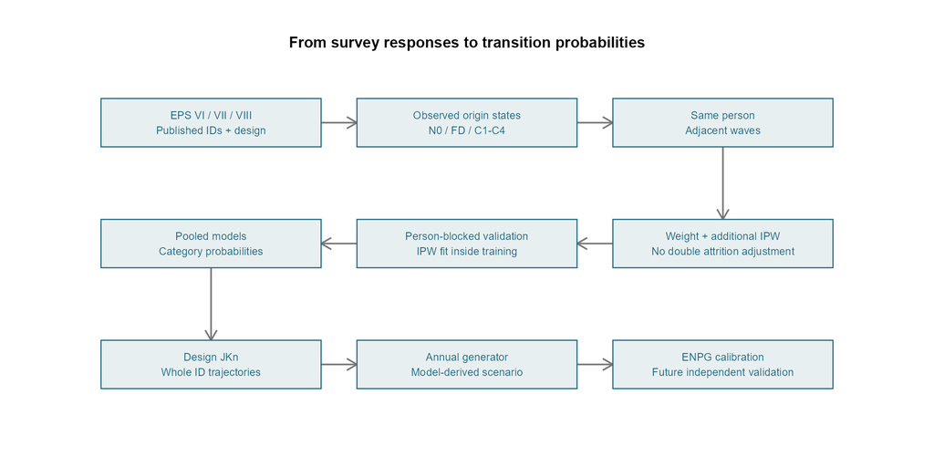

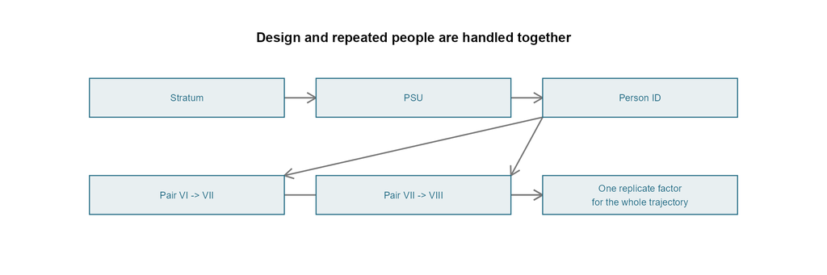

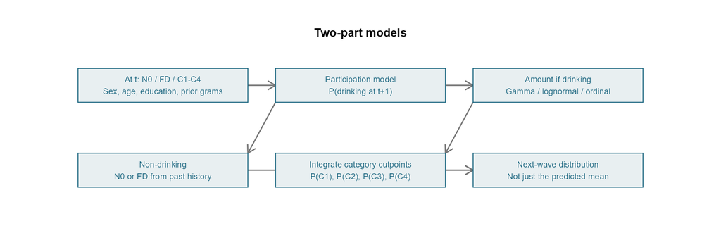

```
Elapsed: 0.05 minutes
```

```r
.t0 <- Sys.time()
ep_load()
ep_W <- ep_waves(12)
ep_risk <- ep_make_risk(ep_W)
ep_period_mass <- vapply(ep_periods,function(p) sum(ep_risk$period==p & ep_risk$complete),1)
names(ep_period_mass) <- ep_periods
ep_des <- ep_design()
ep_ip <- ep_ipw_fit(ep_risk)
ep_d <- ep_ipw_apply(ep_risk,ep_ip)
ep_check(nrow(ep_d)==length(unique(ep_d$row_id)),"One row per person and interval")
ep_check(all(ep_d$wn>0) && all(is.finite(ep_d$wn)),"Positive finite main weights")
ep_check(sum(ep_risk$longterm0)==0,"No fabricated strict long-term origin states")
ep_check(!any(ep_d$state0!="N0" & ep_d$state1=="N0") && !any(ep_d$state0=="N0" & ep_d$state1=="FD"),
 "Observed pairs respect the history-state transition map")
ep_counts <- as.data.frame(table(period=ep_d$period, sex=ep_d$sex, age_group=ep_d$age_group, state0=ep_d$state0))
names(ep_counts)[5] <- "n"
ep_save(ep_counts,"row_counts_state0_by_stratum")
ep_cohort <- do.call(rbind,lapply(ep_periods,function(p) {
 r<-ep_risk[ep_risk$period==p,]; d<-ep_d[ep_d$period==p,]
 data.frame(period=p, risk_set=nrow(r), usable_pairs=nrow(d), persons=length(unique(d$id)),
   age_min=min(d$age), age_max=max(d$age), weight_ESS=sum(d$wn)^2/sum(d$wn^2),
   main_weight=if(p=="VI_VII") "Official longitudinal + item/link-validity IPW" else "VII cross-sectional + follow-up/item IPW")
}))
ep_history_audit <- do.call(rbind,lapply(split(ep_W,ep_W$wave),function(d)
 data.frame(wave=d$wave[1], N0=sum(d$state=="N0",na.rm=TRUE), FD=sum(d$state=="FD",na.rm=TRUE),
  longterm_strict=sum(d$longterm), two_negative_proxy=sum(d$two_wave_negative))))
ep_design_audit <- data.frame(master_persons=nrow(ep_des$master),PSUs=length(unique(ep_des$master$psu)),
 strata=length(unique(ep_des$master$strata)), singleton_strata=sum(table(unique(ep_des$master[c("psu","strata")])$strata)==1),
 JKn_replicates=ncol(ep_des$multipliers), original_df=survey::degf(ep_des$survey), replicate_df=survey::degf(ep_des$replicate),
 known_VIII_deaths=sum(ep_W$wave=="VII_presencial" & ep_W$id %in% ep_dead8))
ep_save(ep_cohort,"cohort"); ep_save(ep_history_audit,"abstention_history_audit"); ep_save(ep_design_audit,"design_audit")
ep_save(as.data.frame(table(origin=ep_d$state0)),"origin_counts")
ep_show(ep_cohort,"Adjacent-wave analysis populations","Poblaciones de los pares consecutivos")
ep_show(data.frame(pairs=nrow(ep_d), persons=length(unique(ep_d$id)), persons_with_two_pairs=sum(table(ep_d$id)==2)),
 "Pairs and distinct people","Pares y personas distintas")
ep_show(ep_history_audit,"Past-only history flags; all available ages","Historia hasta cada entrevista; todas las edades disponibles")
ep_diagrams()
cat(sprintf("Elapsed: %.2f minutes\n", as.numeric(difftime(Sys.time(), .t0, units = "mins"))))
```

## Weights, IPW and sampling design

**VI→VII:** the official longitudinal weight already adjusts participation. Additional IPW addresses only missing baseline/final classification and incompatible analytical links. **VII→VIII:** no pair-specific official longitudinal weight is available; VII cross-sectional weights are combined with follow-up/item-response IPW. Known VIII deaths are excluded. Survival is not completely observed among those lost to follow-up.

The pooled mixture fixes each period’s relative contribution at its initial observed-pair count. This is an analytical mixture of two weighted populations, not a single national annual cohort. Observation probabilities have a 0.02 floor and completed weights are clipped at the 1st/99th percentiles. Thresholds are learned in training and applied to held-out data.

**Primary uncertainty:** stratified JKn using `cluster_ID` and `strata_ID`. Each replicate deletes/reweights a PSU, keeps all pairs of each ID together, and refits IPW and outcome models. Singleton strata use `survey.lonely.psu="adjust"`; their PSUs are not asserted to have certainty inclusion. The EPS report’s `certainty` convention is a sensitivity.

JKn intervals use `survey` replication scales, centre on the full estimate and use a t reference with PSU-minus-strata degrees of freedom. **They are not bootstrap percentiles.** Probability intervals use a logit transformation; exact 0/1 boundaries use bounded normal limits. A **bootstrap with 1,000 replicates of complete person trajectories** is retained as a sensitivity, with IPW refitted. No second ID correction is added on top of JKn. A Markov assumption does not make one person’s overlapping pairs independent.

This uses the published design but does not reconstruct stage-specific inclusion probabilities, FPCs or uncertainty in the official weights themselves. Kish ESS describes weight dispersion only; it does not multiply the confidence intervals.

**Show R code**

```r
.t0 <- Sys.time()
ep_show(ep_design_audit,"Published design and replication","Diseño publicado y replicación")
ep_weight_audit <- do.call(rbind,lapply(split(ep_d,ep_d$period),function(d)
 data.frame(period=d$period[1], min_probability=min(d$p_obs),median_weight=stats::median(d$wn),max_weight=max(d$wn),
 clipped=sum(d$untrimmed!=d$wcorrected), weight_ESS=sum(d$wn)^2/sum(d$wn^2))))
ep_save(ep_weight_audit,"ipw_audit")
ep_singleton <- ep_taylor_sensitivity(); ep_save(ep_singleton,"singleton_convention_sensitivity")
ep_show(ep_weight_audit,"Weight diagnostics; ESS does not include clustering","Diagnóstico de pesos; ESS no incorpora conglomerados")
ep_show(ep_singleton,"Singleton sensitivity, descriptive fixed-IPW prevalence","Sensibilidad de estratos con una UPM; prevalencia con IPW fijo")
cat(sprintf("Elapsed: %.2f minutes\n", as.numeric(difftime(Sys.time(), .t0, units = "mins"))))
```

Published design and replication

| master_persons | PSUs | strata | singleton_strata | JKn_replicates | original_df | replicate_df | known_VIII_deaths |
| --- | --- | --- | --- | --- | --- | --- | --- |
| 7800 | 111 | 33 | 32 | 111 | 78 | 110 | 237 |

Weight diagnostics; ESS does not include clustering

| period | min_probability | median_weight | max_weight | clipped | weight_ESS |
| --- | --- | --- | --- | --- | --- |
| VI_VII | 0.429 | 0.817 | 4.451 | 94 | 3153.580 |
| VII_VIII | 0.125 | 0.753 | 5.423 | 66 | 1932.492 |

Singleton sensitivity, descriptive fixed-IPW prevalence

| singleton | weighted_current_destination | se_fixed_IPW | note |
| --- | --- | --- | --- |
| adjust | 0.393 | 0.011 | Descriptive fixed-IPW sensitivity; official certainty is a convention |
| certainty | 0.393 | 0.010 | Descriptive fixed-IPW sensitivity; official certainty is a convention |

```
Elapsed: 0.00 minutes
```

## Models and fair comparison

**NC means current non-consumption: N0+FD.** Destination quantity is modelled in five categories, NC and C1–C4. Origin history then distinguishes N0 from FD among non-drinkers, yielding six-state matrices.

Matrices A provide the empirical reference with shrinkage: small cells borrow information from broader groups. Shrinkage strength is selected **inside training**. An education-stratified version is compared rather than assumed.

Gamma, lognormal, multinomial and ordinal models receive the same information: previous state and grams, sex, age, sex×age interaction, period and education. Two-part models share the participation equation. JRT is a **separate reference specification**, not a pure distribution-family comparison.

Gamma/lognormal predict a positive amount distribution. C1–C4 probabilities are obtained **by integrating between cutpoints**, not by classifying only the predicted mean. Dispersion uses normalized weights: multiplying weights by ten must leave predictions unchanged.

**Education:** compare no education, an ordinal effect, and its interactions with baseline drinking, sex and age. Coding 0/1/2 assumes equally spaced levels; it does not represent years of schooling. Missing education has a separate indicator. A multinomial amount model compares the ordinal with an option without proportional odds through held-out prediction, without a spurious composite-likelihood p-value.

Parametric models share information and support smooth extrapolation. This can help with C3/C4, but precision depends on the model’s shape assumptions: **it does not create tail observations**. Multinomial regression is also parametric. Gamma/lognormal use continuous quantity and restrict its distribution; they can reduce variability at the cost of bias when that shape is incorrect. Greater efficiency is not automatic.

**Show R code**

```r
.t0 <- Sys.time()
ep_tunes <- list(ep_tune(ep_risk,FALSE),ep_tune(ep_risk,TRUE))
ep_k <- vapply(ep_tunes,function(x) x$k,1)
ep_save(rbind(ep_tunes[[1]]$scores,ep_tunes[[2]]$scores),"full_fit_shrinkage_tuning")
ep_fits <- lapply(stats::setNames(names(ep_models),names(ep_models)),function(nm) ep_fit(ep_d,nm,ep_k[if(nm=="A_education") 2 else 1]))
ep_scale_test <- lapply(c("Gamma","Lognormal","Multinomial","Ordinal_two_part"),function(nm) {
 d<-ep_d; d$wn<-10*d$wn
 diff<-max(abs(ep_prob(ep_fits[[nm]],ep_d)-ep_prob(ep_fit(d,nm,ep_k[1]),ep_d)))
 ep_check(diff<1e-7,paste("Weight-scale invariance",nm))
 data.frame(model=nm,max_absolute_difference=diff)
})
ep_save(do.call(rbind,ep_scale_test),"weight_scale_invariance")
ep_cv_result <- ep_cv(ep_risk)
ep_cvtab <- ep_cv_tables(ep_cv_result)
ep_contrasts <- ep_score_contrasts(ep_cvtab)
ep_save(ep_cv_result$audit,"CV_fold_audit"); ep_save(ep_cv_result$tuning,"CV_inner_tuning")
ep_save(ep_cvtab$scores,"CV_repeated_scores"); ep_save(ep_cvtab$summary,"cv_scores")
ep_save(ep_contrasts,"CV_paired_comparisons")
ep_show(ep_cvtab$summary,"Held-out category scores; lower log loss/Brier is better","Puntajes de categorías fuera de muestra; menor log loss/Brier es mejor",5)
ep_show(ep_contrasts[,1:8],"Paired comparisons; uncertainty uses PSU and strata","Comparaciones pareadas; incertidumbre con UPM y estratos",5)
cat(sprintf("Elapsed: %.2f minutes\n", as.numeric(difftime(Sys.time(), .t0, units = "mins"))))
```

```
CV repeat 1/3, fold 1/5 complete
CV repeat 1/3, fold 2/5 complete
CV repeat 1/3, fold 3/5 complete
CV repeat 1/3, fold 4/5 complete
CV repeat 1/3, fold 5/5 complete
CV repeat 2/3, fold 1/5 complete
CV repeat 2/3, fold 2/5 complete
CV repeat 2/3, fold 3/5 complete
CV repeat 2/3, fold 4/5 complete
CV repeat 2/3, fold 5/5 complete
CV repeat 3/3, fold 1/5 complete
CV repeat 3/3, fold 2/5 complete
CV repeat 3/3, fold 3/5 complete
CV repeat 3/3, fold 4/5 complete
CV repeat 3/3, fold 5/5 complete
```

Held-out category scores; lower log loss/Brier is better

| model | logloss | brier | accuracy |
| --- | --- | --- | --- |
| Lognormal | 0.70664 | 0.41663 | 0.69454 |
| Lognormal_education_interaction | 0.70729 | 0.41669 | 0.69408 |
| Ordinal_single | 0.70882 | 0.41685 | 0.69460 |
| NonPO_two_part | 0.70943 | 0.41700 | 0.69394 |
| Multinomial | 0.70952 | 0.41707 | 0.69344 |
| Ordinal_two_part | 0.71126 | 0.41699 | 0.69381 |
| A | 0.71605 | 0.42156 | 0.69237 |
| A_education | 0.71720 | 0.42188 | 0.69438 |
| Gamma | 0.71866 | 0.41679 | 0.69435 |
| Gamma_no_education | 0.71992 | 0.41762 | 0.69515 |
| Gamma_education_interaction | 0.72033 | 0.41688 | 0.69384 |
| JRT_reference | 0.72310 | 0.42224 | 0.68997 |

Paired comparisons; uncertainty uses PSU and strata

| model | reference | difference | se_design | lower | upper | relative_geometric_probability_gain_pct | mean_absolute_class_probability_change_pp |
| --- | --- | --- | --- | --- | --- | --- | --- |
| Lognormal | Gamma | -0.01203 | 0.00344 | -0.01889 | -0.00517 | 1.21013 | 0.35211 |
| Gamma | A | 0.00262 | 0.00527 | -0.00788 | 0.01311 | -0.26119 | 2.12367 |
| Lognormal | A | -0.00941 | 0.00302 | -0.01542 | -0.00341 | 0.94577 | 2.07075 |
| NonPO_two_part | Ordinal_two_part | -0.00182 | 0.00274 | -0.00727 | 0.00363 | 0.18246 | 0.28949 |
| Ordinal_two_part | Gamma | -0.00741 | 0.00506 | -0.01748 | 0.00266 | 0.74373 | 0.38596 |
| Ordinal_single | Gamma | -0.00984 | 0.00479 | -0.01938 | -0.00030 | 0.98899 | 0.82632 |
| Multinomial | Gamma | -0.00914 | 0.00415 | -0.01741 | -0.00087 | 0.91829 | 0.50147 |
| A_education | A | 0.00115 | 0.00096 | -0.00077 | 0.00307 | -0.11491 | 0.62142 |
| Gamma | Gamma_no_education | -0.00125 | 0.00109 | -0.00342 | 0.00092 | 0.12521 | 0.83684 |
| Gamma_education_interaction | Gamma | 0.00166 | 0.00109 | -0.00051 | 0.00383 | -0.16593 | 0.58470 |
| Lognormal_education_interaction | Lognormal | 0.00065 | 0.00089 | -0.00112 | 0.00243 | -0.06545 | 0.57181 |

```
Elapsed: 1.62 minutes
```

## Which model wins, and by how much?

The preceding table is recomputed: **the old version’s ranking is not retained**. Validation uses five person-blocked folds, three repeated partitions, and IPW learned without the held-out people. Matrix A selects shrinkage in three inner folds.

Paired log loss is model minus reference: negative favours the first model. If the interval crosses zero, this evaluation does not clearly distinguish their scores. The relative change in geometric probability assigned to observed categories and mean change in class probabilities, in percentage points, quantify the size of small score differences. No clinical equivalence margin is invented.

Score intervals use PSU/strata but are **conditional on already-trained predictions**. Three repetitions show partition sensitivity, not three independent studies. Decisions should consider calibration and tails as well as overall scores.

The lowest average score identifies the leading candidate in this comparison. It does not establish superiority over every competitor: the reported paired contrasts do not cover every model pair. A detectable advantage over Gamma can still be small in practical terms.

**Show R code**

```r
.t0 <- Sys.time()
ep_cal <- do.call(rbind,lapply(c("A","Gamma","Lognormal","Ordinal_two_part"),function(nm) {
 P<-ep_cvtab$prob[[nm]]
 data.frame(model=nm,category=ep_Y,
  observed=vapply(ep_Y,function(s) stats::weighted.mean(ep_d$y1==s,ep_cvtab$w),1),
  predicted=colSums(P*ep_cvtab$w)/sum(ep_cvtab$w))
}))
ep_save(ep_cal,"calibration_destination")
ep_show(ep_cal,"Held-out observed and predicted shares","Proporciones observadas y predichas fuera de muestra",4)
ep_model_answer <- data.frame(best_logloss=ep_cvtab$summary$model[1],
 best_brier=ep_cvtab$summary$model[which.min(ep_cvtab$summary$brier)],
 lognormal_minus_gamma=ep_contrasts$difference[1],lower=ep_contrasts$lower[1],upper=ep_contrasts$upper[1],
 clear_gamma_lognormal_separation=ep_contrasts$lower[1]>0 | ep_contrasts$upper[1]<0)
ep_save(ep_model_answer,"model_decision_summary"); ep_show(ep_model_answer,"Current result, not a predetermined winner","Resultado actual, sin ganador predeterminado",5)
cat(sprintf("Elapsed: %.2f minutes\n", as.numeric(difftime(Sys.time(), .t0, units = "mins"))))
```

Held-out observed and predicted shares

| model | category | observed | predicted |
| --- | --- | --- | --- |
| A | NC | 0.6065 | 0.6035 |
| A | C1 | 0.3604 | 0.3628 |
| A | C2 | 0.0187 | 0.0189 |
| A | C3 | 0.0096 | 0.0098 |
| A | C4 | 0.0048 | 0.0049 |
| Gamma | NC | 0.6065 | 0.6063 |
| Gamma | C1 | 0.3604 | 0.3628 |
| Gamma | C2 | 0.0187 | 0.0227 |
| Gamma | C3 | 0.0096 | 0.0070 |
| Gamma | C4 | 0.0048 | 0.0012 |
| Lognormal | NC | 0.6065 | 0.6063 |
| Lognormal | C1 | 0.3604 | 0.3649 |
| Lognormal | C2 | 0.0187 | 0.0179 |
| Lognormal | C3 | 0.0096 | 0.0073 |
| Lognormal | C4 | 0.0048 | 0.0035 |
| Ordinal_two_part | NC | 0.6065 | 0.6063 |
| Ordinal_two_part | C1 | 0.3604 | 0.3606 |
| Ordinal_two_part | C2 | 0.0187 | 0.0187 |
| Ordinal_two_part | C3 | 0.0096 | 0.0096 |
| Ordinal_two_part | C4 | 0.0048 | 0.0048 |

Current result, not a predetermined winner

| best_logloss | best_brier | lognormal_minus_gamma | lower | upper | clear_gamma_lognormal_separation |
| --- | --- | --- | --- | --- | --- |
| Lognormal | Lognormal | -0.01203 | -0.01889 | -0.00517 | TRUE |

```
Elapsed: 0.00 minutes
```

## Matrices, confidence intervals and exported parameters

Each row averages predictions **among people actually observed in that origin**, retaining their previous grams and education. Previous quantity is no longer replaced by a synthetic median. Rows without people are NA; structural impossibility is distinct from an unobserved row.

JKn refits outcome models and IPW. Selected shrinkage and model family remain fixed, so intervals are conditional on those choices. If an origin disappears in a replicate, it is reported without fabricating an interval. Gamma/lognormal coefficient SEs use replication rather than ordinary `summary(glm)` output.

**Show R code**

```r
.t0 <- Sys.time()
ep_points <- ep_targets(ep_d,ep_fits[ep_main_models])
ep_pool_tab <- do.call(rbind,lapply(c("A","Gamma","Lognormal"),function(nm) {
 d<-ep_d; d$pooled<-"All"
 ep_matrices(d,ep_prob(ep_fits[[nm]],d),nm,by="pooled")
}))
ep_jk <- ep_jackknife()
ep_jkmat <- do.call(rbind,lapply(ep_jk,function(x) x$target[names(ep_vector(ep_points))]))
ep_ci <- cbind(ep_points,ep_interval(ep_vector(ep_points),ep_jkmat))
ep_save(ep_ci,"transition_matrices_design_CI")
ep_engine <- ep_coef(ep_fits)
ep_coef_names <- paste(ep_engine$model,ep_engine$component,ep_engine$term,sep="::")
ep_engine <- cbind(ep_engine,ep_interval(ep_engine$estimate,do.call(rbind,lapply(ep_jk,function(x) x$coefficients[ep_coef_names])),probability=FALSE))
ep_save(ep_engine,"engine_coefficients_design_CI")
ep_show(ep_ci[ep_ci$model=="Gamma" & ep_ci$from=="C1" & ep_ci$to=="C1",c("period","sex","age_group","n_origin","estimate","lower","upper")],
 "Example: remaining in C1, Gamma model","Ejemplo: permanecer en C1, modelo Gamma")
ep_person <- ep_bootstrap_person()
ep_personmat <- do.call(rbind,lapply(ep_person,function(x) x$target))
ep_perpoint <- ep_points[ep_points$model %in% c("Gamma","Lognormal"),]
ep_person_ci <- cbind(ep_perpoint,ep_interval(ep_vector(ep_perpoint),ep_personmat,"person"))
ep_save(ep_person_ci,"transition_matrices_person_CI")
ep_mc <- do.call(rbind,lapply(c(100,250,500,1000),function(B) {
 s<-apply(ep_personmat[seq_len(B),,drop=FALSE],2,stats::sd)
 ref<-apply(ep_personmat,2,stats::sd); good<-is.finite(s)&is.finite(ref)&ref>0
 data.frame(replicates=B,median_SE_ratio_to_1000=stats::median(s[good]/ref[good]),
  p90_absolute_relative_difference=as.numeric(stats::quantile(abs(s[good]/ref[good]-1),.9)))
}))
ep_save(ep_mc,"bootstrap_stability"); ep_show(ep_mc,"Bootstrap stability; 1,000 whole-person replicas","Estabilidad del bootstrap; 1.000 réplicas por persona")
cat(sprintf("Elapsed: %.2f minutes\n", as.numeric(difftime(Sys.time(), .t0, units = "mins"))))
```

```
EPS design JKn 10/111
EPS design JKn 20/111
EPS design JKn 30/111
EPS design JKn 40/111
EPS design JKn 50/111
EPS design JKn 60/111
EPS design JKn 70/111
EPS design JKn 80/111
EPS design JKn 90/111
EPS design JKn 100/111
EPS design JKn 110/111
EPS design JKn 111/111
```

Example: remaining in C1, Gamma model

| period | sex | age_group | n_origin | estimate | lower | upper |
| --- | --- | --- | --- | --- | --- | --- |
| VI_VII | Men | 18-29 | 428 | 0.671 | 0.621 | 0.717 |
| VI_VII | Men | 30-44 | 165 | 0.665 | 0.605 | 0.720 |
| VI_VII | Men | 45-59 | 259 | 0.615 | 0.560 | 0.668 |
| VI_VII | Men | 60-65 | 92 | 0.601 | 0.506 | 0.689 |
| VI_VII | Women | 18-29 | 310 | 0.545 | 0.500 | 0.589 |
| VI_VII | Women | 30-44 | 127 | 0.471 | 0.406 | 0.537 |
| VI_VII | Women | 45-59 | 195 | 0.400 | 0.345 | 0.457 |
| VI_VII | Women | 60-65 | 61 | 0.410 | 0.337 | 0.487 |
| VII_VIII | Men | 18-29 | 150 | 0.626 | 0.566 | 0.683 |
| VII_VIII | Men | 30-44 | 137 | 0.603 | 0.547 | 0.657 |
| VII_VIII | Men | 45-59 | 207 | 0.539 | 0.485 | 0.592 |
| VII_VIII | Men | 60-65 | 104 | 0.522 | 0.450 | 0.593 |
| VII_VIII | Women | 18-29 | 177 | 0.487 | 0.437 | 0.536 |
| VII_VIII | Women | 30-44 | 144 | 0.401 | 0.339 | 0.466 |
| VII_VIII | Women | 45-59 | 203 | 0.327 | 0.285 | 0.372 |
| VII_VIII | Women | 60-65 | 63 | 0.316 | 0.255 | 0.383 |

```
Person bootstrap 100/1000; IPW refitted
Person bootstrap 200/1000; IPW refitted
Person bootstrap 300/1000; IPW refitted
Person bootstrap 400/1000; IPW refitted
Person bootstrap 500/1000; IPW refitted
Person bootstrap 600/1000; IPW refitted
Person bootstrap 700/1000; IPW refitted
Person bootstrap 800/1000; IPW refitted
Person bootstrap 900/1000; IPW refitted
Person bootstrap 1000/1000; IPW refitted
```

Bootstrap stability; 1,000 whole-person replicas

| replicates | median_SE_ratio_to_1000 | p90_absolute_relative_difference |
| --- | --- | --- |
| 100 | 0.985 | 0.143 |
| 250 | 0.987 | 0.076 |
| 500 | 0.999 | 0.054 |
| 1000 | 1.000 | 0.000 |

```
Elapsed: 18.90 minutes
```

## Transport, earlier history and rank matching

Both **period directions** are evaluated while always predicting forward within a pair: train VI→VII/test VII→VIII, and train VII→VIII/test VI→VII. All test persons are excluded from training; ages are restricted to common support 23–65; unsupported FD origins are reported. FD is never silently recoded to N0.

**Alcohol validation in V/2012 is not feasible with the delivered files.** Its 21 databases contain no alcohol variables/labels; the supplied RAR contains documentation, not additional alcohol variables. The official dossier (p. 23) also advises against statistical inference with that round. Reconstructing V would be an unvalidated scenario rather than observed reverse-period transport.

The history analysis compares models adjusted for current state and grams, sex, age and education, **with and without VI history**. It is repeated with education interactions and restricted to complete three-wave histories. Chapman–Kolmogorov is a marginal composition diagnostic without a formal “Markov rejection” p-value.

To isolate rank matching, the benchmark uses **the same people, weights, baseline groups and endpoint margins** as the observed panel. Only individual association is replaced by rank coupling. Persistence can increase by construction even when margins match exactly.

**Show R code**

```r
.t0 <- Sys.time()
ep_trans <- ep_transport(); ep_save(ep_trans$scores,"transport_scores");ep_save(ep_trans$coverage,"transport_support")
ep_transport_summary <- do.call(rbind,lapply(split(ep_trans$scores,paste(ep_trans$scores$direction,ep_trans$scores$model)),function(z)
 data.frame(direction=z$direction[1],model=z$model[1],logloss=stats::weighted.mean(z$logloss,z$weight_sum),
  brier=stats::weighted.mean(z$brier,z$weight_sum),n=sum(z$n))))
ep_save(ep_transport_summary,"transport_summary")
ep_show(ep_transport_summary,
 "Person-disjoint forward and reverse-period transport","Transporte y retrotransporte sin compartir personas",4)
ep_hist <- ep_history_check(); ep_save(ep_hist,"adjusted_history_validation")
ep_show(ep_hist,"Does earlier history add predictive information after adjustment?","¿La historia anterior aporta información después del ajuste?",5)
ep_ck_tab <- ep_ck();ep_save(ep_ck_tab,"chapman_kolmogorov_descriptive")
ep_rank_tab <- ep_rank(ep_d);ep_save(ep_rank_tab,"rank_matching_vs_panel")
ep_show(ep_rank_tab[ep_rank_tab$from=="C1" & ep_rank_tab$to=="C1",],
 "C1 persistence: matched margins, different dependence","Permanencia en C1: mismas marginales, distinta dependencia",3)
cat(sprintf("Elapsed: %.2f minutes\n", as.numeric(difftime(Sys.time(), .t0, units = "mins"))))
```

Person-disjoint forward and reverse-period transport

| direction | model | logloss | brier | n |
| --- | --- | --- | --- | --- |
| forward | A | 0.6713 | 0.3960 | 2943 |
| forward | Gamma | 0.6736 | 0.3975 | 2943 |
| forward | JRT_reference | 0.6728 | 0.3986 | 2943 |
| forward | Lognormal | 0.6619 | 0.3971 | 2943 |
| forward | Multinomial | 0.6697 | 0.3976 | 2943 |
| forward | Ordinal_single | 0.6643 | 0.3960 | 2943 |
| forward | Ordinal_two_part | 0.6899 | 0.3972 | 2943 |
| retro | A | 0.7956 | 0.4460 | 3908 |
| retro | Gamma | 0.8484 | 0.4459 | 3908 |
| retro | JRT_reference | 0.7889 | 0.4485 | 3908 |
| retro | Lognormal | 0.7955 | 0.4460 | 3908 |
| retro | Multinomial | 0.7763 | 0.4455 | 3908 |
| retro | Ordinal_single | 0.7903 | 0.4473 | 3908 |
| retro | Ordinal_two_part | 0.8256 | 0.4466 | 3908 |

Does earlier history add predictive information after adjustment?

| model | n_persons | difference_history_minus_current | lower | upper | population |
| --- | --- | --- | --- | --- | --- |
| Gamma | 2730 | 0.00464 | -0.00444 | 0.01372 | complete three-wave histories; conditional OOF comparison |
| Gamma_education_interaction | 2730 | 0.00405 | -0.00494 | 0.01305 | complete three-wave histories; conditional OOF comparison |

C1 persistence: matched margins, different dependence

| period | source | from | to | probability |
| --- | --- | --- | --- | --- |
| VI_VII | Observed_panel | C1 | C1 | 0.583 |
| VI_VII | Rank_matching | C1 | C1 | 0.940 |
| VII_VIII | Observed_panel | C1 | C1 | 0.523 |
| VII_VIII | Rank_matching | C1 | C1 | 0.774 |

```
Elapsed: 0.28 minutes
```

## Annual probabilities: an additional modelling layer

A common continuous-time generator is fitted to both intervals, with nonnegative off-diagonal rates:

$$P(\Delta)=\exp(Q\Delta),\qquad P(1)=\exp(Q).$$

Time-homogeneous rates are an assumption. Annualization does not turn an observed four-year interval into observed one-year transitions. Starting values and penalties are compared; row sums and composition under the same generator are checked. Annual estimates are **pooled**, without claiming separate age/sex generators are identified for C4. Confidence intervals refit the generator in each JKn replicate, conditional on its fixed penalty.

These matrices are candidates for ENPG calibration. A simulation that changes covariates or rates with age needs additional trajectory validation; the matrix identity checked here does not validate that full engine.

**Stability:** the sensitivity table compares the primary fit with multiple restarts and penalties. Nearly equal objectives can yield different annual probabilities. Intervals condition on the primary initialization and penalty and do not cover this entire ambiguity. The opening summary reports its observed magnitude. Large differences keep this layer exploratory, with between-wave probabilities remaining the primary result.

**Observed and latent history:** annual fitting compares N0+FD with the observed non-drinking destination. It can represent an unobserved N0→drinking→FD path between interviews. Annual FD therefore includes model-imputed drinking history, whereas survey-wave FD requires observed previous drinking. This distinction depends on assumptions and is not identified by the collapsed destinations.

**Show R code**

```r
.t0 <- Sys.time()
ep_annual_full <- lapply(ep_fits[c("A","Gamma","Lognormal")],function(f) ep_annual(ep_d,f,starts=.05,check_gradient=TRUE))
ep_ann_point <- unlist(lapply(ep_annual_full,function(x) as.vector(x$P)))
ep_ann_rep <- do.call(rbind,lapply(ep_jk,function(x) x$annual))
ep_ann <- do.call(rbind,lapply(names(ep_annual_full),function(nm) {
 z<-ep_annual_full[[nm]]
 ep_check(max(abs(rowSums(z$P)-1))<1e-8 && min(z$P)>-1e-10,paste("Annual stochastic matrix",nm))
 ep_check(z$semigroup_error<1e-8,paste("Annual semigroup",nm))
 data.frame(model=nm,from=rep(ep_ST,6),to=rep(ep_ST,each=6),estimate=as.vector(z$P),
  weighted_reconstruction_RMSE=z$rmse,optimizer_code=z$convergence,semigroup_error=z$semigroup_error)
}))
ep_ann <- cbind(ep_ann,ep_interval(ep_ann_point,ep_ann_rep))
ep_save(ep_ann,"annual_pooled_matrices_design_CI")
ep_ann_sens <- do.call(rbind,lapply(c(1e-5,5e-5,2e-4),function(pen) {
 z<-ep_annual(ep_d,ep_fits$Gamma,lambda=pen)
 data.frame(penalty=pen,weighted_reconstruction_RMSE=z$rmse,
  start_objective_range=z$start_objective_range,max_annual_difference=max(abs(z$P-ep_annual_full$Gamma$P)),
  optimizer_code=z$convergence)
}))
ep_save(ep_ann_sens,"annual_generator_sensitivity")
ep_show(ep_ann[ep_ann$model=="Gamma" & ep_ann$from==ep_ann$to,],
 "Annual staying probabilities: model-derived, pooled Gamma","Permanencia anual: resultado modelado, Gamma agrupado")
ep_show(ep_ann_sens,"Annual reconstruction sensitivity","Sensibilidad de reconstrucción anual",5)
cat(sprintf("Elapsed: %.2f minutes\n", as.numeric(difftime(Sys.time(), .t0, units = "mins"))))
```

Annual staying probabilities: model-derived, pooled Gamma

| model | from | to | estimate | weighted_reconstruction_RMSE | optimizer_code | semigroup_error | se | lower | upper | valid_replicates | interval_status |
| --- | --- | --- | --- | --- | --- | --- | --- | --- | --- | --- | --- |
| Gamma | N0 | N0 | 0.911 | 0.063 | 0 | 0 | 0.005 | 0.901 | 0.921 | 111 | available |
| Gamma | FD | FD | 0.871 | 0.063 | 0 | 0 | 0.020 | 0.827 | 0.905 | 111 | available |
| Gamma | C1 | C1 | 0.811 | 0.063 | 0 | 0 | 0.012 | 0.786 | 0.834 | 111 | available |
| Gamma | C2 | C2 | 0.519 | 0.063 | 0 | 0 | 0.049 | 0.421 | 0.615 | 111 | available |
| Gamma | C3 | C3 | 0.420 | 0.063 | 0 | 0 | 0.091 | 0.257 | 0.604 | 111 | available |
| Gamma | C4 | C4 | 0.089 | 0.063 | 0 | 0 | 0.862 | 0.000 | 1.000 | 111 | available |

Annual reconstruction sensitivity

| penalty | weighted_reconstruction_RMSE | start_objective_range | max_annual_difference | optimizer_code |
| --- | --- | --- | --- | --- |
| 0.00001 | 0.06276 | 0.00002 | 0.27896 | 0 |
| 0.00005 | 0.06322 | 0.00000 | 0.07927 | 0 |
| 0.00020 | 0.06404 | 0.00000 | 0.03928 | 0 |

```
Elapsed: 0.04 minutes
```

## Conversion, alternative weights and high typical quantity

Gamma and lognormal are refitted at 12 and 15.7 g/drink. Their difference measures classification sensitivity; it does not validate drink size on its own. Base weights are also compared with IPW-corrected weights, retaining VI→VII’s longitudinal-weight purpose; the VI–VII–VIII weight is not treated as pair-specific VII→VIII weighting.

The typical-quantity signal **≥5 drinks for men / ≥4 for women**, in any beverage, remains separate. It is not observed ENPG 30-day HED. Missing beverage quantity is not treated as absence of the signal. Its regression uses EPS design, although descriptive intervals condition on estimated IPW; it is not a main volume predictor or an export of validated HED.

**Show R code**

Conversion sensitivity, refitted models

| grams_per_drink | model | quantity | probability |
| --- | --- | --- | --- |
| 12.0 | Gamma | Drinking_t1 | 0.3932 |
| 12.0 | Gamma | Escalation_from_C1 | 0.0550 |
| 12.0 | Gamma | C3_C4_t1 | 0.0081 |
| 12.0 | Lognormal | Drinking_t1 | 0.3932 |
| 12.0 | Lognormal | Escalation_from_C1 | 0.0498 |
| 12.0 | Lognormal | C3_C4_t1 | 0.0108 |
| 15.7 | Gamma | Drinking_t1 | 0.3932 |
| 15.7 | Gamma | Escalation_from_C1 | 0.0893 |
| 15.7 | Gamma | C3_C4_t1 | 0.0179 |
| 15.7 | Lognormal | Drinking_t1 | 0.3932 |
| 15.7 | Lognormal | Escalation_from_C1 | 0.0728 |
| 15.7 | Lognormal | C3_C4_t1 | 0.0188 |

Refitted weight sensitivity

| scenario | current_t1 | C3_C4_t1 |
| --- | --- | --- |
| base_only | 0.3870 | 0.0076 |
| base_plus_IPW | 0.3932 | 0.0081 |

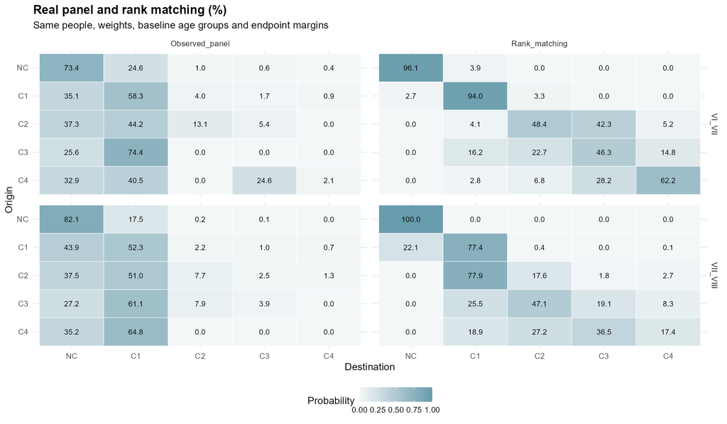

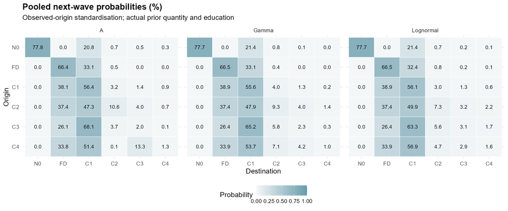

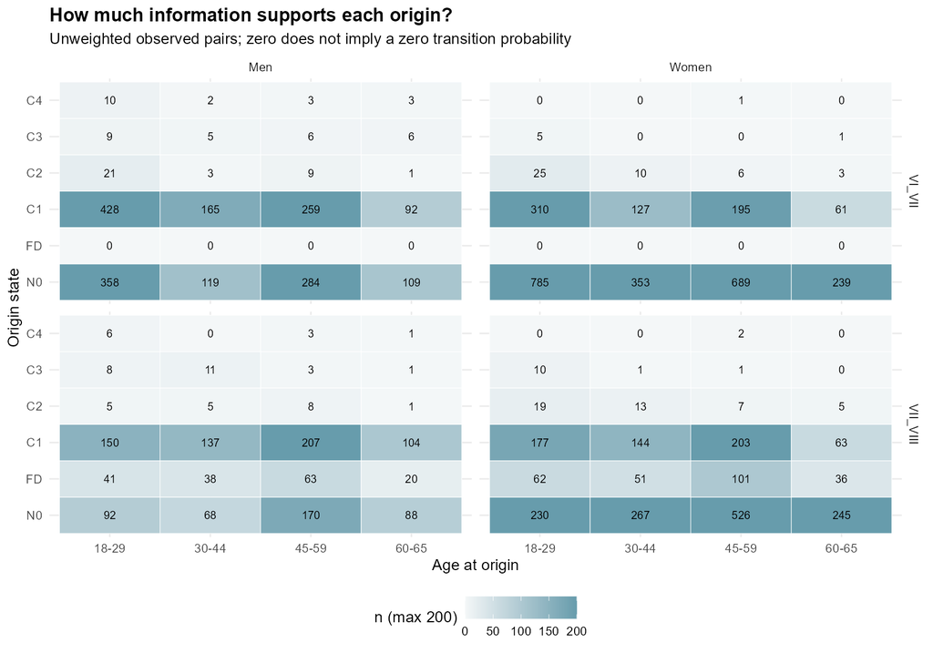

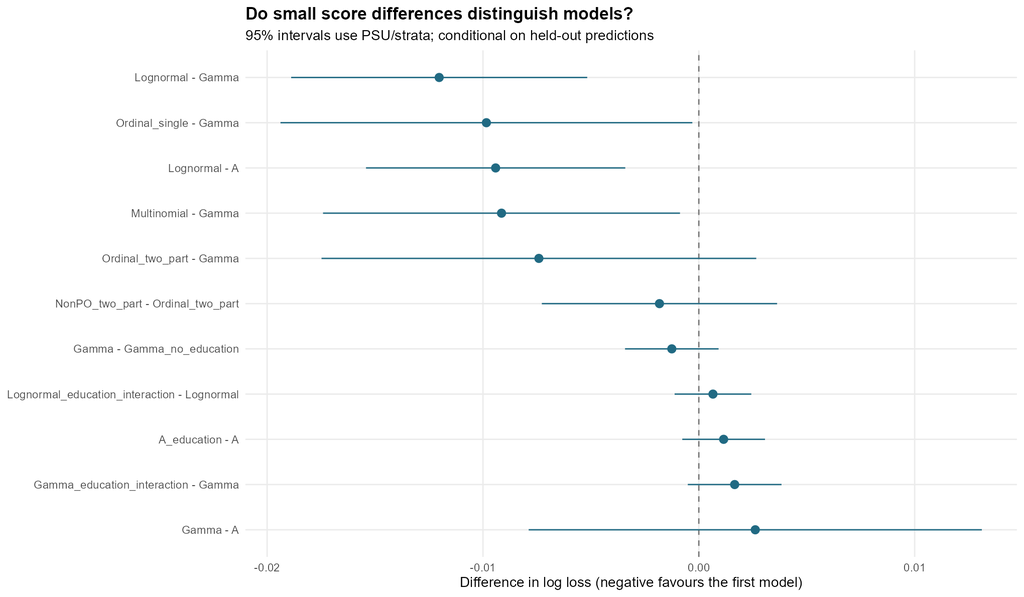

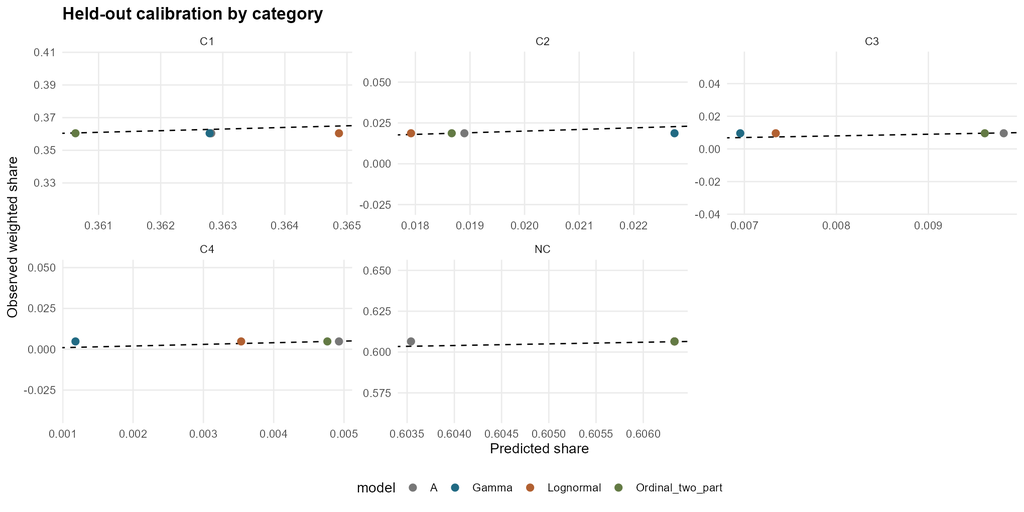

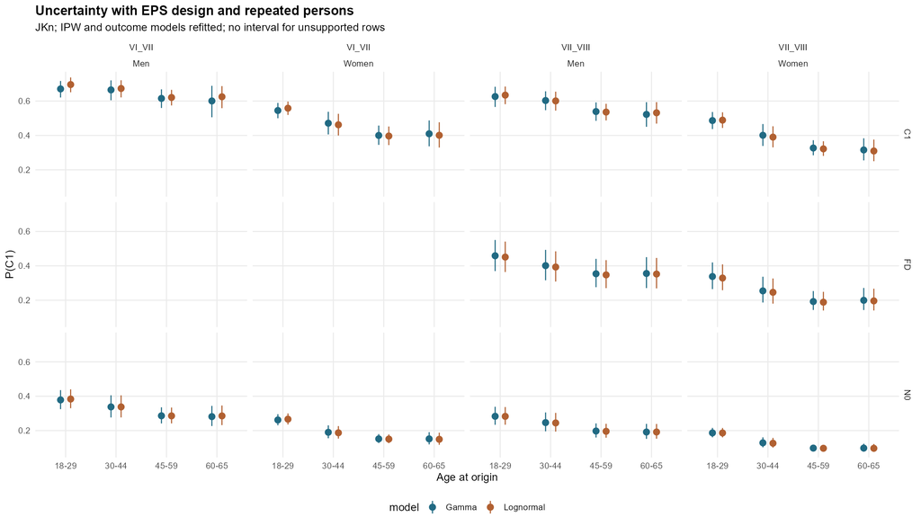

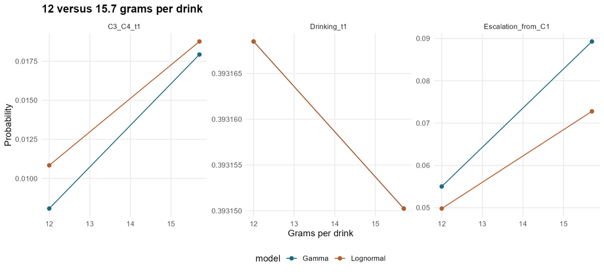

```
Elapsed: 0.10 minutes
```

```r
.t0 <- Sys.time()
ep_sensitivity <- do.call(rbind,lapply(c(12,15.7),function(g) {
 r<-ep_make_risk(ep_waves(g)); d<-ep_ipw_apply(r,ep_ipw_fit(r))
 do.call(rbind,lapply(c("Gamma","Lognormal"),function(nm) {
  pr<-ep_prob(ep_fit(d,nm),d)
  data.frame(grams_per_drink=g,model=nm,quantity=c("Drinking_t1","Escalation_from_C1","C3_C4_t1"),
   probability=c(stats::weighted.mean(1-pr[,1],d$wn),
    stats::weighted.mean(rowSums(pr[d$state0=="C1",3:5,drop=FALSE]),d$wn[d$state0=="C1"]),
    stats::weighted.mean(rowSums(pr[,4:5,drop=FALSE]),d$wn)))
 }))
}))
ep_save(ep_sensitivity,"conversion_sensitivity")
ep_weight_sens <- do.call(rbind,lapply(c("base_only","base_plus_IPW"),function(s) {
 d<-ep_d
 if(s=="base_only") for(p in ep_periods) {ii<-d$period==p;d$wn[ii]<-d$wbase[ii]/sum(d$wbase[ii])*ep_period_mass[[p]]}
 pr<-ep_prob(ep_fit(d,"Gamma"),d)
 data.frame(scenario=s,current_t1=stats::weighted.mean(1-pr[,1],d$wn),
  C3_C4_t1=stats::weighted.mean(rowSums(pr[,4:5]),d$wn))
}))
ep_save(ep_weight_sens,"weight_refit_sensitivity")
ep_hed_result<-ep_hed();ep_save(ep_hed_result$coef,"typical_quantity_signal_design_coefficients")
ep_save(ep_hed_result$proportions,"typical_quantity_signal_by_category")
ep_show(ep_sensitivity,"Conversion sensitivity, refitted models","Sensibilidad a la conversión, modelos reajustados",4)
ep_show(ep_weight_sens,"Refitted weight sensitivity","Sensibilidad de pesos con reajuste",4)
ep_plots()
cat(sprintf("Elapsed: %.2f minutes\n", as.numeric(difftime(Sys.time(), .t0, units = "mins"))))
```

## Review and reproducibility

`eps_markov_review.md` documents findings, fixes and remaining limitations. Checks include absent classes, FD/N0 labels, weight-scale-invariant dispersion, disjoint person folds, origin support, rank-matching margins and generator properties.

ES/EN versions are built from the same computation and executed in fresh sessions with identical seeds. An external check compares exported numerical tables; its result is attached after both executions. Reproducing results does not prove the statistical assumptions true.

**For microsimulation:** retain Gamma and lognormal as candidates, A as reference, and unchanged C1–C4 definitions. ENPG calibration and independent validation remain pending. Sparse tails, incomplete history and unidentified singleton-stratum variance constrain interpretation.

**Show R code**

```r
.t0 <- Sys.time()
ep_checks_table<-data.frame(check=names(ep_checks),passed=unlist(ep_checks),row.names=NULL)
ep_save(ep_checks_table,"analysis_checks")
ep_save(data.frame(seed=ep_seed,person_bootstrap_replicates=ep_B,CV_repetitions=ep_repeats,
 JKn_replicates=ncol(ep_des$multipliers),same_ID_same_multiplier=TRUE),"analysis_configuration")
ww<-as.data.frame(table(ep_warnings),stringsAsFactors=FALSE); names(ww)<-c("warning","n")
ep_save(ww,"fit_warnings")
ep_check(all(ep_checks_table$passed),"All recorded checks passed")
ep_show(ep_checks_table,"Executed checks on real EPS data","Comprobaciones ejecutadas con datos EPS reales")
si<-utils::capture.output(utils::sessionInfo())
writeLines(si[!grepl("[A-Za-z]:[/\\\\]",si)],file.path(ep_out,"session_info.txt"))
cat(sprintf("Elapsed: %.2f minutes\n", as.numeric(difftime(Sys.time(), .t0, units = "mins"))))
```

Executed checks on real EPS data

| check | passed |
| --- | --- |
| Cells run by ep_load() equal the listing shown in this notebook | TRUE |
| Published design codes agree across files | TRUE |
| VI-VII longitudinal weight and design are available | TRUE |
| Every risk-set ID has one published PSU and stratum | TRUE |
| Risk-set persons belong to the full VII design frame | TRUE |
| One row per person and interval | TRUE |
| Positive finite main weights | TRUE |
| No fabricated strict long-term origin states | TRUE |
| Observed pairs respect the history-state transition map | TRUE |
| Weight-scale invariance Gamma | TRUE |
| Weight-scale invariance Lognormal | TRUE |
| Weight-scale invariance Multinomial | TRUE |
| Weight-scale invariance Ordinal_two_part | TRUE |
| Disjoint persons CV 1:1 | TRUE |
| Disjoint persons CV 1:2 | TRUE |
| Disjoint persons CV 1:3 | TRUE |
| Disjoint persons CV 1:4 | TRUE |
| Disjoint persons CV 1:5 | TRUE |
| Disjoint persons CV 2:1 | TRUE |
| Disjoint persons CV 2:2 | TRUE |
| Disjoint persons CV 2:3 | TRUE |
| Disjoint persons CV 2:4 | TRUE |
| Disjoint persons CV 2:5 | TRUE |
| Disjoint persons CV 3:1 | TRUE |
| Disjoint persons CV 3:2 | TRUE |
| Disjoint persons CV 3:3 | TRUE |
| Disjoint persons CV 3:4 | TRUE |
| Disjoint persons CV 3:5 | TRUE |
| Every held-out prediction is finite | TRUE |
| Every available interval includes its point estimate | TRUE |
| Transport IDs disjoint forward1 | TRUE |
| Transport IDs disjoint forward2 | TRUE |
| Transport IDs disjoint forward3 | TRUE |
| Transport IDs disjoint forward4 | TRUE |
| Transport IDs disjoint forward5 | TRUE |
| Transport IDs disjoint retro1 | TRUE |
| Transport IDs disjoint retro2 | TRUE |
| Transport IDs disjoint retro3 | TRUE |
| Transport IDs disjoint retro4 | TRUE |
| Transport IDs disjoint retro5 | TRUE |
| Rank matching preserves both weighted margins VI_VII | TRUE |
| Rank matching preserves both weighted margins VII_VIII | TRUE |
| Annual stochastic matrix A | TRUE |
| Annual semigroup A | TRUE |
| Annual stochastic matrix Gamma | TRUE |
| Annual semigroup Gamma | TRUE |
| Annual stochastic matrix Lognormal | TRUE |
| Annual semigroup Lognormal | TRUE |

```
Elapsed: 0.00 minutes
```

## Why an IPW version 2

The cells above are version 1 of the EPS transition analysis and run unchanged. Their follow-up weights were built from the few variables that the transition engine itself uses, so the attrition model could not use what the panel knows about the people who left: housing, partner, work, smoking, depressive symptoms and self-rated health are all recorded at baseline and all predict both leaving the panel and drinking. Version 2 refits the attrition model with the agreed set of baseline predictors, documents in advance how deaths and impeded respondents are treated, and asks the one question that matters for the microsimulation: do the transition matrices move when the follow-up weights change?

Three things are new. First, the weight model is chosen once, before any resampling: a SuperLearner compares a handful of candidate learners by cross-validation on each interval and its ensemble prediction becomes the version 2 response probability. This pre-step is deliberately separated from the design replicates, so that the replicates measure sampling variation around a fixed weight model rather than re-selecting the model each time. Second, the matrices for the reference model A and for the lognormal model are estimated under three weighting schemes, official weight only, official weight times the version 1 IPW, and official weight times the version 2 IPW, with the same design replicates, and the differences between schemes are tabulated cell by cell. Third, the weights are judged by what they are for: covariate balance between the followed sample and the baseline risk set, the effective sample size they leave, and how much mass sits in a few extreme weights.

The transport section above already answers whether one interval predicts the other. What it does not show is whether the fitted models reproduce the observed destination shares within each interval and origin state; that table is added here from the held-out predictions of the version 1 cross-validation, with design-based intervals.

## Exits, attrition and the version 2 risk set

Deaths and impeded respondents are handled differently in the two versions, and the difference is recorded before anything is estimated. In version 1, the VI to VII interval is restricted to holders of the official longitudinal weight, which exists only for people re-interviewed in person at VII; the risk set is therefore already “survivors re-interviewed”, deaths, impeded people and phone-only follow-ups never enter it, the official weight carries the attrition adjustment, and the extra IPW corrects only missing classification and invalid links. In the VII to VIII interval, version 1 removes the people listed in the VIII deceased file from the risk set but keeps those listed in the VIII impeded file, so the impeded count as attrition and the IPW treats them as missing at random given the covariates.

Version 2 treats deaths and impeded respondents as competing exits, not as attrition. They leave the risk set and the weight model in both intervals: people recorded as deceased or impeded at VII cannot enter the VI to VII interval anyway, because they hold no panel weight, and people recorded as deceased or impeded at VIII are removed from the VII to VIII interval. The attrition table reports them only as exit counts, so that the denominator is transparent, and the percentage followed is computed among the survivors who could have been followed. Respondents followed at VII only by telephone did answer the survey but not the alcohol module; they are “followed without the alcohol module” and count as a missing outcome, not as an exit. Mortality itself is not modelled here: it belongs to the mortality module of the microsimulation, which has its own cause-specific inputs.

The attrition table is reported by interval and origin state, with the C3 and C4 origins merged because the attrition model, unlike the transition model, does not need the sparse top category on its own. For each interval it lists the baseline respondents under the interval’s weight rule (panel-weight holders for VI to VII, as in version 1; in-person VII respondents for VII to VIII), the deceased, the impeded, the phone-only follow-ups, the people interviewed with the alcohol module, those lost because they were not located or refused, and the percentage followed among survivors. Two features of the table follow from the weight rules rather than from the data: in the VI to VII interval the deceased, impeded and phone-only columns are zero by construction, because the baseline is the set of panel-weight holders, and the exits audit reports separately how many of the people in the VII exit files were VI respondents aged 18 to 65; and an “Unknown” origin row collects baseline respondents whose origin drinking state could not be classified, who are counted in the totals but excluded from the response model and the weights.

The predictors of the attrition model are measured at the origin wave. They are the variables agreed for this version, listed with their names in the public EPS files:

| Construct | VI (2015) | VII in person (2020) | VIII (2023) | Coding |
| --- | --- | --- | --- | --- |
| Origin state | f13/f14/f15 (harmonized) | same | same | N0, FD, C1, C2, C3plus (C3 and C4 merged) |
| Prior intensity | grams_day (harmonized) | same | same | log(g/day + 1) |
| Sex x age group | a8, a9 | same | same | 2 x 4 (18-29, 30-44, 45-59, 60-65) |
| Education completed | a12n/a12e/a12d (harmonized) | a12_n/a12_e/a12_d | same | three EPS levels plus a missing indicator |
| Housing tenure D.7 | d7 | d7 | d7 | own (codes 1-3) versus not own; missing as its own level |
| Partner I.1 | i1 in {1, 2, 9} | i1 in {1, 2, 4} | i1 in {1, 2, 4} | with versus without partner |
| Worked last week B.2 | MODULOB_historia_laboral: ongoing episode (latest start, open end) with b2 == 1 | b2a_SO == 1 | b2a_so == 1 | working versus not |
| Smokes F.12.a | f12a == 1 | f12a == 1 | f12_a == 1 | yes versus no |
| Depressive symptoms F.69 | f69_1..f69_9 | same | same | PHQ-9 = sum(code - 1) over nine items, >= 10 versus < 10; missing if any item is missing |
| Self-rated health A.10 | a10 | a10 | a10 | poor or fair (codes 4-6) versus better |

Macrozone and region were on the agreed list but are left out: the public EPS files do not carry the region of residence, only the birthplace and anonymous stratum and cluster identifiers, and birthplace is not residence. Non-response codes (8, 9, 88, 99, 888, 999 as labelled) become missing, and every binary predictor carries a “Missing” level, so no row is dropped for an unanswered item; the covariate audit reports, per wave, how many answers each predictor is missing and the share answering yes.

The version 2 risk set follows the version 1 origin rules (aged 18 to 65 at origin, compatible links, the weight rule of each interval) minus the deceased and impeded at the destination wave, with the covariates measured at origin merged in. The version 1 risk set and weights are not touched, so the version 1 tables keep their meaning inside this notebook.

**Show R code**

```r
.t0 <- Sys.time()
ep_v2_ex <- ep_v2_exits()
ep_v2_cov <- ep_v2_covariates()
ep_v2_attr <- ep_v2_attrition(ep_W, ep_v2_ex, ep_v2_cov)
ep_v2_risk <- ep_v2_make_risk(ep_W, ep_v2_ex, ep_v2_cov)
ep_v2_period_mass <- vapply(ep_periods, function(p) sum(ep_v2_risk$period == p & ep_v2_risk$complete), 1)
names(ep_v2_period_mass) <- ep_periods
ep_v2_exits_audit <- do.call(rbind, lapply(c("dead7", "imped7", "dead8", "imped8", "phone7"), function(k) {
 ids <- ep_v2_ex[[k]]; p <- if (grepl("7$", k)) "VI_VII" else "VII_VIII"; origin <- ep_W[ep_W$wave == ep_time$from[ep_time$period == p], ]
 data.frame(exit = k, period = p, n_file = length(ids), in_origin_respondents_18_65 = sum(origin$id %in% ids & origin$age >= 18 & origin$age <= 65),
  in_risk_set_v1 = sum(ep_risk$id[ep_risk$period == p] %in% ids), in_risk_set_v2 = sum(ep_v2_risk$id[ep_v2_risk$period == p] %in% ids))
}))
ep_save(ep_v2_exits_audit, "v2_exits_audit"); ep_save(ep_v2_attr, "v2_attrition_table")
ep_check(all(ep_v2_exits_audit$n_file[1:4] == c(516, 339, 882, 432)), "v2: exit files hold 516/339 (VII) and 882/432 (VIII) unique ids")
ep_check(all(ep_v2_exits_audit$in_risk_set_v2[1:4] == 0), "v2: no deceased or impeded person remains in risk set v2")
ep_check(all(with(ep_v2_attr, baseline == deceased + impeded + phone_only + completed + lost)), "v2: attrition table adds up")
ep_check(all(is.na(ep_v2_attr$pct_followed_of_survivors) | (ep_v2_attr$pct_followed_of_survivors >= 0 & ep_v2_attr$pct_followed_of_survivors <= 1)),
 "v2: share followed within [0, 1]")
ep_check(all(vapply(ep_periods, function(p) sum(ep_v2_attr$completed[ep_v2_attr$period == p & ep_v2_attr$state5 %in% ep_v2_states]) == ep_v2_period_mass[[p]], TRUE)),
 "v2: completed pairs in the attrition table equal the v2 period masses")
ep_show(ep_v2_exits_audit, "Exits and phone-only follow-ups: file counts and presence in the risk sets", "Exits and phone-only follow-ups: file counts and presence in the risk sets")
ep_show(ep_v2_attr, "Attrition by interval and origin state; the share followed is among survivors who could be followed",
 "Attrition by interval and origin state; the share followed is among survivors who could be followed", 3)
ep_show(ep_v2_covariate_audit(ep_v2_cov), "Origin covariates by wave: missingness after recoding non-response, and share Yes",
 "Origin covariates by wave: missingness after recoding non-response, and share Yes", 2)
cat(sprintf("Elapsed: %.2f minutes\n", as.numeric(difftime(Sys.time(), .t0, units = "mins"))))
```

Exits and phone-only follow-ups: file counts and presence in the risk sets

| exit | period | n_file | in_origin_respondents_18_65 | in_risk_set_v1 | in_risk_set_v2 |
| --- | --- | --- | --- | --- | --- |
| dead7 | VI_VII | 516 | 70 | 0 | 0 |
| imped7 | VI_VII | 339 | 75 | 0 | 0 |
| dead8 | VII_VIII | 882 | 60 | 0 | 0 |
| imped8 | VII_VIII | 432 | 32 | 32 | 0 |
| phone7 | VI_VII | 5031 | 3441 | 0 | 0 |

Attrition by interval and origin state; the share followed is among survivors who could be followed

| period | state5 | baseline | deceased | impeded | phone_only | completed | lost | pct_followed_of_survivors |
| --- | --- | --- | --- | --- | --- | --- | --- | --- |
| VI_VII | N0 | 3105 | 0 | 0 | 0 | 2936 | 169 | 0.946 |
| VI_VII | FD | 0 | 0 | 0 | 0 | 0 | 0 | NA |
| VI_VII | C1 | 1849 | 0 | 0 | 0 | 1637 | 212 | 0.885 |
| VI_VII | C2 | 85 | 0 | 0 | 0 | 78 | 7 | 0.918 |
| VI_VII | C3plus | 60 | 0 | 0 | 0 | 51 | 9 | 0.850 |
| VI_VII | Unknown | 153 | 0 | 0 | 0 | 133 | 20 | 0.869 |
| VI_VII | All | 5252 | 0 | 0 | 0 | 4835 | 417 | 0.921 |
| VII_VIII | N0 | 2735 | 28 | 21 | 0 | 1686 | 1000 | 0.628 |
| VII_VIII | FD | 641 | 13 | 4 | 0 | 412 | 212 | 0.660 |
| VII_VIII | C1 | 2161 | 14 | 5 | 0 | 1185 | 957 | 0.553 |
| VII_VIII | C2 | 124 | 1 | 0 | 0 | 63 | 60 | 0.512 |
| VII_VIII | C3plus | 92 | 0 | 0 | 0 | 47 | 45 | 0.511 |
| VII_VIII | Unknown | 354 | 4 | 2 | 0 | 189 | 159 | 0.543 |
| VII_VIII | All | 6107 | 60 | 32 | 0 | 3582 | 2433 | 0.596 |

Origin covariates by wave: missingness after recoding non-response, and share Yes

| wave | covariate | n | n_missing | pct_missing | share_yes |
| --- | --- | --- | --- | --- | --- |
| VI | own_home | 16906 | 0 | 0.00 | 0.70 |
| VI | partnered | 16906 | 28 | 0.17 | 0.44 |
| VI | working | 16906 | 0 | 0.00 | 0.53 |
| VI | smokes | 16906 | 40 | 0.24 | 0.26 |
| VI | phq9_ge10 | 16906 | 0 | 0.00 | 0.06 |
| VI | health_poor | 16906 | 22 | 0.13 | 0.34 |
| VII_presencial | own_home | 7800 | 26 | 0.33 | 0.67 |
| VII_presencial | partnered | 7800 | 0 | 0.00 | 0.47 |
| VII_presencial | working | 7800 | 0 | 0.00 | 0.56 |
| VII_presencial | smokes | 7800 | 6 | 0.08 | 0.26 |
| VII_presencial | phq9_ge10 | 7800 | 0 | 0.00 | 0.14 |
| VII_presencial | health_poor | 7800 | 2 | 0.03 | 0.46 |
| VIII | own_home | 15788 | 171 | 1.08 | 0.62 |
| VIII | partnered | 15788 | 0 | 0.00 | 0.33 |
| VIII | working | 15788 | 0 | 0.00 | 0.50 |
| VIII | smokes | 15788 | 119 | 0.75 | 0.22 |
| VIII | phq9_ge10 | 15788 | 0 | 0.00 | 0.10 |
| VIII | health_poor | 15788 | 19 | 0.12 | 0.32 |

```
Elapsed: 0.05 minutes
```

## Response model and SuperLearner weights

The response model is a survey-weighted logistic regression of “alcohol module observed at destination” on the predictors above, fitted separately in each interval with the published design (cluster and stratum identifiers, origin weight as the survey weight). It is reported as odds ratios with design-based 95% intervals. An odds ratio above one means that people with that attribute were more likely to be re-interviewed with the alcohol module than people at the reference level, holding the other predictors fixed; an interval that includes one means the data cannot tell the direction. The odds ratios of the “Missing” levels describe who left an item unanswered, not a substantive effect of the construct. This model is kept as the readable summary of who leaves the panel; it is not itself the version 2 weight.

The version 2 weight comes from a SuperLearner, which in plain words is a weighted average of several candidate prediction models, with the averaging weights chosen so that the combination predicts best on data it has not seen. Each interval’s data are split into five folds, stratified so that every fold has the same share of followed and lost people; each candidate is fitted on four folds and scored on the fifth, and the cross-validated risk is the average of these out-of-fold scores. The ensemble coefficients are the non-negative weights, summing to one, that minimise the cross-validated risk of the combination; the discrete winner is the single candidate with the lowest risk. The table of risks per learner is the one to read: it says whether any candidate beats the trivial constant prediction, that is whether attrition is predictable at all from these covariates, and how far apart the candidates are. The ensemble coefficients are less informative, because when two learners make similar predictions the coefficients can shift between them without changing the combination.

The library has four members. SL.mean predicts the weighted follow-up rate for everyone and is the benchmark. SL.glm is the main-effects logistic regression, the same specification as the response model above. SL.glmnet is a penalised logistic regression that shrinks small coefficients towards zero. SL.ranger is a random forest of five hundred trees with a minimum node size of fifty, so that the trees describe groups of people rather than individuals; the tuning is recorded in the configuration table. All four are fitted with the origin weight as observation weight, so that the fit targets the weighted population rather than the sample. The SuperLearner is fitted once per interval with a fixed seed, before the design replicates, and its ensemble predictions become the version 2 response probabilities.

The probabilities enter the weights as in version 1: a floor at 0.02 so that no one is given more than fifty times their baseline weight, the completed weight (origin weight divided by the probability) is trimmed at its first and ninety-ninth weighted percentiles within each interval, and the trimmed weights are rescaled so that each interval keeps the mass of its observed pairs. The probability summary reports, per interval, the distribution of the probabilities and how many cases hit the floor and the trimming bounds.

**Show R code**

```r
.t0 <- Sys.time()
ep_v2_glm_fit <- ep_v2_glm(ep_v2_risk)
ep_v2_or <- ep_v2_glm_fit$odds_ratios
ep_save(ep_v2_or, "v2_ipw_glm_odds_ratios")
ep_v2_sl <- ep_v2_superlearner(ep_v2_risk, V = 5, seed = ep_seed)
ep_save(ep_v2_sl$risks, "v2_superlearner_risks")
ep_v2_prob_summary <- do.call(rbind, lapply(ep_periods, function(p) {
 ii <- ep_v2_risk$period == p & ep_v2_risk$complete
 do.call(rbind, lapply(c("GLM", "SuperLearner"), function(k) {
  x <- if (k == "GLM") ep_v2_glm_fit$prob[ii] else ep_v2_sl$prob[ii]; q <- stats::quantile(x, c(.01, .5, .99))
  data.frame(period = p, model = k, n_complete = sum(ii), min = min(x), p01 = q[[1]], median = q[[2]], mean = mean(x), p99 = q[[3]], max = max(x),
   n_below_floor = sum(x < .02), correlation_glm_sl = stats::cor(ep_v2_glm_fit$prob[ii], ep_v2_sl$prob[ii]))
 }))
}))
ep_save(ep_v2_prob_summary, "v2_ipw_probabilities_summary")
ep_check(all(is.finite(ep_v2_or$OR)) && all(ep_v2_or$lower <= ep_v2_or$OR & ep_v2_or$OR <= ep_v2_or$upper), "v2: GLM odds ratios finite and inside their intervals")
ep_check(all(abs(tapply(ep_v2_sl$risks$coef, ep_v2_sl$risks$period, sum) - 1) < 1e-8) && all(is.finite(ep_v2_sl$risks$cv_risk)),
 "v2: SuperLearner weights sum to one with finite cross-validated risks")
ep_check(all(is.finite(ep_v2_sl$prob[ep_v2_risk$complete])) && all(ep_v2_sl$prob[ep_v2_risk$complete] > 0 & ep_v2_sl$prob[ep_v2_risk$complete] <= 1),
 "v2: SuperLearner probabilities of completed pairs lie in (0, 1]")
ep_show(ep_v2_or[ep_v2_or$term != "(Intercept)", ], "Survey-weighted logistic response model: odds of being followed with the alcohol module",
 "Survey-weighted logistic response model: odds of being followed with the alcohol module", 3)
ep_show(ep_v2_sl$risks, "SuperLearner per interval: cross-validated risk, ensemble weight, discrete winner and seconds",
 "SuperLearner per interval: cross-validated risk, ensemble weight, discrete winner and seconds", 4)
ep_show(ep_v2_prob_summary, "Observation probabilities among completed pairs; the SuperLearner ensemble feeds IPW v2",
 "Observation probabilities among completed pairs; the SuperLearner ensemble feeds IPW v2", 3)
cat(sprintf("Elapsed: %.2f minutes\n", as.numeric(difftime(Sys.time(), .t0, units = "mins"))))
```

Survey-weighted logistic response model: odds of being followed with the alcohol module

| period | term | OR | lower | upper | se | n | n_complete | n_nonzero | n_nonzero_complete |
| --- | --- | --- | --- | --- | --- | --- | --- | --- | --- |
| VI_VII | state5C1 | 0.885 | 0.538 | 1.456 | 0.250 | 5099 | 4702 | 1849 | 1637 |
| VI_VII | state5C2 | 2.904 | 0.844 | 9.996 | 0.621 | 5099 | 4702 | 85 | 78 |
| VI_VII | state5C3plus | 1.442 | 0.403 | 5.160 | 0.640 | 5099 | 4702 | 60 | 51 |
| VI_VII | lg0 | 0.773 | 0.638 | 0.936 | 0.096 | 5099 | 4702 | 1994 | 1766 |
| VI_VII | sexWomen | 0.839 | 0.562 | 1.253 | 0.202 | 5099 | 4702 | 3020 | 2810 |
| VI_VII | age_group30-44 | 0.995 | 0.551 | 1.796 | 0.297 | 5099 | 4702 | 867 | 784 |
| VI_VII | age_group45-59 | 0.750 | 0.465 | 1.209 | 0.240 | 5099 | 4702 | 1575 | 1452 |
| VI_VII | age_group60-65 | 0.964 | 0.460 | 2.018 | 0.371 | 5099 | 4702 | 540 | 515 |
| VI_VII | edu_num | 0.926 | 0.722 | 1.187 | 0.125 | 5099 | 4702 | 3540 | 3270 |
| VI_VII | edu_missing | 0.204 | 0.066 | 0.633 | 0.568 | 5099 | 4702 | 22 | 15 |
| VI_VII | own_homeNo | 1.312 | 0.982 | 1.753 | 0.146 | 5099 | 4702 | 1555 | 1439 |
| VI_VII | partneredNo | 0.862 | 0.624 | 1.190 | 0.162 | 5099 | 4702 | 2861 | 2635 |
| VI_VII | partneredMissing | 129955.912 | 26108.412 | 646861.970 | 0.806 | 5099 | 4702 | 4 | 4 |
| VI_VII | workingNo | 1.130 | 0.843 | 1.514 | 0.147 | 5099 | 4702 | 2098 | 1943 |
| VI_VII | smokesNo | 1.294 | 0.945 | 1.771 | 0.158 | 5099 | 4702 | 3631 | 3378 |
| VI_VII | smokesMissing | 0.342 | 0.042 | 2.778 | 1.053 | 5099 | 4702 | 6 | 5 |
| VI_VII | phq9_ge10No | 1.075 | 0.682 | 1.696 | 0.229 | 5099 | 4702 | 4741 | 4374 |
| VI_VII | health_poorNo | 0.752 | 0.529 | 1.071 | 0.177 | 5099 | 4702 | 3471 | 3177 |
| VI_VII | health_poorMissing | 0.094 | 0.013 | 0.665 | 0.985 | 5099 | 4702 | 5 | 3 |
| VI_VII | sexWomen:age_group30-44 | 0.570 | 0.263 | 1.233 | 0.388 | 5099 | 4702 | 542 | 490 |
| VI_VII | sexWomen:age_group45-59 | 1.376 | 0.757 | 2.500 | 0.300 | 5099 | 4702 | 950 | 891 |
| VI_VII | sexWomen:age_group60-65 | 1.524 | 0.504 | 4.611 | 0.556 | 5099 | 4702 | 315 | 304 |
| VII_VIII | state5FD | 1.485 | 1.152 | 1.914 | 0.127 | 5667 | 3393 | 624 | 412 |
| VII_VIII | state5C1 | 1.309 | 0.959 | 1.786 | 0.156 | 5667 | 3393 | 2142 | 1185 |
| VII_VIII | state5C2 | 1.322 | 0.650 | 2.685 | 0.356 | 5667 | 3393 | 123 | 63 |
| VII_VIII | state5C3plus | 1.949 | 0.868 | 4.377 | 0.406 | 5667 | 3393 | 92 | 47 |
| VII_VIII | lg0 | 0.849 | 0.744 | 0.968 | 0.066 | 5667 | 3393 | 2357 | 1295 |
| VII_VIII | sexWomen | 1.612 | 1.250 | 2.079 | 0.128 | 5667 | 3393 | 3313 | 2163 |
| VII_VIII | age_group30-44 | 0.765 | 0.558 | 1.050 | 0.159 | 5667 | 3393 | 1352 | 735 |
| VII_VIII | age_group45-59 | 1.179 | 0.903 | 1.540 | 0.134 | 5667 | 3393 | 2067 | 1294 |
| VII_VIII | age_group60-65 | 1.945 | 1.315 | 2.877 | 0.197 | 5667 | 3393 | 799 | 564 |
| VII_VIII | edu_num | 0.844 | 0.745 | 0.955 | 0.062 | 5667 | 3393 | 4222 | 2468 |
| VII_VIII | edu_missing | 0.235 | 0.034 | 1.649 | 0.978 | 5667 | 3393 | 6 | 3 |
| VII_VIII | own_homeNo | 0.838 | 0.686 | 1.024 | 0.101 | 5667 | 3393 | 2051 | 1164 |
| VII_VIII | own_homeMissing | 0.907 | 0.343 | 2.394 | 0.488 | 5667 | 3393 | 17 | 10 |
| VII_VIII | partneredNo | 1.202 | 1.031 | 1.400 | 0.077 | 5667 | 3393 | 3107 | 1852 |
| VII_VIII | workingNo | 1.101 | 0.936 | 1.295 | 0.082 | 5667 | 3393 | 1889 | 1211 |
| VII_VIII | smokesNo | 1.025 | 0.845 | 1.243 | 0.097 | 5667 | 3393 | 4037 | 2458 |
| VII_VIII | smokesMissing | 3.660 | 0.261 | 51.235 | 1.325 | 5667 | 3393 | 3 | 2 |
| VII_VIII | phq9_ge10No | 0.914 | 0.708 | 1.179 | 0.128 | 5667 | 3393 | 4898 | 2893 |
| VII_VIII | health_poorNo | 0.923 | 0.782 | 1.090 | 0.083 | 5667 | 3393 | 3417 | 1920 |
| VII_VIII | sexWomen:age_group30-44 | 1.124 | 0.780 | 1.620 | 0.184 | 5667 | 3393 | 781 | 476 |
| VII_VIII | sexWomen:age_group45-59 | 0.891 | 0.647 | 1.227 | 0.161 | 5667 | 3393 | 1241 | 840 |
| VII_VIII | sexWomen:age_group60-65 | 0.647 | 0.399 | 1.049 | 0.243 | 5667 | 3393 | 473 | 349 |

SuperLearner per interval: cross-validated risk, ensemble weight, discrete winner and seconds

| period | learner | cv_risk | coef | discrete_winner | n | n_complete | fit_seconds |
| --- | --- | --- | --- | --- | --- | --- | --- |
| VI_VII | SL.mean | 0.0783 | 0.3764 | FALSE | 5099 | 4702 | 11.0844 |
| VI_VII | SL.glm | 0.0780 | 0.3299 | FALSE | 5099 | 4702 | 11.0844 |
| VI_VII | SL.glmnet | 0.0778 | 0.0000 | TRUE | 5099 | 4702 | 11.0844 |
| VI_VII | SL.ranger_v2 | 0.0782 | 0.2937 | FALSE | 5099 | 4702 | 11.0844 |
| VII_VIII | SL.mean | 0.2485 | 0.0000 | FALSE | 5667 | 3393 | 12.7226 |
| VII_VIII | SL.glm | 0.2401 | 0.2204 | FALSE | 5667 | 3393 | 12.7226 |
| VII_VIII | SL.glmnet | 0.2396 | 0.4211 | TRUE | 5667 | 3393 | 12.7226 |
| VII_VIII | SL.ranger_v2 | 0.2405 | 0.3585 | FALSE | 5667 | 3393 | 12.7226 |

Observation probabilities among completed pairs; the SuperLearner ensemble feeds IPW v2

| period | model | n_complete | min | p01 | median | mean | p99 | max | n_below_floor | correlation_glm_sl |
| --- | --- | --- | --- | --- | --- | --- | --- | --- | --- | --- |
| VI_VII | GLM | 4702 | 0.240 | 0.798 | 0.932 | 0.920 | 0.971 | 1.000 | 0 | 0.936 |
| VI_VII | SuperLearner | 4702 | 0.561 | 0.847 | 0.924 | 0.919 | 0.952 | 0.956 | 0 | 0.936 |
| VII_VIII | GLM | 3393 | 0.209 | 0.336 | 0.596 | 0.582 | 0.763 | 0.822 | 0 | 0.953 |
| VII_VIII | SuperLearner | 3393 | 0.299 | 0.369 | 0.596 | 0.584 | 0.738 | 0.774 | 0 | 0.953 |

```
Elapsed: 0.41 minutes
```

## Three weighting schemes and the shift table

The matrices are estimated under three schemes, with the same version 2 risk set and the same fitting code. Scheme one uses the official weight only, normalised to the interval mass over the followed rows, and shows what the matrices look like with no follow-up adjustment beyond the one that the official panel weight already carries. Scheme two multiplies the official weight by the version 1 IPW, fitted with the version 1 function on the version 2 risk set. Scheme three multiplies the official weight by the version 2 IPW from the SuperLearner. Only the reference model A and the lognormal model are run; the other models were compared in version 1 and the question here is about weights, not models.

The intervals use the same JKn design replicates as version 1, with one convention that must be read with the results. Under scheme two the version 1 IPW is refitted inside every replicate, as before, so its intervals include the uncertainty of the weight model. Under scheme three the SuperLearner probabilities are held fixed and only the trimming bounds and the normalisation are recomputed in each replicate; those intervals are therefore conditional on the weight model, and they are slightly narrower than they would be if the SuperLearner were refitted with every replicate. Refitting it inside the replicates would be possible but expensive and would mix model selection with sampling variation, which the one-time pre-step was designed to avoid.

The shift table subtracts scheme one from scheme two and from scheme three, cell by cell, and reports per interval and model the mean absolute shift, the largest absolute shift and the cell where it occurs, by sex and age group, by sex and age group pooled over intervals, and over all. Whether a shift matters is not a question of statistical significance. A reasonable rule, proposed earlier for comparing models, is that two sets of transition probabilities are equivalent in practice when the prevalence they project for a subgroup differs by less than the confidence interval of the ENPG estimate for that same subgroup, since the ENPG is the survey that the microsimulation is calibrated to. A shift that stays inside that band changes nothing downstream even if it is larger than the design-based standard error; a shift in a high-consumption row that would move the projected C3 or C4 prevalence outside the band matters even if few pairs are involved. The relevant comparison for a shift is therefore the ENPG interval for the subgroup, not the log loss of the models.

**Show R code**

```r
.t0 <- Sys.time()
ep_v2_sch <- ep_v2_schemes(ep_v2_risk, ep_v2_sl$prob)
ep_check(all(vapply(ep_v2_sch, function(z) { m <- tapply(z$wn, z$period, sum); all(abs(m - ep_v2_period_mass[names(m)]) < 1e-6) }, TRUE)),
 "v2: every scheme reproduces the period masses")
ep_v2_mx <- ep_v2_scheme_matrices(ep_v2_risk, ep_v2_sch, ep_v2_sl$prob)
ep_v2_mat <- ep_v2_mx$matrices; ep_v2_shift <- ep_v2_mx$shift
ep_save(ep_v2_mat, "v2_transition_matrices_schemes_design_CI"); ep_save(ep_v2_shift, "v2_scheme_shift_table")
ep_v2_rowsum <- stats::aggregate(estimate ~ scheme + model + group + from, ep_v2_mat[!is.na(ep_v2_mat$estimate), ], sum)
ep_check(max(abs(ep_v2_rowsum$estimate - 1)) < 1e-8, "v2: every available matrix row sums to one")
ep_show(ep_v2_shift, "Shifts between weighting schemes per interval and model, probability scale; the largest cell is named",
 "Shifts between weighting schemes per interval and model, probability scale; the largest cell is named", 4)
ep_show(ep_v2_mat[ep_v2_mat$group == "All" & ep_v2_mat$from == "C1" & !ep_v2_mat$structural, c("scheme", "model", "from", "to", "n_origin", "estimate", "lower", "upper")],
 "Example: pooled next-wave probabilities from C1 under the three schemes, JKn intervals",
 "Example: pooled next-wave probabilities from C1 under the three schemes, JKn intervals", 3)
cat(sprintf("Elapsed: %.2f minutes\n", as.numeric(difftime(Sys.time(), .t0, units = "mins"))))
```

```
v2 JKn replicate 1: 2.1 s; projected 3.9 minutes for 111 replicates x 3 schemes
v2 design JKn 10/111
v2 design JKn 20/111
v2 design JKn 30/111
v2 design JKn 40/111
v2 design JKn 50/111
v2 design JKn 60/111
v2 design JKn 70/111
v2 design JKn 80/111
v2 design JKn 90/111
v2 design JKn 100/111
v2 design JKn 110/111
v2 design JKn 111/111
```

Shifts between weighting schemes per interval and model, probability scale; the largest cell is named

| period | model | comparison | cells | mean_abs_shift | max_abs_shift | max_cell | max_cell_n_origin | official | alternative |
| --- | --- | --- | --- | --- | --- | --- | --- | --- | --- |
| All | A | ipw_v1 minus official | 255 | 0.0050 | 0.0445 | Men\|18-29 C4->C1 | 16 | 0.4795 | 0.5240 |
| All | A | ipw_v2_sl minus official | 255 | 0.0040 | 0.0221 | Men\|30-44 C1->C1 | 302 | 0.6503 | 0.6282 |
| VI_VII | A | ipw_v1 minus official | 175 | 0.0045 | 0.0363 | VI_VII\|Women\|45-59 C4->C1 | 1 | 0.4721 | 0.5084 |
| VI_VII | A | ipw_v2_sl minus official | 175 | 0.0037 | 0.0208 | VI_VII\|Men\|30-44 C3->FD | 5 | 0.2340 | 0.2549 |
| VII_VIII | A | ipw_v1 minus official | 215 | 0.0050 | 0.0462 | VII_VIII\|Men\|18-29 C4->C1 | 6 | 0.4940 | 0.5402 |
| VII_VIII | A | ipw_v2_sl minus official | 215 | 0.0039 | 0.0209 | VII_VIII\|Women\|30-44 C2->C1 | 13 | 0.4944 | 0.4735 |
| All | Lognormal | ipw_v1 minus official | 255 | 0.0049 | 0.0335 | Men\|60-65 C4->C1 | 4 | 0.5155 | 0.5490 |
| All | Lognormal | ipw_v2_sl minus official | 255 | 0.0040 | 0.0331 | Men\|30-44 C2->C1 | 8 | 0.6268 | 0.5937 |
| VI_VII | Lognormal | ipw_v1 minus official | 175 | 0.0053 | 0.0354 | VI_VII\|Men\|60-65 C4->C1 | 3 | 0.5293 | 0.5647 |
| VI_VII | Lognormal | ipw_v2_sl minus official | 175 | 0.0044 | 0.0322 | VI_VII\|Men\|30-44 C2->C1 | 3 | 0.6426 | 0.6105 |
| VII_VIII | Lognormal | ipw_v1 minus official | 215 | 0.0053 | 0.0404 | VII_VIII\|Men\|18-29 C4->C1 | 6 | 0.5353 | 0.5757 |
| VII_VIII | Lognormal | ipw_v2_sl minus official | 215 | 0.0041 | 0.0276 | VII_VIII\|Men\|30-44 C2->C1 | 5 | 0.6098 | 0.5821 |

Example: pooled next-wave probabilities from C1 under the three schemes, JKn intervals

| scheme | model | from | to | n_origin | estimate | lower | upper |
| --- | --- | --- | --- | --- | --- | --- | --- |
| official | A | C1 | FD | 2822 | 0.380 | 0.348 | 0.413 |
| official | A | C1 | C1 | 2822 | 0.567 | 0.533 | 0.601 |
| official | A | C1 | C2 | 2822 | 0.032 | 0.025 | 0.040 |
| official | A | C1 | C3 | 2822 | 0.013 | 0.009 | 0.018 |
| official | A | C1 | C4 | 2822 | 0.008 | 0.005 | 0.013 |
| official | Lognormal | C1 | FD | 2822 | 0.387 | 0.356 | 0.420 |
| official | Lognormal | C1 | C1 | 2822 | 0.564 | 0.531 | 0.597 |
| official | Lognormal | C1 | C2 | 2822 | 0.029 | 0.025 | 0.034 |
| official | Lognormal | C1 | C3 | 2822 | 0.013 | 0.011 | 0.015 |
| official | Lognormal | C1 | C4 | 2822 | 0.006 | 0.005 | 0.008 |
| ipw_v1 | A | C1 | FD | 2822 | 0.381 | 0.354 | 0.409 |
| ipw_v1 | A | C1 | C1 | 2822 | 0.564 | 0.535 | 0.592 |
| ipw_v1 | A | C1 | C2 | 2822 | 0.032 | 0.026 | 0.041 |
| ipw_v1 | A | C1 | C3 | 2822 | 0.014 | 0.010 | 0.020 |
| ipw_v1 | A | C1 | C4 | 2822 | 0.009 | 0.005 | 0.014 |
| ipw_v1 | Lognormal | C1 | FD | 2822 | 0.389 | 0.362 | 0.417 |
| ipw_v1 | Lognormal | C1 | C1 | 2822 | 0.561 | 0.534 | 0.589 |
| ipw_v1 | Lognormal | C1 | C2 | 2822 | 0.030 | 0.027 | 0.034 |
| ipw_v1 | Lognormal | C1 | C3 | 2822 | 0.013 | 0.011 | 0.015 |
| ipw_v1 | Lognormal | C1 | C4 | 2822 | 0.006 | 0.005 | 0.008 |
| ipw_v2_sl | A | C1 | FD | 2822 | 0.383 | 0.355 | 0.411 |
| ipw_v2_sl | A | C1 | C1 | 2822 | 0.562 | 0.533 | 0.591 |
| ipw_v2_sl | A | C1 | C2 | 2822 | 0.032 | 0.026 | 0.041 |
| ipw_v2_sl | A | C1 | C3 | 2822 | 0.014 | 0.010 | 0.020 |
| ipw_v2_sl | A | C1 | C4 | 2822 | 0.008 | 0.005 | 0.014 |
| ipw_v2_sl | Lognormal | C1 | FD | 2822 | 0.390 | 0.362 | 0.419 |
| ipw_v2_sl | Lognormal | C1 | C1 | 2822 | 0.561 | 0.532 | 0.589 |
| ipw_v2_sl | Lognormal | C1 | C2 | 2822 | 0.030 | 0.027 | 0.034 |
| ipw_v2_sl | Lognormal | C1 | C3 | 2822 | 0.013 | 0.011 | 0.015 |
| ipw_v2_sl | Lognormal | C1 | C4 | 2822 | 0.006 | 0.005 | 0.008 |

```
Elapsed: 3.97 minutes
```

## Balance and weight diagnostics

The purpose of a follow-up weight is to make the followed sample look like the baseline risk set on the predictors of attrition. The standardized mean difference measures this directly: for every predictor level it is the weighted mean among the followed people minus the mean in the full baseline risk set, divided by the pooled standard deviation, so that it is comparable across variables. Values below 0.1 in absolute value are the customary target for acceptable balance; values above it mark a predictor on which the followed sample still differs from the people it is supposed to represent. The diagnostic is computed for the three schemes, so the reader can see what scheme one leaves unbalanced, what the version 1 IPW repairs, and what the version 2 IPW adds.

The weight diagnostics describe the price paid for balance. The Kish effective sample size is the number of equally weighted observations that would give the same variance as the actual weights; the further it falls below the number of followed rows, the more variable the weights. The ratio of the maximum weight to the mean weight and the share of the total weight carried by the top one percent of rows show whether a few people dominate; the counts at the floor and at the lower and upper trimming bounds show how often the safeguards had to act. Balance obtained at the cost of a very small effective sample is not an improvement. One comparison needs care: the official-weight scheme is untrimmed, while both IPW schemes trim the completed weight at its first and ninety-ninth percentiles, which also cuts the tails of the official weight itself; a higher effective sample size under the IPW schemes therefore reflects the trimming and must not be read as a precision gain from the inverse-probability correction.

Both diagnostics are reported by interval and origin state as well as overall, because the transition matrix is estimated row by row: balance over the whole interval can hide a row, typically the heavier-drinking origins, where the followed sample is still unlike the people who left. It is in those rows that the three schemes may disagree most and where the shift table should be read together with the diagnostics.

**Show R code**

```r
.t0 <- Sys.time()
ep_v2_diag <- ep_v2_diagnostics(ep_v2_risk, ep_v2_sch)
ep_v2_smd <- ep_v2_diag$smd; ep_v2_wdiag <- ep_v2_diag$weights
ep_save(ep_v2_smd, "v2_balance_smd"); ep_save(ep_v2_wdiag, "v2_weight_diagnostics")
ep_v2_balance <- do.call(rbind, lapply(split(ep_v2_smd[ep_v2_smd$state5 == "All", ], ep_key(ep_v2_smd[ep_v2_smd$state5 == "All", ], c("scheme", "period"))), function(z)
 data.frame(scheme = z$scheme[1], period = z$period[1], covariate_levels = sum(is.finite(z$smd)), max_abs_smd = max(abs(z$smd), na.rm = TRUE),
  n_abs_smd_at_least_0_1 = sum(abs(z$smd) >= .1, na.rm = TRUE), worst = z$covariate[which.max(abs(z$smd))])))
ep_check(nrow(ep_v2_smd) == length(ep_v2_sch) * length(ep_periods) * (length(ep_v2_states) + 1) * length(unique(ep_v2_smd$covariate)),
 "v2: SMD table covers every scheme, interval, origin state and covariate level")
ep_show(ep_v2_balance, "Balance of the completed weighted sample against the baseline risk set, all origins; |SMD| target below 0.1",
 "Balance of the completed weighted sample against the baseline risk set, all origins; |SMD| target below 0.1", 3)
ep_show(ep_v2_wdiag[ep_v2_wdiag$state5 == "All", ], "Weight diagnostics per scheme and interval: Kish ESS, extremes, top 1% share, floor and trimming counts",
 "Weight diagnostics per scheme and interval: Kish ESS, extremes, top 1% share, floor and trimming counts", 2)
cat(sprintf("Elapsed: %.2f minutes\n", as.numeric(difftime(Sys.time(), .t0, units = "mins"))))
```

Balance of the completed weighted sample against the baseline risk set, all origins; |SMD| target below 0.1

| scheme | period | covariate_levels | max_abs_smd | n_abs_smd_at_least_0_1 | worst |
| --- | --- | --- | --- | --- | --- |
| ipw_v1 | VI_VII | 32 | 0.052 | 0 | age_group:30-44 |
| ipw_v1 | VII_VIII | 32 | 0.048 | 0 | own_home:No |
| ipw_v2_sl | VI_VII | 32 | 0.050 | 0 | age_group:30-44 |
| ipw_v2_sl | VII_VIII | 32 | 0.060 | 0 | age_group:30-44 |
| official | VI_VII | 32 | 0.028 | 0 | health_poor:Missing |
| official | VII_VIII | 32 | 0.127 | 3 | sex:Men |

Weight diagnostics per scheme and interval: Kish ESS, extremes, top 1% share, floor and trimming counts

| scheme | period | state5 | n_complete | ESS | mean_weight | max_weight | max_over_mean | top1_share | n_at_floor | n_at_lower | n_at_upper |
| --- | --- | --- | --- | --- | --- | --- | --- | --- | --- | --- | --- |
| official | VI_VII | All | 4702 | 2179.52 | 1 | 41.42 | 41.42 | 0.08 | NA | NA | NA |
| official | VII_VIII | All | 3393 | 1839.49 | 1 | 15.07 | 15.07 | 0.07 | NA | NA | NA |
| ipw_v1 | VI_VII | All | 4702 | 3153.58 | 1 | 4.45 | 4.45 | 0.05 | 0 | 47 | 47 |
| ipw_v1 | VII_VIII | All | 3393 | 1930.55 | 1 | 5.46 | 5.46 | 0.05 | 0 | 33 | 33 |
| ipw_v2_sl | VI_VII | All | 4702 | 3163.99 | 1 | 4.44 | 4.44 | 0.05 | 0 | 47 | 47 |
| ipw_v2_sl | VII_VIII | All | 3393 | 2016.50 | 1 | 5.34 | 5.34 | 0.05 | 0 | 33 | 33 |

```
Elapsed: 0.00 minutes
```

## Temporal consistency within intervals

The transport section asks whether a model fitted on one interval predicts the other. The complementary question is whether the models reproduce, within each interval, the destination shares actually observed from each origin state. The version 1 cross-validation already produced held-out predictions for every pair, that is predictions made by a model that did not see that person; from them this section computes, for each interval, origin state and destination class, the observed share, the predicted share and their difference, with design-based intervals for the difference. A difference whose interval excludes zero marks a cell the model misses systematically rather than by chance; cells with few origin pairs are flagged as sparse, because their intervals are wide and their point differences unstable. The table is produced for model A and for the lognormal model.

**Show R code**

Largest held-out gaps by interval, origin state and destination; origin cells with at least 30 rows

| model | period | state0 | destination | n_origin | observed | predicted | difference | se | lower | upper | sparse |
| --- | --- | --- | --- | --- | --- | --- | --- | --- | --- | --- | --- |
| Lognormal | VI_VII | C2 | C1 | 78 | 0.4413 | 0.5291 | -0.0877 | 0.0594 | -0.2061 | 0.0306 | FALSE |
| Lognormal | VI_VII | C3 | C1 | 32 | 0.7461 | 0.6588 | 0.0873 | 0.0914 | -0.0946 | 0.2692 | FALSE |
| A | VII_VIII | C3 | C1 | 35 | 0.6048 | 0.6795 | -0.0747 | 0.1157 | -0.3050 | 0.1556 | FALSE |
| Lognormal | VII_VIII | C2 | NC | 63 | 0.3727 | 0.4372 | -0.0645 | 0.0707 | -0.2053 | 0.0764 | FALSE |
| Lognormal | VI_VII | C3 | C2 | 32 | 0.0000 | 0.0627 | -0.0627 | 0.0023 | -0.0674 | -0.0581 | FALSE |
| Lognormal | VI_VII | C2 | NC | 78 | 0.3736 | 0.3118 | 0.0618 | 0.0639 | -0.0655 | 0.1891 | FALSE |
| A | VI_VII | C3 | C1 | 32 | 0.7461 | 0.6940 | 0.0521 | 0.1030 | -0.1531 | 0.2572 | FALSE |
| Lognormal | VII_VIII | C2 | C1 | 63 | 0.5120 | 0.4684 | 0.0436 | 0.0762 | -0.1082 | 0.1953 | FALSE |
| Lognormal | VI_VII | C2 | C2 | 78 | 0.1317 | 0.0890 | 0.0427 | 0.0414 | -0.0397 | 0.1252 | FALSE |
| Lognormal | VI_VII | C3 | C3 | 32 | 0.0000 | 0.0366 | -0.0366 | 0.0027 | -0.0419 | -0.0313 | FALSE |
| A | VII_VIII | C3 | C2 | 35 | 0.0764 | 0.0430 | 0.0333 | 0.0351 | -0.0366 | 0.1032 | FALSE |
| A | VI_VII | C3 | C2 | 32 | 0.0000 | 0.0331 | -0.0331 | 0.0013 | -0.0356 | -0.0306 | FALSE |
| A | VII_VIII | C2 | C1 | 63 | 0.5120 | 0.4794 | 0.0326 | 0.0767 | -0.1202 | 0.1854 | FALSE |
| Lognormal | VI_VII | C3 | NC | 32 | 0.2539 | 0.2214 | 0.0325 | 0.0885 | -0.1438 | 0.2088 | FALSE |
| A | VII_VIII | C3 | NC | 35 | 0.2809 | 0.2502 | 0.0307 | 0.1021 | -0.1727 | 0.2341 | FALSE |

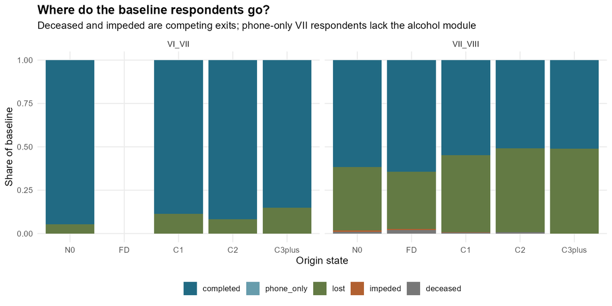

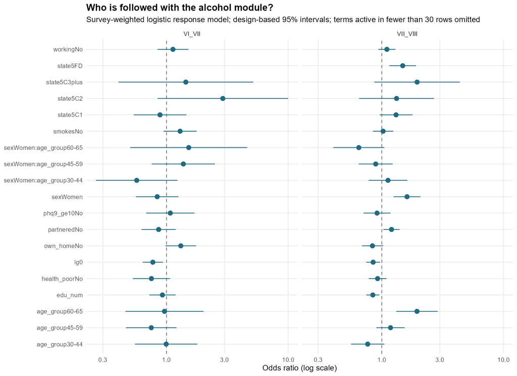

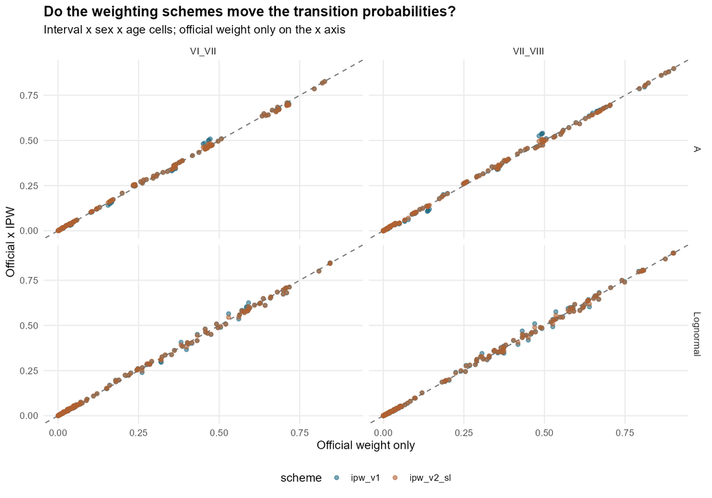

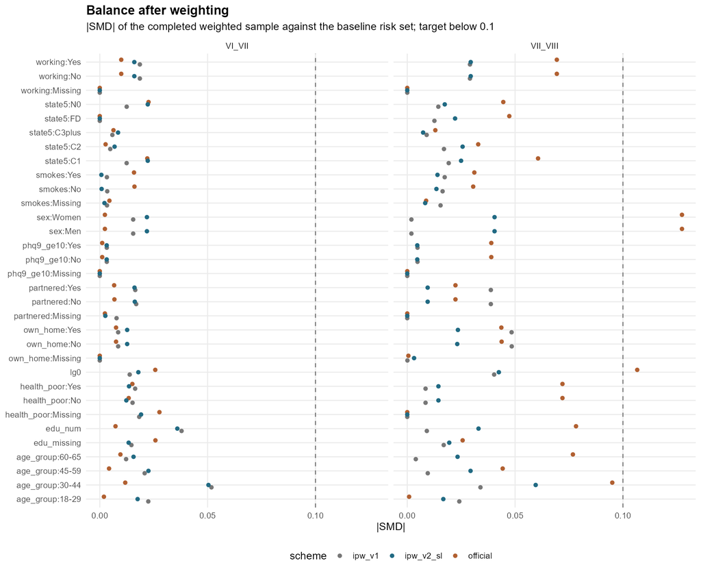

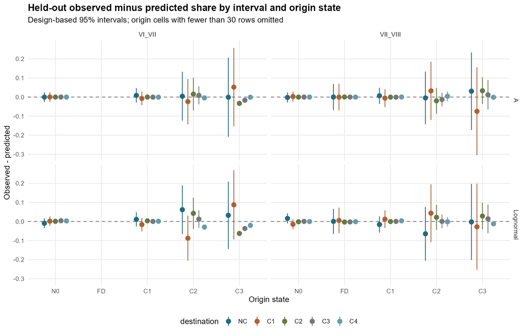

```
Elapsed: 0.07 minutes
```

```r
.t0 <- Sys.time()
ep_v2_calint <- ep_v2_calibration_interval(ep_cvtab, ep_d)
ep_save(ep_v2_calint, "v2_calibration_by_interval_origin")
ep_check(all(is.finite(ep_v2_calint$difference)), "v2: held-out calibration differences are finite")
ep_v2_cal_show <- ep_v2_calint[!ep_v2_calint$sparse, ]
ep_show(utils::head(ep_v2_cal_show[order(-abs(ep_v2_cal_show$difference)), ], 15),
 "Largest held-out gaps by interval, origin state and destination; origin cells with at least 30 rows",
 "Largest held-out gaps by interval, origin state and destination; origin cells with at least 30 rows", 4)
ep_v2_plots()
cat(sprintf("Elapsed: %.2f minutes\n", as.numeric(difftime(Sys.time(), .t0, units = "mins"))))
```

## Reproducibility

This notebook was executed once, in a fresh kernel pinned to the efficiency cores of the analysis machine, and the checks recorded along the way are collected in a table with the configuration (seed, cross-validation folds, learner library and tuning, number of design replicates, floor and trimming rules). The version 1 cells run unchanged with their own risk set and write their tables to the version 2 output folder, so that version 1 reproduces inside this notebook and its tables can be compared with the original output folder. A second execution and an extension of the external verifier are outside the scope of this version; the HTML rendered from the notebook is the deliverable, together with the output tables and the Spanish findings note.

**Show R code**

```r
.t0 <- Sys.time()
ep_v2_checks_table <- data.frame(check = names(ep_checks), passed = unlist(ep_checks), row.names = NULL)
ep_save(ep_v2_checks_table, "v2_analysis_checks")
ep_save(data.frame(seed = ep_seed, superlearner_V = 5, superlearner_stratified_CV = TRUE, superlearner_library = paste(ep_v2_sl$library, collapse = ";"),
 ranger_num_trees = 500, ranger_min_node_size = 50, probability_floor = .02, weight_trimming = "p1/p99 within interval", JKn_replicates = ncol(ep_des$multipliers), ipw_v1_refitted_in_replicates = TRUE,
 superlearner_fixed_in_replicates = TRUE, schemes = "official;ipw_v1;ipw_v2_sl", models = "A;Lognormal",
 exits = "deceased and impeded removed in both intervals; phone-only VII = missing outcome", macrozone_region = "left out: not in the public files"),
 "v2_analysis_configuration")
ep_check(all(ep_v2_checks_table$passed), "v2: all recorded checks passed")
ep_show(ep_v2_checks_table[grepl("^v2", ep_v2_checks_table$check), ], "Version 2 checks executed on real EPS data", "Version 2 checks executed on real EPS data")
cat(sprintf("Elapsed: %.2f minutes\n", as.numeric(difftime(Sys.time(), .t0, units = "mins"))))
```

Version 2 checks executed on real EPS data

| check | passed |
| --- | --- |
| v2: exit files hold 516/339 (VII) and 882/432 (VIII) unique ids | TRUE |
| v2: no deceased or impeded person remains in risk set v2 | TRUE |
| v2: attrition table adds up | TRUE |
| v2: share followed within [0, 1] | TRUE |
| v2: completed pairs in the attrition table equal the v2 period masses | TRUE |
| v2: GLM odds ratios finite and inside their intervals | TRUE |
| v2: SuperLearner weights sum to one with finite cross-validated risks | TRUE |
| v2: SuperLearner probabilities of completed pairs lie in (0, 1] | TRUE |
| v2: every scheme reproduces the period masses | TRUE |
| v2: every available matrix row sums to one | TRUE |
| v2: SMD table covers every scheme, interval, origin state and covariate level | TRUE |
| v2: held-out calibration differences are finite | TRUE |

```
Elapsed: 0.00 minutes
```

## Why a version 4

Versions 1 and 2 above run unchanged. Version 4 makes five changes, all agreed on 2026-10-26 and recorded in `__andres_control/decision_categorias_who_12g_2026-10-26.md`:

1. **WHO categories without gaps.** The exact border value goes to the lower class: women C1 up to 20, C2 above 20 and up to 40, C3 above 40 and up to 60, C4 above 60 g/day; men 40, 60 and 100. Versions 1 and 2 put the lower borders in the upper class (the JRT convention), with the women’s top cut already at 60 since 2026-10-26.
2. **12 g per drink**, the convention adopted by JRT after the reviewer comments on ADD-25-1576. No sensitivity with 13 g or with the JRT border convention is run.
3. **C3 and C4 always merged into C3plus.** The heavy tail is too sparse for two states. This follows Puka et al. (2022), who use non-drinker plus three WHO categories with the top one at 41 g (women) and 61 g (men) or more, and Kilian et al. (2025). Puka et al. also merge lifetime abstainers and former drinkers into one non-drinker state because lifetime abstention is reported inconsistently. C4 is kept only as a diagnostic of how well each model recovers the tail.
4. **EPS 2009 (round IV) as history.** It identifies former drinkers at VI, which versions 1 and 2 could not, and long-term abstainers in the sense of Calvo et al. (2020). It is never used as a transition interval.
5. **Widened age tolerance for links.** Every link window is widened by three years on each side (decision 2026-10-26). EPS identifiers (`folio_n20`) are stable person codes and the public files carry no birth or interview dates, so the age check only guards against gross coding errors: pairs gained between one and three years of tolerance look like the same people (education agrees as often as in strict pairs), while gaps beyond three years show twice the education inconsistencies and stay excluded. Pairs whose sex differs between waves are excluded.

The amount models are then compared formally: the v1 lognormal and gamma, a lognormal with variance by sex and age, a lognormal with a Pareto tail and a hurdle mixture. All use the same held-out predictions and the same metrics, with recovery of the observed C3plus and C4 shares as the priority. The adoption rule was written down before any result was seen.

The code is shown in chunks, each explained first, so the notebook can be audited without opening other files. The v1 core (`eps_markov_core.R`) is also split into explained chunks near the top, and the three cells that `ep_load()` runs from the alcohol persistence notebook are reproduced and checked against their source.

## v4 switches and the scoped swap

All v4 settings live in one list, `ep_v4_cfg`. A second list, `ep_v4_off`, turns every v4 change off; with it, the v4 code reproduces the v1/v2 classification, links and history. That gives one exact regression test for everything v4 adds.

**Show R code**

```r
.t0 <- Sys.time()
# EPS v4: additional definitions for eps_markov_transitions_v4_EN.ipynb, layered over the executed v2 notebook.
# Functions only, prefixed ep_v4_. They reuse the v1 core (eps_markov_core.R) and the v2 layer (eps_markov_v2_extra.R)
# without modifying them. Decisions (2026-10-26, __andres_control/decision_categorias_who_12g_2026-10-26.md): WHO border
# convention without gaps, 12 g per drink, C3 and C4 always merged into C3plus (C4 kept only as a tail diagnostic),
# EPS 2009 (round IV) used only as history, widened age tolerance for links. Row-level objects stay in memory; every
# export is an aggregate. Each '# @@eps-v4-def-<topic>' line starts a chunk that the notebook shows and explains.


# One named list holds every v4 switch, so the reproducibility table can print it and the regression test can turn
# all v4 changes off at once (ep_v4_off reproduces the v1/v2 classification, links and history).
ep_v4_cfg <- list(rule = "WHO", grams = 12, tol = 3L, use09 = TRUE, win09 = c(6, 8), propagate_longterm = TRUE)
ep_v4_off <- modifyList(ep_v4_cfg, list(rule = "JRT", tol = 0L, use09 = FALSE, propagate_longterm = FALSE))
ep_v4_ST <- c("N0", "FD", "C1", "C2", "C3plus")
# Object fingerprint used to prove that the v4 sections leave the v1/v2 objects untouched.
ep_v4_digest <- function(x) { f <- tempfile(); on.exit(unlink(f)); saveRDS(x, f, compress = FALSE); unname(tools::md5sum(f)) }
ep_v4_Y <- c("NC", "C1", "C2", "C3plus")
cat(sprintf("Elapsed: %.2f minutes\n", as.numeric(difftime(Sys.time(), .t0, units = "mins"))))
```

```
Elapsed: 0.00 minutes
```

Some v1/v2 functions read two global objects: the link windows (`ep_time`) and the per-interval pair counts used to renormalise weights (`ep_period_mass`). v4 needs other values for some calls, but the v1/v2 cells above must keep theirs. `ep_v4_scoped()` swaps the globals only while one expression runs and restores them on exit, even after an error. The reproducibility section checks that every v1/v2 object is unchanged at the end.

**Show R code**

```r
.t0 <- Sys.time()
# Several v1/v2 functions read the globals ep_time (link windows) and ep_period_mass (pair counts used to renormalise
# weights). v4 needs other values for some calls but must leave the v1/v2 cells untouched, so it swaps the globals only
# while one expression runs and restores them on exit, even after an error.
ep_v4_scoped <- function(vals, expr) {
  env <- globalenv(); had <- vapply(names(vals), exists, TRUE, envir = env, inherits = FALSE)
  old <- mget(names(vals)[had], envir = env)
  on.exit({ for (k in names(old)) assign(k, old[[k]], envir = env)
            rm(list = names(vals)[!had], envir = env) }, add = TRUE)
  for (k in names(vals)) assign(k, vals[[k]], envir = env)
  force(expr)
}
cat(sprintf("Elapsed: %.2f minutes\n", as.numeric(difftime(Sys.time(), .t0, units = "mins"))))
```

```
Elapsed: 0.00 minutes
```

## Categories: the WHO border rule

With 12 g per drink and “less than weekly” coded as half a day, EPS grams per day are multiples of 6/7 g. Comparisons are therefore made in lattice units (grams × 14 / 12), so a value of exactly 60 g cannot become 59.9999 through floating point. Both rules are contiguous, and the function stops if any current drinker with positive grams is left without a class.

**Show R code**

```r
.t0 <- Sys.time()
# Grams per day are compared on the observation lattice: with 12 g per drink and 'less than weekly' coded as 0.5 days,
# EPS grams per day are multiples of grams / 14 (6/7 g). Working in lattice units k = g * 14 / grams avoids floating-point
# ties such as 59.99999. WHO: the exact border value goes to the LOWER class (C1 g <= lo, C2 lo < g <= hi,
# C3 hi < g <= top, C4 g > top). JRT/v1: lower borders go up (g < lo, lo <= g < hi), top stays in C3 (g <= top).
# Both rules are contiguous, so every current drinker with g > 0 gets exactly one class (no gaps).
ep_v4_cuts <- function(sex) list(lo = ifelse(sex == "Women", 20, 40), hi = ifelse(sex == "Women", 40, 60),
                                 top = ifelse(sex == "Women", 60, 100))
ep_v4_cat <- function(current, g, sex, rule = ep_v4_cfg$rule, grams = ep_v4_cfg$grams) {
  rule <- match.arg(rule, c("WHO", "JRT")); u <- 14 / grams; ct <- ep_v4_cuts(sex)
  k <- round(g * u, 6); lo <- round(ct$lo * u, 6); hi <- round(ct$hi * u, 6); top <- round(ct$top * u, 6)
  ans <- rep(NA_character_, length(g)); ok <- current %in% 1 & is.finite(g) & g > 0
  if (rule == "WHO") {
    ans[ok & k <= lo] <- "C1"; ans[ok & k > lo & k <= hi] <- "C2"; ans[ok & k > hi & k <= top] <- "C3"; ans[ok & k > top] <- "C4"
  } else {
    ans[ok & k < lo] <- "C1"; ans[ok & k >= lo & k < hi] <- "C2"; ans[ok & k >= hi & k <= top] <- "C3"; ans[ok & k > top] <- "C4"
  }
  stopifnot(all(!is.na(ans[ok])))   # contiguous classes: no gaps
  ans
}
ep_v4_merge <- function(x) ifelse(x %in% c("C3", "C4"), "C3plus", as.character(x))
ep_v4_border_ties <- function(W) {
  d <- W[W$current %in% 1 & is.finite(W$grams) & W$grams > 0, ]
  do.call(rbind, lapply(c(20, 40, 60, 100), function(b) do.call(rbind, lapply(c("Women", "Men"), function(s) do.call(rbind,
    lapply(c(sort(unique(d$wave)), "All"), function(w) {
      i <- d$sex == s & (w == "All" | d$wave == w); hit <- i & abs(d$grams - b) < 1e-8
      data.frame(border = b, sex = s, wave = w, drinkers = sum(i), exact = sum(hit), exact_weighted = sum(d$weight_xs[hit]),
        is_a_cut_for_sex = b %in% unlist(ep_v4_cuts(s)))
    }))))))
}
cat(sprintf("Elapsed: %.2f minutes\n", as.numeric(difftime(Sys.time(), .t0, units = "mins"))))
```

```
Elapsed: 0.00 minutes
```

The table below counts the observations that fall exactly on a border. At 12 g only 60 g/day can occur exactly (70 × 6/7), so the WHO rule changes the class of men at exactly 60 g/day, from C3plus to C2, and nobody else.

**Show R code**

```r
.t0 <- Sys.time()
ep_v4_globals_before <- lapply(c("ep_W", "ep_risk", "ep_d", "ep_time", "ep_period_mass", "ep_v2_risk"), function(k) ep_v4_digest(get(k)))
ep_v4_cfg_table <- data.frame(setting = names(ep_v4_cfg), value = vapply(ep_v4_cfg, function(x) paste(x, collapse = "-"), ""))
ep_show(ep_v4_cfg_table, "v4 configuration", "v4 configuration")
ok <- !is.na(ep_W$cat)
ep_check(identical(ep_v4_cat(ep_W$current, ep_W$grams, ep_W$sex, "JRT")[ok], ep_W$cat[ok]), "The JRT rule of ep_v4_cat equals the v1 ep_cat")
ep_v4_ties <- ep_v4_border_ties(ep_W); ep_save(ep_v4_ties, "v4_border_ties")
ep_show(ep_v4_ties[ep_v4_ties$wave == "All", ], "Exact observations at each border, by sex (12 g, VI-VIII)", "Exact observations at each border, by sex (12 g, VI-VIII)")
dr <- ep_W[ep_W$current %in% 1 & ep_W$grams > 0 & !is.na(ep_W$cat), ]
ep_v4_migration <- as.data.frame(table(sex = dr$sex, wave = dr$wave,
  v1_rule = ep_v4_merge(ep_v4_cat(1, dr$grams, dr$sex, "JRT")), WHO_rule = ep_v4_merge(ep_v4_cat(1, dr$grams, dr$sex, "WHO"))))
ep_v4_migration <- ep_v4_migration[ep_v4_migration$Freq > 0 & as.character(ep_v4_migration$v1_rule) != as.character(ep_v4_migration$WHO_rule), ]
ep_save(ep_v4_migration, "v4_border_migration")
ep_show(ep_v4_migration, "Rows whose class changes from the v1 rule to the WHO rule", "Rows whose class changes from the v1 rule to the WHO rule")
ep_check(all(ep_v4_migration$sex == "Men" & ep_v4_migration$v1_rule == "C3plus" & ep_v4_migration$WHO_rule == "C2"),
  "The WHO rule only moves men at exactly 60 g/day from C3plus to C2")
cat(sprintf("Elapsed: %.2f minutes\n", as.numeric(difftime(Sys.time(), .t0, units = "mins"))))
```

v4 configuration

| setting | value |
| --- | --- |
| rule | WHO |
| grams | 12 |
| tol | 3 |
| use09 | TRUE |
| win09 | 6-8 |
| propagate_longterm | TRUE |

Exact observations at each border, by sex (12 g, VI-VIII)

| border | sex | wave | drinkers | exact | exact_weighted | is_a_cut_for_sex |
| --- | --- | --- | --- | --- | --- | --- |
| 20 | Women | All | 5578 | 0 | 0.00 | TRUE |
| 20 | Men | All | 8465 | 0 | 0.00 | FALSE |
| 40 | Women | All | 5578 | 0 | 0.00 | TRUE |
| 40 | Men | All | 8465 | 0 | 0.00 | TRUE |
| 60 | Women | All | 5578 | 0 | 0.00 | TRUE |
| 60 | Men | All | 8465 | 21 | 22733.67 | TRUE |
| 100 | Women | All | 5578 | 0 | 0.00 | FALSE |
| 100 | Men | All | 8465 | 0 | 0.00 | TRUE |

Rows whose class changes from the v1 rule to the WHO rule

| sex | wave | v1_rule | WHO_rule | Freq |
| --- | --- | --- | --- | --- |
| Men | VI | C3plus | C2 | 15 |
| Men | VII_presencial | C3plus | C2 | 4 |
| Men | VIII | C3plus | C2 | 2 |

```
Elapsed: 0.00 minutes
```

## EPS 2009 as history

The 2009 survey asks the same three alcohol questions as VI–VIII, under zero-padded names (`f13_01`, `f14_01`, `f15_01`, and so on). One coding difference matters. The 2009 frequency question runs from 1 (less than one day a week) to 8 (every day), while later waves run from 0 to 7. 2009 is therefore shifted down by one before the unchanged conversion `eps_alcohol()`. Without the shift, daily drinkers would become missing and everyone else would gain a day per week. Sex and age come from `entrevistado.dta` (`a8`, `a9`). The 2009 file has a cross-sectional weight but no PSU or stratum.

**Show R code**

```r
.t0 <- Sys.time()
# EPS 2009 (round IV) has the same three alcohol items as VI-VIII under zero-padded names (f13_01, f14_01, f15_01, ...).
# One coding difference matters: 2009 F14 runs 1..8 (1 = less than one day a week, 8 = every day; 88/99 missing)
# while VI-VIII run 0..7, so 2009 is shifted down by one before the unchanged eps_alcohol() conversion. Sex and age
# come from entrevistado.dta (a8, a9); the 2009 file has a cross-sectional weight but no PSU or stratum, so 2009 is
# used only as history for later waves, never as a transition interval.
ep_v4_load09 <- function(grams = ep_v4_cfg$grams) {
  dir09 <- file.path(eps_root, "2009", "2009")
  s <- haven::read_dta(file.path(dir09, "salud.dta"))
  e <- haven::read_dta(file.path(dir09, "entrevistado.dta"), col_select = c("folio_n20", "a8", "a9"))
  w <- haven::read_dta(file.path(dir09, "factor_EPS09.dta"))
  id <- as.character(s$folio_n20)
  stopifnot(!anyNA(id), !anyDuplicated(id), setequal(id, as.character(e$folio_n20)), setequal(id, as.character(w$folio_n20)))
  j <- match(id, as.character(e$folio_n20)); k <- match(id, as.character(w$folio_n20))
  sex <- ifelse(as.numeric(e$a8[j]) == 1, "Men", ifelse(as.numeric(e$a8[j]) == 2, "Women", NA_character_))
  item <- function(p) vapply(1:3, function(i) as.numeric(s[[sprintf("%s_%02d", p, i)]]), numeric(length(id)))
  s13 <- item("f13"); f14 <- item("f14"); q15 <- item("f15")
  f14 <- ifelse(f14 %in% 1:8, f14 - 1, NA_real_)   # 2009 codes 1..8 -> VI codes 0..7
  stopifnot(all(is.na(f14) | s13 %in% 1))           # skip pattern: frequency is answered only by beverage drinkers
  al <- eps_alcohol(s13, f14, q15, sex, grams = grams)
  stopifnot(sum(al$contradiction, na.rm = TRUE) == 0)
  data.frame(id = id, age = as.numeric(e$a9[j]), sex = sex, weight = as.numeric(w$factor_EPS09[k]),
             current = al$current, grams_day = al$grams_day, contradiction = al$contradiction)
}
ep_v4_link_audit <- function(h09, W, windows = list(c(6, 8), c(5, 7), c(4, 8)), tols = 0:3) {
  v <- W[W$wave == "VI", ]; j <- match(v$id, h09$id); ok <- !is.na(j)
  gap <- v$age[ok] - h09$age[j[ok]]; same <- v$sex[ok] == h09$sex[j[ok]]
  dist <- as.data.frame(table(gap = pmin(pmax(gap[same %in% TRUE], 2), 10)))
  acc <- do.call(rbind, lapply(windows, function(wi) do.call(rbind, lapply(tols, function(t)
    data.frame(window = sprintf("[%g,%g]", wi[1], wi[2]), tol = t, VI_respondents = nrow(v), with_2009_record = sum(ok),
      sex_mismatch = sum(!same, na.rm = TRUE), accepted = sum(same & gap >= wi[1] - t & gap <= wi[2] + t, na.rm = TRUE))))))
  list(accepted = acc, gap_distribution = dist)
}
cat(sprintf("Elapsed: %.2f minutes\n", as.numeric(difftime(Sys.time(), .t0, units = "mins"))))
```

```
Elapsed: 0.00 minutes
```

The link from 2009 to VI uses an age window of 6 to 8 years, widened by the tolerance. The 2009 fieldwork dates were not found, so the window comes from the observed age differences, whose mode is 7. History flows along the chain of compatible interviews: 2009 to VI, VI to VII, VII to VIII and VI to VIII. Direct links from 2009 to VII or VIII are not used.

Long-term abstention follows Calvo et al. (2020): no drinking for at least four years and no evidence of earlier drinking. A negative pair at least four years apart sets the flag. A current non-drinker linked to an earlier long-term abstainer keeps it, since the four-year span then holds a fortiori. Any observed drinking clears it. This is a proxy: 843 to 929 people who drank at VI had reported not drinking in 2009, so a negative report is not proof of never drinking.

**Show R code**

```r
.t0 <- Sys.time()
# ep_v4_time widens every link window by tol years on both sides (as TSM does) and, when 2009 is used, appends one
# history-only row IV_2009 -> VI. It stays history-only because the risk set, IPW, CV and annual layer loop over
# ep_periods, not over ep_time. ep_v4_waves is a copy of ep_waves (eps_markov_core.R) with four edits: it may append the
# 2009 rows, it also builds history AT wave VI, it reads link bounds from 'time', and it takes the classification
# function. With tol = 0, no 2009 and ep_cat it returns exactly ep_waves(12) (checked in the reproducibility section).
# Long-term abstention follows Calvo et al. (2020): no drinking for at least four years and no evidence of earlier
# drinking. A negative pair at least four years apart sets it; with propagate = TRUE a current non-drinker linked to an
# earlier long-term abstainer keeps the flag (the four-year span then holds a fortiori). Any observed drinking clears it.
ep_v4_time <- function(tol = ep_v4_cfg$tol, history09 = ep_v4_cfg$use09, win09 = ep_v4_cfg$win09, base = ep_time) {
  t <- base; t$min_years <- t$min_years - tol; t$max_years <- t$max_years + tol
  t$strict_min <- base$min_years
  if (history09) t <- rbind(data.frame(period = "IV_VI", from = "IV_2009", to = "VI", years = NA_real_,
    min_years = win09[1] - tol, max_years = win09[2] + tol, strict_min = win09[1]), t)
  t
}
ep_v4_waves <- function(grams = 12, h09 = NULL, time = ep_time, cat_fun = ep_cat, propagate = FALSE, longterm_min = 4) {
  W <- do.call(rbind, lapply(names(eps_data), function(w) {
    d <- eps_data[[w]]; j <- match(d$id, ep_design_map$id); g <- d$grams_day * grams / 12
    data.frame(id = d$id, wave = w, age = d$age, sex = d$sex, education = d$education,
      weight_xs = d$weight, psu = ep_design_map$psu[j], strata = ep_design_map$strata[j],
      current = ifelse(d$contradiction, NA_real_, d$current), grams = g,
      cat = ifelse(d$contradiction, NA_character_, cat_fun(d$current, g, d$sex)), signal = ep_qsignal(d))
  }))
  if (!is.null(h09)) {
    g <- h09$grams_day * grams / 12
    W <- rbind(W, data.frame(id = h09$id, wave = "IV_2009", age = h09$age, sex = h09$sex, education = NA_character_,
      weight_xs = h09$weight, psu = NA_character_, strata = NA_character_,
      current = ifelse(h09$contradiction, NA_real_, h09$current), grams = g,
      cat = ifelse(h09$contradiction, NA_character_, cat_fun(h09$current, g, h09$sex)), signal = NA_real_))
  }
  W$prior_use <- FALSE; W$longterm <- FALSE; W$two_wave_negative <- FALSE
  for (w in c("VI", "VII_presencial", "VIII")) {
    ii <- which(W$wave == w)
    for (j in which(time$to == w)) {
      tm <- time[j, ]; a <- W[W$wave == tm$from, ]; if (!nrow(a)) next
      ix <- match(W$id[ii], a$id)
      # time already carries any tolerance; floor/ceiling as in the v1 rule
      ok <- !is.na(ix) & a$sex[ix] == W$sex[ii] & W$age[ii] - a$age[ix] >= floor(tm$min_years) &
        W$age[ii] - a$age[ix] <= ceiling(tm$max_years)
      ok <- ok %in% TRUE
      W$prior_use[ii] <- W$prior_use[ii] | (ok & (a$current[ix] %in% 1 | a$prior_use[ix] %in% TRUE))
      neg <- ok & a$current[ix] %in% 0 & W$current[ii] %in% 0
      W$two_wave_negative[ii] <- W$two_wave_negative[ii] | neg
      # The four-year Calvo span is judged on the strict (unwidened) window when ep_v4_time supplied it.
      span <- if (!is.null(tm$strict_min)) tm$strict_min else tm$min_years
      if (span >= longterm_min) W$longterm[ii] <- W$longterm[ii] | neg
      if (propagate) W$longterm[ii] <- W$longterm[ii] | (ok & W$current[ii] %in% 0 & a$longterm[ix] %in% TRUE)
    }
  }
  W$longterm <- W$longterm & !W$prior_use
  W$two_wave_negative <- W$two_wave_negative & !W$prior_use
  W$state <- ifelse(W$current %in% 1, W$cat,
                     ifelse(W$current %in% 0, ifelse(W$prior_use, "FD", "N0"), NA_character_))
  W
}
# v4 risk set: the v2 risk set (deaths and impeded removed, v2 covariates attached) built from v4 waves and v4 link
# windows, kept in six states for the v1 IPW (whose response model uses state0), with merged five-state copies added.
ep_v4_make_risk <- function(W, time, exits, cov) {
  r <- ep_v4_scoped(list(ep_time = time), ep_v2_make_risk(W, exits, cov))
  r$state0_6 <- r$state0; r$state1_6 <- r$state1
  r$state0_5 <- factor(ep_v4_merge(r$state0), levels = ep_v4_ST)
  r$state1_5 <- ep_v4_merge(r$state1)
  r$y1_5 <- factor(ifelse(r$state1_5 %in% c("N0", "FD"), "NC", r$state1_5), levels = ep_v4_Y)
  r
}
ep_v4_period_mass <- function(r) vapply(ep_periods, function(p) sum(r$period == p & r$complete), 1)
# v1 IPW refitted on a v4 risk set and applied with that risk set's own pair counts.
ep_v4_ipw <- function(r) {
  mass <- ep_v4_period_mass(r)
  ep_v4_scoped(list(ep_period_mass = mass), ep_ipw_apply(r, ep_ipw_fit(r)))
}
cat(sprintf("Elapsed: %.2f minutes\n", as.numeric(difftime(Sys.time(), .t0, units = "mins"))))
```

```
Elapsed: 0.00 minutes
```

**Show R code**

```r
.t0 <- Sys.time()
# What EPS 2009 changes, before any amount model: who moves from N0 to FD, who becomes a long-term abstention candidate,
# and how the observed VI->VII and VII->VIII matrices move. W0/W9 differ only in the 2009 history (same rule, tolerance).
ep_v4_reclass <- function(W0, W9, waves = c("VI", "VII_presencial", "VIII")) {
  a <- W0[W0$wave %in% waves & W0$age >= 18 & W0$age <= 65, ]; b <- W9[match(paste(a$id, a$wave), paste(W9$id, W9$wave)), ]
  stopifnot(!anyNA(b$wave))
  other <- (a$state %in% b$state | (is.na(a$state) & is.na(b$state))) | (a$state %in% "N0" & b$state %in% "FD")
  stopifnot(all(other))   # the only allowed state change is N0 -> FD
  a$age_group <- ep_age(a$age); a$to_fd <- a$state %in% "N0" & b$state %in% "FD"; a$new_lt <- !a$longterm & b$longterm
  a$n0 <- a$state %in% "N0"; a$lt9 <- b$longterm %in% TRUE
  key <- function(d, by) split(d, d[by], drop = TRUE)
  rows <- function(by) do.call(rbind, lapply(key(a, by), function(z) data.frame(z[1, by, drop = FALSE],
    N0_without_2009 = sum(z$n0), N0_to_FD = sum(z$to_fd), pct_of_N0 = 100 * sum(z$to_fd) / max(sum(z$n0), 1),
    N0_to_FD_weighted = sum(z$weight_xs[z$to_fd]), longterm_without_2009 = sum(z$longterm), longterm_with_2009 = sum(z$lt9),
    longterm_cleared_by_2009_drinking = sum(z$longterm & !z$lt9),
    new_longterm = sum(z$new_lt), new_longterm_weighted = sum(z$weight_xs[z$new_lt]))))
  out <- rbind(cbind(level = "wave x sex x age", rows(c("wave", "sex", "age_group"))),
               cbind(level = "wave x sex", rows(c("wave", "sex")), age_group = "All"),
               cbind(level = "wave", rows("wave"), sex = "All", age_group = "All"))
  out <- out[c("level", "wave", "sex", "age_group", setdiff(names(out), c("level", "wave", "sex", "age_group")))]
  rownames(out) <- NULL; out
}
# Weighted observed transition matrix (five states x four destinations) of complete pairs, by period and sex.
ep_v4_obs_matrix <- function(d, by = c("period", "sex")) {
  d$grp <- if (length(by)) do.call(paste, c(lapply(d[by], as.character), sep = "|")) else "All"
  do.call(rbind, lapply(split(d, d$grp), function(z) {
    m <- stats::xtabs(wn ~ state0_5 + y1_5, z); n <- table(z$state0_5)
    out <- as.data.frame(as.table(m), stringsAsFactors = FALSE); names(out) <- c("from", "to", "weighted")
    tot <- tapply(out$weighted, out$from, sum); out$estimate <- ifelse(tot[out$from] > 0, out$weighted / tot[out$from], NA_real_)
    out$n_origin <- as.integer(n[out$from]); out$group <- z$grp[1]; out
  }))
}
ep_v4_matrix_shift <- function(d0, d9, by = c("period", "sex")) {
  m0 <- ep_v4_obs_matrix(d0, by); m9 <- ep_v4_obs_matrix(d9, by)
  k <- paste(m0$group, m0$from, m0$to); m9 <- m9[match(k, paste(m9$group, m9$from, m9$to)), ]
  data.frame(group = m0$group, from = m0$from, to = m0$to, n_origin_without_2009 = m0$n_origin, n_origin_with_2009 = m9$n_origin,
    p_without_2009 = m0$estimate, p_with_2009 = m9$estimate, change = m9$estimate - m0$estimate, row.names = NULL)
}
cat(sprintf("Elapsed: %.2f minutes\n", as.numeric(difftime(Sys.time(), .t0, units = "mins"))))
```

```
Elapsed: 0.00 minutes
```

**Show R code**

```r
.t0 <- Sys.time()
# Regression switch: with v4 switches off, the v4 wave builder reproduces the v1 wave table exactly.
ep_check(identical(ep_v4_waves(12, NULL, ep_time, ep_cat), ep_W), "v4 waves with the v4 switches off equal the v1 waves")
ep_v4_h09 <- ep_v4_load09()
ep_v4_t0 <- ep_v4_time(ep_v4_cfg$tol, FALSE); ep_v4_t9 <- ep_v4_time(ep_v4_cfg$tol, TRUE)
who <- function(c, g, s) ep_v4_cat(c, g, s, ep_v4_cfg$rule)
ep_v4_W0 <- ep_v4_waves(ep_v4_cfg$grams, NULL, ep_v4_t0, who, propagate = ep_v4_cfg$propagate_longterm)
ep_v4_W9 <- ep_v4_waves(ep_v4_cfg$grams, ep_v4_h09, ep_v4_t9, who, propagate = ep_v4_cfg$propagate_longterm)
ep_v4_la <- ep_v4_link_audit(ep_v4_h09, ep_v4_W0)
ep_save(ep_v4_la$accepted, "v4_2009_link_audit"); ep_save(ep_v4_la$gap_distribution, "v4_2009_gap_distribution")
ep_show(ep_v4_la$accepted, "2009 to VI links accepted by window and tolerance", "2009 to VI links accepted by window and tolerance")
ep_v4_rc <- ep_v4_reclass(ep_v4_W0, ep_v4_W9); ep_save(ep_v4_rc, "v4_2009_reclassification")
ep_show(ep_v4_rc[ep_v4_rc$level != "wave x sex x age", ], "N0 to FD reclassified and long-term abstention candidates, with versus without 2009 history (ages 18-65)",
  "N0 to FD reclassified and long-term abstention candidates, with versus without 2009 history (ages 18-65)")
ep_v4_r0 <- ep_v4_make_risk(ep_v4_W0, ep_v4_t0, ep_v2_ex, ep_v2_cov)
ep_v4_r9 <- ep_v4_make_risk(ep_v4_W9, ep_v4_t9, ep_v2_ex, ep_v2_cov)
ep_check(identical(ep_v4_r0$row_id, ep_v4_r9$row_id) && identical(ep_v4_r0$complete, ep_v4_r9$complete) && identical(ep_v4_r0$y1_5, ep_v4_r9$y1_5),
  "2009 history changes origin labels only: identical pairs and destinations")
ep_check(!any(ep_v4_r9$complete & ep_v4_r9$state0_5 == "N0" & ep_v4_r9$state1_5 == "FD") &&
  !any(ep_v4_r9$complete & ep_v4_r9$state0_5 != "N0" & ep_v4_r9$state1_5 == "N0"), "v4 pairs respect the history-state transition map")
ep_v4_d0 <- ep_v4_ipw(ep_v4_r0); ep_v4_d9 <- ep_v4_ipw(ep_v4_r9)
ep_v4_d9_fixed <- ep_v4_scoped(list(ep_period_mass = ep_v4_period_mass(ep_v4_r9)), ep_ipw_apply(ep_v4_r9, ep_ipw_fit(ep_v4_r0)))
ep_v4_shift09 <- rbind(cbind(ipw = "refitted", ep_v4_matrix_shift(ep_v4_d0, ep_v4_d9, "period")),
  cbind(ipw = "refitted", ep_v4_matrix_shift(ep_v4_d0, ep_v4_d9, c("period", "sex"))),
  cbind(ipw = "fixed at the no-2009 fit", ep_v4_matrix_shift(ep_v4_d0, ep_v4_d9_fixed, c("period", "sex"))))
ep_save(ep_v4_shift09, "v4_2009_matrix_shift")
ep_check(max(abs(ep_v4_shift09$change[ep_v4_shift09$ipw != "refitted" & ep_v4_shift09$from %in% c("C1", "C2", "C3plus")]), na.rm = TRUE) < 1e-12,
  "With the IPW fixed, 2009 history leaves the drinker rows unchanged")
ep_v4_origins <- as.data.frame(table(variant = rep(c("without 2009", "with 2009"), c(sum(ep_v4_r0$complete), sum(ep_v4_r9$complete))),
  period = c(as.character(ep_v4_r0$period[ep_v4_r0$complete]), as.character(ep_v4_r9$period[ep_v4_r9$complete])),
  origin = c(as.character(ep_v4_r0$state0_5[ep_v4_r0$complete]), as.character(ep_v4_r9$state0_5[ep_v4_r9$complete]))))
ep_save(ep_v4_origins, "v4_2009_pair_origins")
ep_show(stats::xtabs(Freq ~ variant + period + origin, ep_v4_origins) |> as.data.frame() |> stats::reshape(idvar = c("variant", "period"),
  timevar = "origin", direction = "wide"), "Complete-pair origins, five states", "Complete-pair origins, five states")
ep_show(ep_v4_shift09[ep_v4_shift09$ipw == "refitted" & ep_v4_shift09$group %in% ep_periods & ep_v4_shift09$from %in% c("N0", "FD"), ],
  "Observed weighted N0 and FD rows with and without 2009 history", "Observed weighted N0 and FD rows with and without 2009 history")
cat(sprintf("Elapsed: %.2f minutes\n", as.numeric(difftime(Sys.time(), .t0, units = "mins"))))
```

2009 to VI links accepted by window and tolerance

| window | tol | VI_respondents | with_2009_record | sex_mismatch | accepted |
| --- | --- | --- | --- | --- | --- |
| [6,8] | 0 | 16906 | 8881 | 79 | 8450 |
| [6,8] | 1 | 16906 | 8881 | 79 | 8661 |
| [6,8] | 2 | 16906 | 8881 | 79 | 8714 |
| [6,8] | 3 | 16906 | 8881 | 79 | 8729 |
| [5,7] | 0 | 16906 | 8881 | 79 | 7785 |
| [5,7] | 1 | 16906 | 8881 | 79 | 8625 |
| [5,7] | 2 | 16906 | 8881 | 79 | 8706 |
| [5,7] | 3 | 16906 | 8881 | 79 | 8731 |
| [4,8] | 0 | 16906 | 8881 | 79 | 8625 |
| [4,8] | 1 | 16906 | 8881 | 79 | 8706 |
| [4,8] | 2 | 16906 | 8881 | 79 | 8731 |
| [4,8] | 3 | 16906 | 8881 | 79 | 8741 |

N0 to FD reclassified and long-term abstention candidates, with versus without 2009 history (ages 18-65)

| level | wave | sex | age_group | N0_without_2009 | N0_to_FD | pct_of_N0 | N0_to_FD_weighted | longterm_without_2009 | longterm_with_2009 | longterm_cleared_by_2009_drinking | new_longterm | new_longterm_weighted |
| --- | --- | --- | --- | --- | --- | --- | --- | --- | --- | --- | --- | --- |
| wave x sex | VI | Men | All | 2919 | 548 | 18.774 | 521094.6 | 0 | 765 | 0 | 765 | 651413.5 |
| wave x sex | VII_presencial | Men | All | 770 | 96 | 12.468 | 128242.5 | 0 | 160 | 0 | 160 | 230805.2 |
| wave x sex | VIII | Men | All | 2421 | 90 | 3.717 | 114845.3 | 600 | 512 | 88 | 0 | 0.0 |
| wave x sex | VI | Women | All | 5236 | 432 | 8.251 | 386769.1 | 0 | 2132 | 0 | 2132 | 1889409.0 |
| wave x sex | VII_presencial | Women | All | 1951 | 94 | 4.818 | 147227.3 | 0 | 723 | 0 | 723 | 898433.0 |
| wave x sex | VIII | Women | All | 4062 | 117 | 2.880 | 129052.0 | 1744 | 1628 | 116 | 0 | 0.0 |
| wave | VI | All | All | 8155 | 980 | 12.017 | 907863.7 | 0 | 2897 | 0 | 2897 | 2540822.5 |
| wave | VII_presencial | All | All | 2721 | 190 | 6.983 | 275469.8 | 0 | 883 | 0 | 883 | 1129238.1 |
| wave | VIII | All | All | 6483 | 207 | 3.193 | 243897.3 | 2344 | 2140 | 204 | 0 | 0.0 |

Complete-pair origins, five states

| variant | period | Freq.C1 | Freq.C2 | Freq.C3plus | Freq.FD | Freq.N0 |
| --- | --- | --- | --- | --- | --- | --- |
| with 2009 | VI_VII | 1660 | 85 | 47 | 372 | 2609 |
| without 2009 | VI_VII | 1660 | 85 | 47 | 0 | 2981 |
| with 2009 | VII_VIII | 1185 | 65 | 45 | 542 | 1557 |
| without 2009 | VII_VIII | 1185 | 65 | 45 | 421 | 1678 |

Observed weighted N0 and FD rows with and without 2009 history

| ipw | group | from | to | n_origin_without_2009 | n_origin_with_2009 | p_without_2009 | p_with_2009 | change |
| --- | --- | --- | --- | --- | --- | --- | --- | --- |
| refitted | VI_VII | N0 | NC | 2981 | 2609 | 0.733 | 0.764 | 0.031 |
| refitted | VI_VII | FD | NC | 0 | 372 | NA | 0.571 | NA |
| refitted | VI_VII | N0 | C1 | 2981 | 2609 | 0.247 | 0.217 | -0.030 |
| refitted | VI_VII | FD | C1 | 0 | 372 | NA | 0.406 | NA |
| refitted | VI_VII | N0 | C2 | 2981 | 2609 | 0.009 | 0.010 | 0.001 |
| refitted | VI_VII | FD | C2 | 0 | 372 | NA | 0.007 | NA |
| refitted | VI_VII | N0 | C3plus | 2981 | 2609 | 0.010 | 0.009 | -0.001 |
| refitted | VI_VII | FD | C3plus | 0 | 372 | NA | 0.016 | NA |
| refitted | VII_VIII | N0 | NC | 1678 | 1557 | 0.853 | 0.858 | 0.006 |
| refitted | VII_VIII | FD | NC | 421 | 542 | 0.659 | 0.685 | 0.025 |
| refitted | VII_VIII | N0 | C1 | 1678 | 1557 | 0.144 | 0.139 | -0.006 |
| refitted | VII_VIII | FD | C1 | 421 | 542 | 0.334 | 0.310 | -0.025 |
| refitted | VII_VIII | N0 | C2 | 1678 | 1557 | 0.002 | 0.002 | 0.000 |
| refitted | VII_VIII | FD | C2 | 421 | 542 | 0.005 | 0.004 | 0.000 |
| refitted | VII_VIII | N0 | C3plus | 1678 | 1557 | 0.001 | 0.001 | 0.000 |
| refitted | VII_VIII | FD | C3plus | 421 | 542 | 0.001 | 0.001 | 0.000 |

```
Elapsed: 0.04 minutes
```

## Amount models: one harness, identical metrics

Every amount model returns a distribution of grams per day for destination drinkers, given covariates. Class probabilities are then obtained in the same way for all of them, by integrating that distribution between the cuts. For a continuous distribution, ≤ and < give the same probability, so the border rule changes the observed labels but not the predictions.

The candidates are listed below.

- **Lognormal**: the v1 model, unchanged.
- **Gamma**: the v1 model, unchanged.
- **Lognormal_sexage**: the variance of log grams is allowed to differ by sex and age group, shrunk toward the pooled variance with a strength chosen by inner cross-validation. With infinite shrinkage it is the v1 lognormal.
- **Lognormal_Pareto**: a lognormal up to each sex’s training 90th percentile, then a Pareto tail with a Hill exponent. The mass above the splice point still comes from the lognormal; only the shape of the tail changes.
- **Hurdle_Pareto** (the mixture): a logistic model for crossing the C3plus cut, a lognormal truncated below the cut, and a Pareto tail above it.

**Show R code**

```r
.t0 <- Sys.time()
# Amount of drinking among destination drinkers. Every model returns a CDF of grams/day given covariates, so class
# probabilities come from the same integration for all of them: P(C1) = F(lo), P(C2) = F(hi) - F(lo), P(C3plus) =
# 1 - F(hi) and, as a tail diagnostic only, P(C4) = 1 - F(top). For a continuous CDF, <= and < give the same
# probability, so the WHO border rule changes observed labels, not predictions. Weights are the IPW pair weights
# normalised to mean one (frequency weights, as in v1). Covariates are the v1 formula with the five-state origin.
#   Lognormal, Gamma: the v1 fits (ep_matrix_fit), unchanged.
#   Lognormal_sexage: log-grams variance by sex x age group, shrunk toward the pooled variance with strength k
#     (sigma2_g = (sum w r^2 + k sigma2_0) / (sum w + k)); location refitted by weighted least squares with weights
#     w / sigma2_g, three alternations. k = Inf gives the v1 lognormal; k is tuned by inner cross-validation.
#   Lognormal_Pareto: lognormal up to a sex-specific threshold u (training weighted 90th percentile of grams among
#     drinkers, required below the C3plus cut); above u, a Pareto tail 1 - F(t) = (1 - F_LN(u | x)) (u / t)^alpha_sex with
#     the weighted Hill estimator alpha = sum(w) / sum(w log(g / u)) over exceedances. The mass above u still comes from
#     the lognormal; only the shape of the tail changes.
#   Hurdle_Pareto (mixture): a logistic model gives pi(x) = P(g > hi | drinking, x); below hi the lognormal is
#     truncated to (0, hi]; above hi a Pareto tail with alpha_sex estimated on exceedances of hi.
# The C3plus share is set directly by the logistic part in Hurdle_Pareto, so its aggregate calibration is good by
# construction; the per-cell calibration (interval x origin, sex x age) is what can separate it from the others.
ep_v4_formula <- function() ep_formula("ordinal")
ep_v4_h <- function(grams = ep_v4_cfg$grams) grams / 14   # lattice step of observed grams/day (6/7 g at 12 g)
ep_v4_hill <- function(g, w, u) { e <- g > u; if (sum(e) < 5) return(NA_real_); sum(w[e]) / sum(w[e] * log(g[e] / u)) }
# Tail exponent by sex; a sex with fewer than 5 exceedances falls back to the exponent pooled over both sexes
# (exceedances of each sex's own threshold), and the fallback is recorded.
ep_v4_alpha <- function(dc, w, u) {
  sx <- c("Men", "Women"); a <- vapply(sx, function(s) { i <- dc$sex == s; ep_v4_hill(dc$grams1[i], w[i], u[[s]]) }, 1)
  n <- vapply(sx, function(s) sum(dc$sex == s & dc$grams1 > u[[s]]), 1)
  pooled <- { e <- dc$grams1 > u[as.character(dc$sex)]
    if (sum(e) < 5) stop("Fewer than 5 tail exceedances in both sexes: the Pareto exponent is not estimable")
    sum(w[e]) / sum(w[e] * log(dc$grams1[e] / u[as.character(dc$sex)][e])) }
  fb <- !is.finite(a); a[fb] <- pooled; stopifnot(all(is.finite(a)), all(a > 0))
  structure(a, exceedances = n, fallback = fb)
}
ep_v4_cap <- 150   # grams/day cap for tail draws and tail means (the AAF integration bound in JRT and ADD-25-1576)
ep_v4_lnfit <- function(dc) ep_matrix_fit(dc, ep_v4_formula(), dc$grams1, "lognormal")
ep_v4_eta <- function(o, d) as.numeric(ep_x(d, o$formula, o$columns) %*% o$coef)
ep_v4_sexage_fit <- function(dc, k, base = ep_v4_lnfit(dc), iter = 3) {
  o <- base; if (is.infinite(k)) { o$sigma_g <- NULL; return(o) }
  X <- ep_x(dc, o$formula, o$columns); y <- log(dc$grams1); w <- dc$wn / mean(dc$wn); g <- paste(dc$sex, dc$age_group)
  for (i in seq_len(iter)) {
    r <- y - as.numeric(X %*% o$coef); s0 <- sum(w * r^2) / sum(w)
    s2 <- c(tapply(w * r^2, g, sum)); ws <- c(tapply(w, g, sum)); s2 <- (s2 + k * s0) / (ws + k)
    o$coef <- stats::lm.wfit(X, y, as.numeric(w / s2[g]))$coefficients; o$coef[!is.finite(o$coef)] <- 0
  }
  r <- y - as.numeric(X %*% o$coef); s0 <- sum(w * r^2) / sum(w)
  s2 <- (c(tapply(w * r^2, g, sum)) + k * s0) / (c(tapply(w, g, sum)) + k)
  o$sigma_g <- sqrt(s2); o$sigma <- sqrt(s0); o$k <- k; o
}
ep_v4_sigma <- function(o, d) {
  if (is.null(o$sigma_g)) return(rep(o$sigma, nrow(d)))
  s <- o$sigma_g[paste(d$sex, d$age_group)]; s[is.na(s)] <- o$sigma; as.numeric(s)
}
# Fit one amount model on training destination drinkers dc; returns list(kind, cdf = function(t, d) -> matrix).
ep_v4_amount_fit <- function(dc, kind, k = NULL) {
  hi <- function(sex) ep_v4_cuts(sex)$hi; w <- dc$wn / mean(dc$wn)
  ln <- ep_v4_lnfit(dc)
  lncdf <- function(o) function(t, d) stats::pnorm((log(pmax(t, 1e-12)) - ep_v4_eta(o, d)) / ep_v4_sigma(o, d))
  if (kind == "Lognormal") return(list(kind = kind, cdf = lncdf(ln), fit = ln))
  if (kind == "Gamma") {
    ga <- ep_matrix_fit(dc, ep_v4_formula(), dc$grams1, "gamma")
    return(list(kind = kind, fit = ga, cdf = function(t, d) {
      mu <- exp(ep_v4_eta(ga, d)); stats::pgamma(t, shape = ga$shape, scale = mu / ga$shape) }))
  }
  if (kind == "Lognormal_sexage") { o <- ep_v4_sexage_fit(dc, k, ln); return(list(kind = kind, cdf = lncdf(o), fit = o, k = k)) }
  if (kind == "Lognormal_Pareto") {
    sx <- c("Men", "Women")
    u <- vapply(sx, function(s) { i <- dc$sex == s; ep_wquant(dc$grams1[i], w[i], .9) }, 1)
    u <- pmin(u, vapply(sx, hi, 1) - ep_v4_h())   # keep the splice below the C3plus cut
    a <- ep_v4_alpha(dc, w, u)
    F0 <- lncdf(ln)
    return(list(kind = kind, u = u, alpha = a, fit = ln, cdf = function(t, d) {
      uu <- u[as.character(d$sex)]; aa <- a[as.character(d$sex)]; Fu <- F0(matrix(uu), d)[, 1]
      tail <- 1 - (1 - Fu) * (uu / pmax(t, 1e-12))^aa
      ifelse(t <= uu, F0(t, d), tail) }))
  }
  if (kind %in% c("Hurdle_Pareto", "Hurdle_Pareto_ridge")) {
    h <- hi(dc$sex); top_class <- dc$grams1 > h
    # The tail indicator must be the observed WHO label (lattice-rounded cuts), not a separate float comparison.
    if (!is.null(dc$y1_5)) stopifnot(identical(top_class, as.character(dc$y1_5) == "C3plus"))
    pm <- if (kind == "Hurdle_Pareto") ep_binary_fit(dc, as.numeric(top_class), ep_v4_formula(), dc$wn) else
      ep_v4_ridge_fit(dc, as.numeric(top_class), ep_v4_formula(), dc$wn)
    pfun <- if (kind == "Hurdle_Pareto") ep_binary_prob else ep_v4_ridge_prob
    sx <- c("Men", "Women")
    a <- ep_v4_alpha(dc, w, stats::setNames(vapply(sx, hi, 1), sx))
    F0 <- lncdf(ln)
    return(list(kind = kind, alpha = a, fit = ln, tail_model = pm, cdf = function(t, d) {
      hh <- hi(d$sex); pi <- pfun(pm, d); aa <- a[as.character(d$sex)]; Fh <- F0(matrix(hh), d)[, 1]
      body <- (1 - pi) * F0(t, d) / Fh; tail <- 1 - pi * (hh / pmax(t, 1e-12))^aa
      ifelse(t <= hh, body, tail) }))
  }
  stop("unknown amount model ", kind)
}
# Sensitivity only (added after the pre-registered comparison, not eligible for adoption): the unpenalised hurdle
# logistic is quasi-separated (women 60-65 have no C3plus destination, and edu_missing is nearly empty), which makes
# P(C3plus) a structural zero for those cells. A ridge logistic (glmnet, alpha = 0, lambda by 5-fold CV with
# person-blocked folds) keeps those probabilities small but positive.
ep_v4_ridge_fit <- function(d, y, formula, w, seed = ep_seed) {
  X <- ep_x(d, formula); X <- X[, colnames(X) != "(Intercept)", drop = FALSE]; ww <- w / mean(w)
  ids <- unique(d$id); set.seed(seed); fid <- stats::setNames(sample(rep(1:5, length.out = length(ids))), ids)
  cv <- glmnet::cv.glmnet(X, y, family = "binomial", weights = ww, alpha = 0, foldid = as.integer(fid[d$id]))
  list(fit = cv, formula = formula, columns = colnames(X), lambda = cv$lambda.min)
}
ep_v4_ridge_prob <- function(o, d) {
  X <- ep_x(d, o$formula); X <- X[, o$columns, drop = FALSE]
  as.numeric(stats::predict(o$fit, newx = X, s = o$lambda, type = "response"))
}
# Grams lattice log score of observed destination grams: -log P(g - h/2 < G <= g + h/2).
ep_v4_cellscore <- function(fit, d, g) {
  h <- ep_v4_h(); up <- fit$cdf(matrix(g + h / 2), d)[, 1]; lo <- fit$cdf(matrix(pmax(g - h / 2, 0)), d)[, 1]
  -log(pmax(up - lo, 1e-12))
}
# Truncated tail moments for E[g | hi < g <= cap]: num = E[g 1{hi < G <= cap}], den = P(hi < G <= cap), by the identity
# E[G 1{a < G <= b}] = a (F(b) - F(a)) + integral_a^b (F(b) - F(t)) dt, integrated on a 200-point grid (trapezoid).
ep_v4_tailmean <- function(fit, d, cap = ep_v4_cap, n = 200) {
  a <- ep_v4_cuts(d$sex)$hi; s <- seq(0, 1, length.out = n); T <- outer(cap - a, s) + a
  F <- fit$cdf(T, d); Fb <- F[, n]; inner <- (Fb - F); dt <- (cap - a) / (n - 1)
  integral <- dt * (rowSums(inner) - (inner[, 1] + inner[, n]) / 2)
  list(num = a * (Fb - F[, 1]) + integral, den = pmax(Fb - F[, 1], 0))
}
# Inner 3-fold tuning of k for Lognormal_sexage on training drinkers, by the lattice log score.
ep_v4_tune_sexage <- function(dc, grid = c(ep_kgrid, Inf), seed = ep_seed) {
  f <- ep_fold(dc$id, 3, seed); s <- matrix(0, 3, length(grid))
  for (j in 1:3) {
    tr <- dc[f[dc$id] != j, ]; te <- dc[f[dc$id] == j, ]; base <- ep_v4_lnfit(tr)
    for (k in seq_along(grid)) {
      o <- ep_v4_sexage_fit(tr, grid[k], base)
      fit <- list(cdf = function(t, d) stats::pnorm((log(pmax(t, 1e-12)) - ep_v4_eta(o, d)) / ep_v4_sigma(o, d)))
      s[j, k] <- sum(te$wn * ep_v4_cellscore(fit, te, te$grams1))
    }
  }
  sc <- colSums(s) / sum(dc$wn); list(k = grid[which.min(sc)], scores = data.frame(k = grid, cell_logscore = sc))
}
# Four-class probabilities (NC, C1, C2, C3plus) and the C4 diagnostic from participation and an amount CDF.
ep_v4_class_probs <- function(pc, fit, d) {
  ct <- ep_v4_cuts(d$sex); F <- fit$cdf(cbind(ct$lo, ct$hi, ct$top), d)
  pa <- cbind(C1 = F[, 1], C2 = F[, 2] - F[, 1], C3plus = 1 - F[, 2]); pa <- pmax(pa, 0); pa <- pa / rowSums(pa)
  P <- cbind(NC = 1 - pc, pc * pa); colnames(P) <- ep_v4_Y
  stopifnot(all(is.finite(P)), max(abs(rowSums(P) - 1)) < 1e-10)
  list(P = P, pa = pa, c4 = pmax(1 - F[, 3], 0))
}
cat(sprintf("Elapsed: %.2f minutes\n", as.numeric(difftime(Sys.time(), .t0, units = "mins"))))
```

```
Elapsed: 0.00 minutes
```

The cross-validation reuses the v1 person-blocked folds (five folds, three repeats, same seeds), refits the v1 IPW inside each training fold, and fits one participation model per fold that every amount model shares. The non-drinking column is therefore identical across models, and every score difference comes from the amount model. Model A is carried along as a benchmark. It is not eligible for adoption, because it gives class probabilities but no grams distribution.

The metrics are the same for every model:

- four-class logloss, Brier score and accuracy, plus the paired logloss difference from the lognormal with a design-based (PSU/strata Taylor) interval;
- logloss given drinking, and the log score of the observed grams on their 6/7 g lattice cell;
- predicted against observed shares of C3plus and C4, pooled and by sex, with design intervals;
- C3plus calibration by interval × origin and by sex × age group;
- the observed tail (shares above the cuts and the 95th and 99th percentiles), and the mean grams among C3plus destinations truncated at 150 g/day, the bound of the AAF integration;
- a randomized PIT for all destination drinkers, and a tail PIT conditional on exceeding the training 90th percentile, which should be uniform if the tail shape is right.

**Adoption rule, written down before the results were seen.** A candidate replaces the lognormal only if all three conditions hold:

1. Its C3plus calibration error, |log(predicted / observed)|, is smaller than the lognormal’s pooled and in each sex, and the interval for predicted minus observed covers zero.
2. The lower bound of its paired logloss difference from the lognormal is at most zero, i.e. it is not shown to be worse.
3. It creates no new biased cell: no non-sparse C3plus cell has an interval that excludes zero where the lognormal’s did not.

Ties are broken by the largest cell error, then by C4 recovery, then by the grams log score.

**Show R code**

```r
.t0 <- Sys.time()
# One cross-validation harness for every amount model: the v1 folds (5 person-blocked folds x 3 repeats, same seeds),
# the v1 IPW refitted inside each training fold, and ONE participation model per fold shared by all amount models, so
# the NC column is identical across models and every score difference comes from the amount model. Test weights are
# renormalised to each interval's pair count, as in v1. Model A (six-state origins, destinations C3 + C4 collapsed) is
# carried as a non-eligible benchmark because it gives class probabilities but no grams distribution.
ep_v4_amount_models <- c("Lognormal", "Gamma", "Lognormal_sexage", "Lognormal_Pareto", "Hurdle_Pareto")
ep_v4_amount_cv <- function(r, models = ep_v4_amount_models, repeats = ep_repeats, K = ep_K) {
  rr <- r; rr$state0 <- rr$state0_6
  d_all <- ep_v4_ipw(rr); ids <- d_all$row_id; N <- length(ids); M <- c(models, "A")
  P <- lapply(stats::setNames(M, M), function(z) array(NA_real_, c(N, 4, repeats)))
  C4 <- lapply(stats::setNames(models, models), function(z) matrix(NA_real_, N, repeats))
  CELL <- lapply(stats::setNames(models, models), function(z) matrix(NA_real_, N, repeats))
  PIT <- lapply(stats::setNames(models, models), function(z) matrix(NA_real_, N, repeats))
  PITC <- lapply(stats::setNames(models, models), function(z) matrix(NA_real_, N, repeats))
  TN <- lapply(stats::setNames(models, models), function(z) matrix(NA_real_, N, repeats)); TD <- TN
  W <- matrix(NA_real_, N, repeats); tun <- list(); aud <- list()
  for (rep in seq_len(repeats)) {
    folds <- ep_fold(rr$id, K, ep_seed + rep)
    for (f in seq_len(K)) {
      tr <- rr[folds[rr$id] != f, ]; te <- rr[folds[rr$id] == f, ]
      stopifnot(!length(intersect(tr$id, te$id)))
      mass <- ep_v4_period_mass(tr)
      nu <- ep_ipw_fit(tr)
      a <- ep_v4_scoped(list(ep_period_mass = mass), ep_ipw_apply(tr, nu))
      b <- ep_v4_scoped(list(ep_period_mass = ep_v4_period_mass(te)), ep_ipw_apply(te, nu))
      ix <- match(b$row_id, ids); W[ix, rep] <- b$wcorrected
      # A benchmark on six-state data, destinations collapsed afterwards.
      ka <- ep_v4_scoped(list(ep_period_mass = mass), ep_tune(tr, FALSE, ep_seed + 100 * rep + f))$k
      pA <- ep_Aprob(ep_Afit(a, ka, FALSE), b); P$A[ix, , rep] <- cbind(pA[, 1], pA[, 2], pA[, 3], pA[, 4] + pA[, 5])
      # Five-state origin for the amount models.
      a$state0 <- a$state0_5; b$state0 <- b$state0_5; a$y1 <- a$y1_5; b$y1 <- b$y1_5
      pm <- ep_binary_fit(a, as.numeric(a$y1 != "NC"), ep_v4_formula(), a$wn); pc <- ep_binary_prob(pm, b)
      dc <- a[a$y1 != "NC" & a$grams1 > 0, ]
      ks <- ep_v4_tune_sexage(dc, seed = ep_seed + 200 * rep + f)
      tun[[length(tun) + 1]] <- cbind(rep = rep, fold = f, ks$scores, chosen = ks$k)
      bd <- b$y1 != "NC" & is.finite(b$grams1) & b$grams1 > 0
      # Tail threshold for the conditional PIT: training weighted 90th percentile of destination grams, by sex.
      u90 <- vapply(c("Men", "Women"), function(s) { i <- dc$sex == s; ep_wquant(dc$grams1[i], dc$wn[i], .9) }, 1)
      for (m in models) {
        fit <- ep_v4_amount_fit(dc, m, if (m == "Lognormal_sexage") ks$k else NULL)
        cp <- ep_v4_class_probs(pc, fit, b)
        P[[m]][ix, , rep] <- cp$P; C4[[m]][ix, rep] <- pc * cp$c4
        tm <- ep_v4_tailmean(fit, b); TN[[m]][ix, rep] <- pc * tm$num; TD[[m]][ix, rep] <- pc * tm$den
        g <- b$grams1[bd]; db <- b[bd, ]; h <- ep_v4_h()
        CELL[[m]][ix[bd], rep] <- ep_v4_cellscore(fit, db, g)
        lo <- fit$cdf(matrix(pmax(g - h / 2, 0)), db)[, 1]; up <- fit$cdf(matrix(g + h / 2), db)[, 1]
        set.seed(ep_seed + 300 * rep + f); U <- lo + stats::runif(length(g)) * (up - lo); PIT[[m]][ix[bd], rep] <- U
        uu <- u90[as.character(db$sex)]; tl <- g > uu; Fu <- fit$cdf(matrix(uu), db)[, 1]
        PITC[[m]][ix[bd][tl], rep] <- pmin(pmax((U[tl] - Fu[tl]) / pmax(1 - Fu[tl], 1e-12), 0), 1)
        if (m %in% c("Lognormal_Pareto", "Hurdle_Pareto", "Hurdle_Pareto_ridge"))
          aud[[length(aud) + 1]] <- data.frame(rep = rep, fold = f, model = m, sex = names(fit$alpha), alpha = as.numeric(fit$alpha),
            exceedances = as.numeric(attr(fit$alpha, "exceedances")), pooled_fallback = attr(fit$alpha, "fallback"),
            u = if (is.null(fit$u)) as.numeric(ep_v4_cuts(names(fit$alpha))$hi) else as.numeric(fit$u))
      }
      cat(sprintf("v4 amount CV repeat %d/%d, fold %d/%d (k sexage = %s)\n", rep, repeats, f, K, format(ks$k)))
    }
    for (p in ep_periods) { ii <- d_all$period == p; W[ii, rep] <- W[ii, rep] / sum(W[ii, rep]) * sum(d_all$period == p) }
  }
  stopifnot(all(vapply(P, function(x) all(is.finite(x)), TRUE)))
  d_all$state0 <- d_all$state0_5; d_all$y1 <- d_all$y1_5
  list(d = d_all, P = P, C4 = C4, CELL = CELL, PIT = PIT, PITC = PITC, TN = TN, TD = TD, W = W, tuning = do.call(rbind, tun), tail_audit = do.call(rbind, aud))
}
ep_v4_loss <- function(P, y) {
  Q <- pmax(P, 1e-8); Q <- Q / rowSums(Q); Y <- diag(ncol(P))[as.integer(y), , drop = FALSE]
  data.frame(logloss = -log(Q[cbind(seq_len(nrow(Q)), as.integer(y))]), brier = rowSums((P - Y)^2),
             correct = max.col(P, ties.method = "first") == as.integer(y))
}
# Metrics M1-M7 on the out-of-fold predictions (identical inputs for every model).
ep_v4_amount_metrics <- function(cv) {
  d <- cv$d; R <- ncol(cv$W); wbar <- rowMeans(cv$W); M <- names(cv$P)
  top <- ep_v4_cuts(d$sex)$top; drink <- d$y1 != "NC"; obs3 <- as.numeric(d$y1 == "C3plus")
  obs4 <- as.numeric(drink & is.finite(d$grams1) & d$grams1 > top)
  avg <- function(x) if (length(dim(x)) == 3) Reduce("+", lapply(seq_len(R), function(j) x[, , j] * cv$W[, j])) / rowSums(cv$W) else
    rowSums(x * cv$W) / rowSums(cv$W)
  # M1 overall four-class scores (per repeat, then averaged), M2 conditional on drinking, M3 lattice score.
  m1 <- do.call(rbind, lapply(M, function(m) do.call(rbind, lapply(seq_len(R), function(j) {
    P <- cv$P[[m]][, , j]; l <- ep_v4_loss(P, d$y1); w <- cv$W[, j]
    pa <- P[, -1, drop = FALSE] / pmax(rowSums(P[, -1, drop = FALSE]), 1e-12); yd <- as.integer(d$y1) - 1
    data.frame(model = m, repeat_id = j, logloss = stats::weighted.mean(l$logloss, w), brier = stats::weighted.mean(l$brier, w),
      accuracy = stats::weighted.mean(l$correct, w),
      logloss_given_drinking = stats::weighted.mean(-log(pmax(pa[cbind(which(drink), yd[drink])], 1e-8)), w[drink]),
      grams_cell_logscore = if (m %in% names(cv$CELL)) stats::weighted.mean(cv$CELL[[m]][drink, j], w[drink]) else NA_real_)
  }))))
  scores <- stats::aggregate(. ~ model, m1[setdiff(names(m1), "repeat_id")], mean, na.action = stats::na.pass)
  # M1b paired logloss difference vs Lognormal with a PSU/strata Taylor interval (OOF predictions averaged over repeats).
  opts <- options(survey.lonely.psu = "adjust", survey.adjust.domain.lonely = TRUE); on.exit(options(opts))
  d$wcv <- wbar; ds <- survey::svydesign(ids = ~psu, strata = ~strata, weights = ~wcv, data = d, nest = TRUE)
  crit <- stats::qt(.975, survey::degf(ds)); Pbar <- lapply(cv$P, function(x) { z <- avg(x); colnames(z) <- ep_v4_Y; z })
  contr <- do.call(rbind, lapply(setdiff(M, "Lognormal"), function(m) {
    ds$variables$diff <- ep_v4_loss(Pbar[[m]], d$y1)$logloss - ep_v4_loss(Pbar$Lognormal, d$y1)$logloss
    e <- survey::svymean(~diff, ds); v <- as.numeric(stats::coef(e)); se <- sqrt(as.numeric(stats::vcov(e)))
    data.frame(model = m, reference = "Lognormal", logloss_difference = v, se = se, lower = v - crit * se, upper = v + crit * se)
  }))
  # M4 C3plus and C4 recovery: observed vs predicted shares, all pairs and destination drinkers, pooled and by sex.
  C4bar <- lapply(cv$C4, avg)
  calib <- function(pred, obs, label, domain) do.call(rbind, lapply(c("All", "Men", "Women"), function(s) {
    keep <- (s == "All" | d$sex == s) & domain; ds$variables$o <- obs; ds$variables$p <- pred; ds$variables$df <- pred - obs
    sub <- subset(ds, keep); e <- survey::svymean(~o + p + df, sub); cf <- stats::coef(e); se <- sqrt(diag(stats::vcov(e)))
    data.frame(outcome = label, sex = s, n = sum(keep), observed = cf[["o"]], predicted = cf[["p"]], ratio_P_over_O = cf[["p"]] / cf[["o"]],
      difference_P_minus_O = cf[["df"]], lower = cf[["df"]] - crit * se[["df"]], upper = cf[["df"]] + crit * se[["df"]])
  }))
  rec <- do.call(rbind, lapply(M, function(m) {
    pa <- Pbar[[m]][, "C3plus"] / pmax(1 - Pbar[[m]][, "NC"], 1e-12)
    x <- rbind(calib(Pbar[[m]][, "C3plus"], obs3, "C3plus, all pairs", rep(TRUE, nrow(d))),
               calib(pa, obs3, "C3plus | destination drinker", drink))
    if (m %in% names(C4bar)) x <- rbind(x, calib(C4bar[[m]], obs4, "C4 diagnostic, all pairs", rep(TRUE, nrow(d))),
      calib(C4bar[[m]] / pmax(1 - Pbar[[m]][, "NC"], 1e-12), obs4, "C4 diagnostic | destination drinker", drink))
    cbind(model = m, x)
  }))
  rownames(rec) <- NULL
  # M5 C3plus calibration by interval x origin and by sex x age group.
  cells <- do.call(rbind, lapply(M, function(m) do.call(rbind, lapply(list(c("period", "state0"), c("sex", "age_group")), function(by) {
    ds$variables$o <- obs3; ds$variables$p <- Pbar[[m]][, "C3plus"]; ds$variables$df <- ds$variables$p - obs3
    b <- survey::svyby(~o + p + df, stats::as.formula(paste("~", paste(by, collapse = "+"))), ds, survey::svymean, keep.var = TRUE)
    n <- as.integer(table(do.call(paste, d[by]))[do.call(paste, lapply(by, function(v) as.character(b[[v]])))])
    data.frame(model = m, by = paste(by, collapse = " x "), cell = do.call(paste, c(lapply(by, function(v) as.character(b[[v]])), sep = " | ")),
      n = n, observed = b$o, predicted = b$p, difference = b$df, lower = b$df - crit * b$se.df, upper = b$df + crit * b$se.df,
      sparse = n < 30, row.names = NULL)
  }))))
  # M6 tail recovery among destination drinkers: predicted vs observed share above hi, top and the sex-specific q95/q99.
  dd <- d[drink & is.finite(d$grams1), ]; wd <- wbar[drink & is.finite(d$grams1)]
  tailrows <- do.call(rbind, lapply(c("Men", "Women"), function(s) {
    i <- dd$sex == s; ct <- ep_v4_cuts(s); q <- ep_wquant(dd$grams1[i], wd[i], c(.95, .99))
    ts <- c(hi = ct$hi, top = ct$top, q95 = q[1], q99 = q[2])
    do.call(rbind, lapply(names(ts), function(nm) data.frame(sex = s, threshold = nm, grams = ts[[nm]],
      observed = stats::weighted.mean(dd$grams1[i] > ts[[nm]], wd[i]))))
  }))
  # Predicted exceedance needs each model's CDF on test rows; the harness stores only class probabilities, so the
  # hi and top rows are taken from them and q95/q99 are compared through the PIT below.
  # M7 randomized PIT among destination drinkers (all), and the tail PIT conditional on exceeding the training 90th
  # percentile u: (F(g) - F(u)) / (1 - F(u)), uniform if the tail shape is right. Ideal: mean 0.5, KS near 0.
  pit <- do.call(rbind, lapply(names(cv$PIT), function(m) do.call(rbind, lapply(c("all drinkers", "tail above training q90"), function(sub) {
    U <- (if (sub == "all drinkers") cv$PIT else cv$PITC)[[m]][drink, , drop = FALSE]; ww <- cv$W[drink, , drop = FALSE]
    u <- as.numeric(U); w <- as.numeric(ww); ok <- is.finite(u); keep <- rowSums(is.finite(U)) > 0; u <- u[ok]; w <- w[ok] / sum(w[ok])
    o <- order(u); ecdf <- cumsum(w[o]); ks <- max(abs(ecdf - u[o]))
    data.frame(model = m, subset = sub, n = sum(keep), mean_U = sum(w * u), share_U_above_0.9 = sum(w * (u > .9)), weighted_KS = ks)
  }))))
  # M6b tail mean among C3plus destinations, truncated at the cap: predicted sum(w num) / sum(w den) vs observed.
  tmean <- do.call(rbind, lapply(names(cv$TN), function(m) do.call(rbind, lapply(c("All", "Men", "Women"), function(s) {
    keep <- s == "All" | d$sex == s; tn <- avg(cv$TN[[m]]); td <- avg(cv$TD[[m]])
    ob <- keep & d$y1 == "C3plus" & d$grams1 <= ep_v4_cap
    data.frame(model = m, sex = s, predicted_mean_grams_C3plus = sum(wbar[keep] * tn[keep]) / sum(wbar[keep] * td[keep]),
      observed_mean_grams_C3plus = stats::weighted.mean(d$grams1[ob], wbar[ob]), n_observed = sum(ob),
      observed_above_cap = sum(keep & d$y1 == "C3plus" & d$grams1 > ep_v4_cap))
```

```r
  }))))
  list(scores = scores, scores_by_repeat = m1, contrasts = contr, recovery = rec, cells = cells, tail_observed = tailrows, pit = pit,
       tail_mean = tmean)
}
# Pre-registered adoption rule: a candidate replaces Lognormal only if (1) |log(P/O)| for C3plus (all pairs) is
# smaller than Lognormal's pooled and in each sex and its pooled P - O interval covers 0; (2) the lower bound of its
# paired logloss difference vs Lognormal is <= 0 (it is not worse); (3) no non-sparse C3plus cell has an interval that
# excludes 0 where Lognormal's did not. Ties: max |P - O| over non-sparse cells, then C4 |log(P/O)|, then the lattice score.
ep_v4_decide <- function(met, candidates = setdiff(ep_v4_amount_models, "Lognormal")) {
  rc <- met$recovery[met$recovery$outcome == "C3plus, all pairs", ]
  alr <- function(m, s) { z <- rc[rc$model == m & rc$sex == s, ]; abs(log(z$ratio_P_over_O)) }
  cl <- met$cells[!met$cells$sparse, ]; key <- paste(cl$by, cl$cell)
  bad <- function(m) { z <- cl[cl$model == m, ]; z$lower > 0 | z$upper < 0 }
  ref_bad <- bad("Lognormal"); names(ref_bad) <- key[cl$model == "Lognormal"]
  out <- do.call(rbind, lapply(candidates, function(m) {
    z <- rc[rc$model == m & rc$sex == "All", ]; ct <- met$contrasts[met$contrasts$model == m, ]
    mb <- bad(m); names(mb) <- key[cl$model == m]; newbias <- any(mb & !ref_bad[names(mb)])
    c1 <- all(vapply(c("All", "Men", "Women"), function(s) alr(m, s) < alr("Lognormal", s), TRUE)) && z$lower <= 0 && z$upper >= 0
    c2 <- ct$lower <= 0; c3 <- !newbias
    c4 <- met$recovery[met$recovery$model == m & met$recovery$outcome == "C4 diagnostic, all pairs" & met$recovery$sex == "All", ]
    data.frame(model = m, C3plus_abs_log_ratio = alr(m, "All"), lognormal_abs_log_ratio = alr("Lognormal", "All"),
      rule1_C3plus_calibration = c1, rule2_logloss_not_worse = c2, rule3_no_new_cell_bias = c3, eligible = c1 && c2 && c3,
      max_abs_cell_difference = max(abs(cl$difference[cl$model == m])), C4_abs_log_ratio = abs(log(c4$ratio_P_over_O)),
      grams_cell_logscore = met$scores$grams_cell_logscore[met$scores$model == m])
  }))
  el <- out[out$eligible, ]
  winner <- if (nrow(el)) el$model[order(el$max_abs_cell_difference, el$C4_abs_log_ratio, el$grams_cell_logscore)][1] else "Lognormal"
  list(table = out, winner = winner)
}
cat(sprintf("Elapsed: %.2f minutes\n", as.numeric(difftime(Sys.time(), .t0, units = "mins"))))
```

```
Elapsed: 0.00 minutes
```

**Show R code**

```r
.t0 <- Sys.time()
ep_v4_cv <- ep_v4_amount_cv(ep_v4_r9, models = c(ep_v4_amount_models, "Hurdle_Pareto_ridge"))
ep_v4_met <- ep_v4_amount_metrics(ep_v4_cv); ep_v4_dec <- ep_v4_decide(ep_v4_met)
for (nm in names(ep_v4_met)) ep_save(ep_v4_met[[nm]], paste0("v4_amount_", nm))
ep_save(ep_v4_dec$table, "v4_amount_decision"); ep_save(ep_v4_cv$tuning, "v4_amount_sexage_tuning"); ep_save(ep_v4_cv$tail_audit, "v4_amount_tail_audit")
ep_check(!any(ep_v4_cv$tail_audit$pooled_fallback), "Every tail exponent was estimated within sex (no pooled fallback)")
ep_show(ep_v4_met$scores, "Held-out scores (five folds x three repeats; same participation model for all amount models)",
  "Held-out scores (five folds x three repeats; same participation model for all amount models)", 4)
ep_show(ep_v4_met$contrasts, "Paired logloss difference against the v1 lognormal (PSU/strata Taylor intervals)",
  "Paired logloss difference against the v1 lognormal (PSU/strata Taylor intervals)", 5)
ep_show(ep_v4_met$recovery[ep_v4_met$recovery$outcome %in% c("C3plus, all pairs", "C4 diagnostic, all pairs"), ],
  "Recovery of observed C3plus and C4 (C4 is a tail diagnostic only)", "Recovery of observed C3plus and C4 (C4 is a tail diagnostic only)", 4)
ep_show(ep_v4_met$tail_mean, "Mean grams/day among C3plus destinations, truncated at 150 g/day", "Mean grams/day among C3plus destinations, truncated at 150 g/day", 1)
ep_show(ep_v4_met$pit, "Randomized PIT: all destination drinkers and the tail above the training 90th percentile",
  "Randomized PIT: all destination drinkers and the tail above the training 90th percentile", 3)
ep_show(ep_v4_dec$table, "Pre-registered adoption rule", "Pre-registered adoption rule", 3)
ep_v4_winner <- ep_v4_dec$winner
cat("Adopted amount model:", ep_v4_winner, "\n")
# Quasi-separation audit of the hurdle logistic on all v4 pairs: C3plus events by sex x age and the largest coefficients.
d <- ep_v4_d9; d$state0 <- d$state0_5; d$y1 <- d$y1_5; dc <- d[d$y1 != "NC" & d$grams1 > 0, ]
ep_v4_events <- as.data.frame(table(sex = dc$sex, age_group = dc$age_group, C3plus = dc$y1 == "C3plus"))
ep_v4_events <- ep_v4_events[ep_v4_events$C3plus == "TRUE", c("sex", "age_group", "Freq")]; names(ep_v4_events)[3] <- "C3plus_destinations"
hp <- ep_binary_fit(dc, as.numeric(dc$y1 == "C3plus"), ep_v4_formula(), dc$wn)
ep_v4_sep <- data.frame(term = names(hp$coef), coefficient = as.numeric(hp$coef))
ep_save(ep_v4_events, "v4_hurdle_events_by_sex_age"); ep_save(ep_v4_sep, "v4_hurdle_coefficients")
ep_show(ep_v4_events, "C3plus destinations by sex and age (events behind the hurdle logistic)", "C3plus destinations by sex and age (events behind the hurdle logistic)")
ep_show(ep_v4_sep[abs(ep_v4_sep$coefficient) > 5, ], "Hurdle coefficients above 5 in absolute value (quasi-separation)",
  "Hurdle coefficients above 5 in absolute value (quasi-separation)")
cat(sprintf("Elapsed: %.2f minutes\n", as.numeric(difftime(Sys.time(), .t0, units = "mins"))))
```

```
v4 amount CV repeat 1/3, fold 1/5 (k sexage = 300)
v4 amount CV repeat 1/3, fold 2/5 (k sexage = 1000)
v4 amount CV repeat 1/3, fold 3/5 (k sexage = 300)
v4 amount CV repeat 1/3, fold 4/5 (k sexage = 100)
v4 amount CV repeat 1/3, fold 5/5 (k sexage = 300)
v4 amount CV repeat 2/3, fold 1/5 (k sexage = 1000)
v4 amount CV repeat 2/3, fold 2/5 (k sexage = 300)
v4 amount CV repeat 2/3, fold 3/5 (k sexage = 1000)
v4 amount CV repeat 2/3, fold 4/5 (k sexage = 300)
v4 amount CV repeat 2/3, fold 5/5 (k sexage = 100)
v4 amount CV repeat 3/3, fold 1/5 (k sexage = 100)
v4 amount CV repeat 3/3, fold 2/5 (k sexage = 1000)
v4 amount CV repeat 3/3, fold 3/5 (k sexage = 300)
v4 amount CV repeat 3/3, fold 4/5 (k sexage = Inf)
v4 amount CV repeat 3/3, fold 5/5 (k sexage = 100)
```

Held-out scores (five folds x three repeats; same participation model for all amount models)

| model | logloss | brier | accuracy | logloss_given_drinking | grams_cell_logscore |
| --- | --- | --- | --- | --- | --- |
| A | 0.7005 | 0.4181 | 0.6902 | 0.3387 | NA |
| Gamma | 0.6997 | 0.4136 | 0.6927 | 0.3537 | 3.6156 |
| Hurdle_Pareto | 0.6934 | 0.4136 | 0.6928 | 0.3378 | 3.4876 |
| Hurdle_Pareto_ridge | 0.6921 | 0.4136 | 0.6927 | 0.3343 | 3.4839 |
| Lognormal | 0.6925 | 0.4135 | 0.6921 | 0.3354 | 3.4854 |
| Lognormal_Pareto | 0.6918 | 0.4135 | 0.6923 | 0.3337 | 3.4850 |
| Lognormal_sexage | 0.6925 | 0.4135 | 0.6924 | 0.3354 | 3.4845 |

Paired logloss difference against the v1 lognormal (PSU/strata Taylor intervals)

| model | reference | logloss_difference | se | lower | upper |
| --- | --- | --- | --- | --- | --- |
| Gamma | Lognormal | 0.00669 | 0.00195 | 0.00281 | 0.01057 |
| Lognormal_sexage | Lognormal | -0.00005 | 0.00028 | -0.00061 | 0.00051 |
| Lognormal_Pareto | Lognormal | -0.00066 | 0.00049 | -0.00165 | 0.00032 |
| Hurdle_Pareto | Lognormal | 0.00068 | 0.00126 | -0.00182 | 0.00318 |
| Hurdle_Pareto_ridge | Lognormal | -0.00047 | 0.00110 | -0.00265 | 0.00171 |
| A | Lognormal | 0.00784 | 0.00295 | 0.00196 | 0.01372 |